# **Facial Emotion Detection**

## **Problem Definition**

*The goal of this project is to use Deep Learning and Artificial Intelligence techniques to create a computer vision model that can accurately detect facial emotions. The model should be able to perform multi-class classification on images of facial expressions, to classify the expressions according to the associated emotion.*

**1. The context:** *Why is this problem important to solve?*  
Facial expressions are a large part of non-verbal communication. If we can classify emotions and expressions, that can be additional input for an LLM which can improve the appropriateness / quality of its responses. For our game business this can be used to:

- Create virtual characters which can tailor their tone and responses in accordance with a user’s current emotional state
- Create a virtual tutor could also use a learner’s emotional state to predict if they are having difficulty with parts of the learning material and customize the curriculum accordingly
- Potentially, the solution can be sold as a product/service to other companies

**2. The objectives:** *The intended goal*

The objective is to train a model that can classify a person's emotion when provided a grayscale image.

**3. The key questions:**

- what sort of model should we use to achieve the objectives?
- what model architecture will give the highest accuracy?
- what is an acceptable level of accuracy?
- is model accuracy the best measure of the model's predictive power?

**4. The problem formulation:** *What are we trying to solve using data science?*

We're trying to solve 2 problems:

- we'll need to extract features and understand the key characteristics of the human face displaying emotion.
- we'll need a neural network to classify the emotion displayed in the picture given extracted features.

## **About the dataset**

The data set consists of 3 folders, i.e., 'test', 'train', and 'validation'. Each of these folders has four subfolders:

**‘happy’**: Images of people who have happy facial expressions.  
**‘sad’**: Images of people with sad or upset facial expressions.  
**‘surprise’**: Images of people who have shocked or surprised facial expressions.  
**‘neutral’**: Images of people showing no prominent emotion in their facial expression at all.

## **Mounting the Drive**

```python
from google.colab import drive
drive.mount('/content/gdrive')
```

## **Importing the Libraries**

```python
import numpy as np
import matplotlib.pyplot as plt
import matplotlib.image as mpimg
import seaborn as sns
import math

import tensorflow as tf
from tensorflow import keras # import keras separately or there will be a warning

# Ignore the warnings that may occur due to deprecations
import warnings
warnings.filterwarnings("ignore")
```

```python
# TensorFlow and Keras are pre-installed in Google Colab
print(f"TensorFlow version: {tf.__version__}")
print(f"Keras version: {tf.keras.__version__}")
```

```
TensorFlow version: 2.19.0
Keras version: 3.10.0
```

### **Load and unzip the data**

```python
#  extracts all the files and folders to the main /content/ directory in Colab environment
# -o flag will force overwrite if the kernel is restarted
# -q flag to perform operation quietly to prevent output from filling the cell
!unzip -o -q "/content/gdrive/My Drive/Data Science/Capstone/Facial_emotion_images.zip" -d "/content/"
```

```python
# inspect images
import os
from PIL import Image

root_dir = "/content/Facial_emotion_images/"

image_dimensions = []
grayscale_images = []

# Iterate through all subdirectories (emotion categories)
for subdir, _, files in os.walk(root_dir):
    for filename in files:
        # Construct the full path to the image.
        image_path = os.path.join(subdir, filename)

        # Open each image and inspect dimensions
        if filename.lower().endswith(('.png', '.jpg', '.jpeg', '.gif', '.bmp')):
            try:
                with Image.open(image_path) as img:
                    image_dimensions.append(img.size)

                    # check for grayscale images
                    num_channels = len(img.getbands())
                    if num_channels == 1:
                        grayscale_images.append(image_path)

            except Exception as e:
                print(f"Could not read image {image_path}: {e}")

# Check that all images have the same dimensions
if len(set(image_dimensions)) == 1:
    print(f"All images have the same dimensions: {image_dimensions[0]}")
else:
    print("Image dimensions are not uniform.")

print(f"Total grayscale images: {len(grayscale_images)}")
print(f"Total images processed: {len(image_dimensions)}")
```

```
All images have the same dimensions: (48, 48)
Total grayscale images: 20214
Total images processed: 20214
```

## **Visualizing our Classes**

Let's look at our classes and their unique features.

```python
# Shared function to display 10 images

def display_10(dir_path: str):
  # List all the files in the directory
  train_happy_images = os.listdir(dir_path)

  # Take the first 10 image filenames
  first_10_happy_images = train_happy_images[:10]

  # Create a figure to hold the subplots
  plt.figure(figsize=(10, 4))

  # Loop through the first 10 images
  for i, filename in enumerate(first_10_happy_images):
      # Create the full image path
      image_path = os.path.join(dir_path, filename)

      # Read the image using matplotlib
      img = mpimg.imread(image_path)

      # Add a subplot for each image
      # We use a grid of 2 rows and 5 columns (or 1 row and 10 columns)
      plt.subplot(2, 5, i + 1)

      # Display the image
      plt.imshow(img, cmap='gray')

      # Remove axis ticks and labels for cleaner visuals
      plt.axis('off')

      # Set the title to the filename
      plt.title(filename, fontsize=8)

  # Adjust layout to prevent titles from overlapping
  plt.tight_layout()
  plt.show()
```

### **Happy**

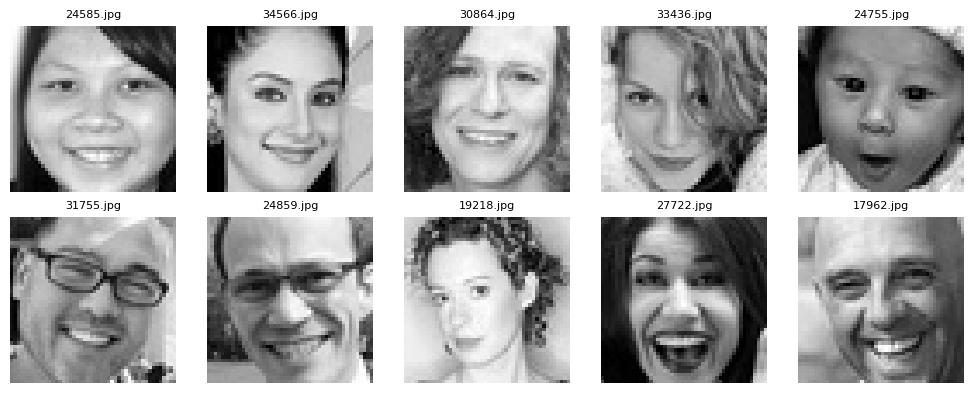

```python
happy_train_dir = "/content/Facial_emotion_images/train/happy"
display_10(happy_train_dir)
```

**Observations and Insights: Happy images**

- Lips may be curled upwards.
- Upper teeth may be showing.
- Cheek muscules curved upwards and outwards making some dimples observable.

### **Sad**

[figure not shown]

```python
sad_train_dir = "/content/Facial_emotion_images/train/sad"
display_10(sad_train_dir)
```

**Observations and Insights: Sad images**

- Sides of the lips curled downwards.
- Eyebrows slanted downwards towards the sides.

### **Neutral**

[figure not shown]

```python
neutral_train_dir = "/content/Facial_emotion_images/train/neutral"
display_10(neutral_train_dir)
```

**Observations and Insights: Neutral images**

- Lips are flat/straight.
- Eye brows in a neutral postion.

### **Surprised**

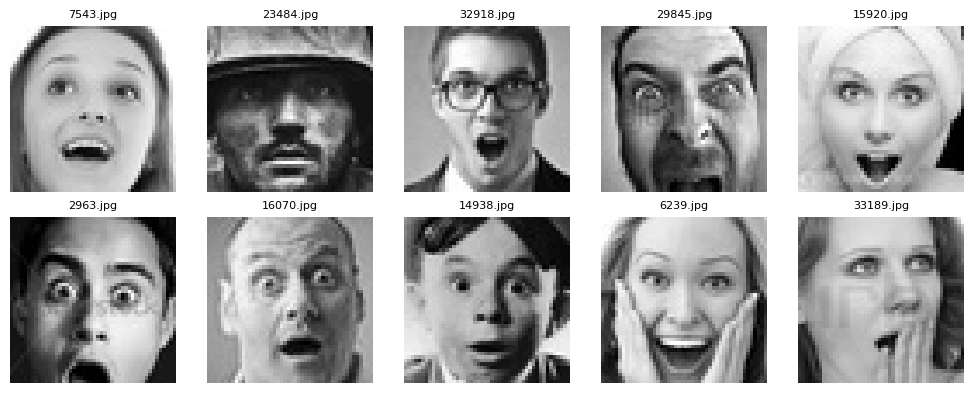

```python
surprise_train_dir = "/content/Facial_emotion_images/train/surprise"
display_10(surprise_train_dir)
```

**Observations and Insights: Surprised images**

- Dilated pupils and eyes open wide.
- Mouth is open.

## **Checking Distribution of Classes**

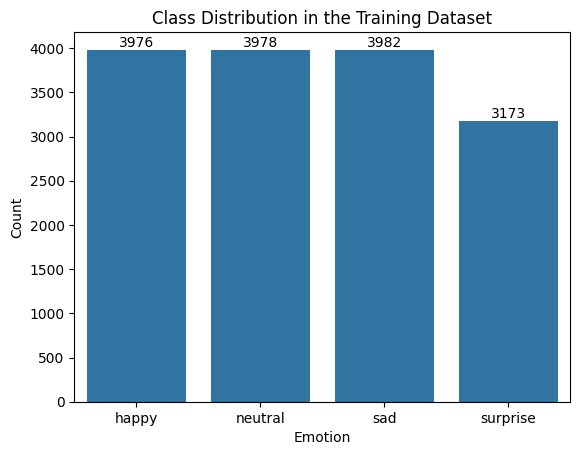

```python
import os
train_dir = "/content/Facial_emotion_images/train"

# Initialize lists to store images and labels
images_list = []
labels_list = []

# Get a list of all the emotion (class) subdirectories
emotion_classes = sorted(os.listdir(train_dir))

# Loop through each emotion class directory
for emotion_label, emotion in enumerate(emotion_classes):
    class_path = os.path.join(train_dir, emotion)

    # Get a list of all image file names in the current class directory
    image_filenames = os.listdir(class_path)

    # Loop through each image file
    for filename in image_filenames:
        image_path = os.path.join(class_path, filename)

        # Read the image using matplotlib.image.imread
        try:
            img = mpimg.imread(image_path)

            # Append the NumPy array and label to your lists
            images_list.append(img)
            labels_list.append(emotion_label) # Use a numerical label

        except Exception as e:
            print(f"Could not read image at {image_path}. Error: {e}")

count_plot = sns.countplot(x=labels_list)
count_plot.set_xticklabels(emotion_classes)
count_plot.set_title('Class Distribution in the Training Dataset')
count_plot.set_xlabel('Emotion')
count_plot.set_ylabel('Count')

# Add the exact count on top of each bar
for container in count_plot.containers:
    count_plot.bar_label(container)
```

**Observations and Insights: Data Exploration**

- *What are some key patterns in the data?*

  Datasets are imbalanced. In the train dataset, 'Surprised' class has 3,173 images while the other 3 classes have close to 4,000 images each.

  An unbalanced dataset, where some emotions are overrepresented will cause the model to perform poorly on minority classes.

**Exploratory data analysis:**

1. Class imbalance - 'Surprised' has about 20% less samples than the other classes, this will have to be addressed.
2. Image Size - all images are 48 x 48 pixels
3. Color - all images are grayscale (1 channel only)
- *What does it mean for the problem formulation?*

  We'll address the class imbalance in 2 ways:
  - We'll generate class weights to give more weight to the 'Surprised' class which has ~20% less data.
  - We'll calculate F1 Score in addition to accuracy for the better performing models. Accuracy can be misleading in imbalanced datasets. The F1 score provides a more reliable measure of performance in these cases.
- *Are there any data treatments or pre-processing required?*
  - We'll use the dataset as is for determining a good model architecture; then perform data augmentation to try to boost the performance of the final model.

## **Creating our Data Loaders**

In this section, we are creating data loaders that we will use as inputs to our Neural Network.

```python
# Fixing the seed for random number generators
# Important: this has to be done before creating the datasets from the image directories because the train dataset is shuffled
import random
np.random.seed(42)
random.seed(42)
tf.random.set_seed(42)
```

```python
# define normalization function for pixel values

# convert pixel values from the 0–255 integer range to a 0-1 float range
def normalize_img(image, label):
    image = tf.cast(image, tf.float32) / 255.0 # cast int8 to float32
    return image, label
```

```python
# create dataloaders with image_dataset_from_directory

train_dataset = tf.keras.utils.image_dataset_from_directory(
    '/content/Facial_emotion_images/train/',
    image_size=(48, 48),    # image size
    batch_size=32,          # smaller batch size to escape local minima during training
    labels='inferred',      # Infers labels from subdirectories
    label_mode='categorical',
    color_mode='grayscale',
    shuffle=True            # Shuffle to reduce overfitting
)

# Store the class names in a separate variable
class_names = train_dataset.class_names

# Normalize the data
train_mapdataset = train_dataset.map(normalize_img) # returns a _MapDataset
```

```
Found 15109 files belonging to 4 classes.
```

[figure not shown]

```python
# Display a batch of images from train
plt.figure(figsize=(12, 8))
for images, labels in train_mapdataset.take(1): # Access the first batch of 32 images
    for i in range(15):
        ax = plt.subplot(3, 5, i + 1)

        # .numpy() to convert tf.Tensor to ndarray for Matplotlib
        # .squeeze() to remove last channel dimension (48, 48, 1) as imshow() expects (48, 48)
        # .squeeze removes all dimensions in the array's shape that have a size of 1
        plt.imshow(images[i].numpy().squeeze(), cmap='gray')

        # Convert the one-hot encoded label back to an integer index
        label_index = tf.argmax(labels[i]).numpy()

        # Use the integer index to get the class name
        plt.title(class_names[label_index])
        plt.axis("off")
plt.show()
```

```python
# load the validation and test datasets

val_dataset = tf.keras.utils.image_dataset_from_directory(
    '/content/Facial_emotion_images/validation/',
    image_size=(48, 48),
    batch_size=512,            # larger batch size for validation
    labels='inferred',
    label_mode='categorical',
    color_mode='grayscale',
    shuffle=False # Do NOT shuffle so we can extract labels consistently for F1 score
)

val_mapdataset = val_dataset.map(normalize_img)

test_dataset = tf.keras.utils.image_dataset_from_directory(
    '/content/Facial_emotion_images/test/',
    image_size=(48, 48),
    batch_size=128,           # larger batch size for test. There are 128 images in test.
    labels='inferred',
    label_mode='categorical',
    color_mode='grayscale',
    shuffle=False # Do NOT shuffle so we can extract labels consistently for F1 score
)

test_mapdataset = test_dataset.map(normalize_img)
```

```
Found 4977 files belonging to 4 classes.
Found 128 files belonging to 4 classes.
```

```python
# prepare another 3 RGB datasets and mapdatasets
train_dataset_rgb = tf.keras.utils.image_dataset_from_directory(
    '/content/Facial_emotion_images/train/',
    image_size=(48, 48),
    batch_size=32,          # small batch size for training
    labels='inferred',
    label_mode='categorical',
    color_mode='rgb',
    shuffle=True  # Shuffle to reduce overfitting
)

train_mapdataset_rgb = train_dataset_rgb.map(normalize_img) # returns a _MapDataset

val_dataset_rgb = tf.keras.utils.image_dataset_from_directory(
    '/content/Facial_emotion_images/validation/',
    image_size=(48, 48),
    batch_size=512,          # larger batch size for validation
    labels='inferred',
    label_mode='categorical',
    color_mode='rgb',
    shuffle=False # Do NOT shuffle so we can extract labels consistently for F1 score
)

val_mapdataset_rgb = val_dataset_rgb.map(normalize_img) # returns a _MapDataset

test_dataset_rgb = tf.keras.utils.image_dataset_from_directory(
    '/content/Facial_emotion_images/test/',
    image_size=(48, 48),
    batch_size=128,        # larger batch size for test
    labels='inferred',
    label_mode='categorical',
    color_mode='rgb',
    shuffle=False # Do NOT shuffle so we can extract labels consistently for F1 score
)

test_mapdataset_rgb = test_dataset_rgb.map(normalize_img)
```

```
Found 15109 files belonging to 4 classes.
Found 4977 files belonging to 4 classes.
Found 128 files belonging to 4 classes.
```

```python
# address the imblanced dataset by preparing class weights for model.fit()
# class weights are only needed for the train dataset

from sklearn.utils.class_weight import compute_class_weight

all_labels = np.array(labels_list)

class_weights = compute_class_weight(
    'balanced',
    classes=np.unique(all_labels),
    y=all_labels
)

# class_weights is a numpy array but Tensorflow requires a dictionary
class_weights_dict = {i: weight for i, weight in enumerate(class_weights)}

print("Class Weights:")
for i, weight in class_weights_dict.items():
    print(f"- {class_names[i]}: {weight:.3f}")
```

```
Class Weights:
- happy: 0.950
- neutral: 0.950
- sad: 0.949
- surprise: 1.190
```

## **Model Building**

### **Creating the Base Neural Network**

### **Train a ANN as a benchmark**

```python
# Keras Sequential Model
from keras.models import Sequential

# Importing all the different layers and optimizers
from keras.layers import Dense, Dropout, Flatten, Conv2D, MaxPooling2D, BatchNormalization, Activation, LeakyReLU
from keras.optimizers import Adam
```

```python
# Prepare a ANN as a benchmark
nn_model = Sequential([
    Flatten(input_shape=(48, 48, 1)), # convert (48, 48, 1) to 48 * 48 * 1 = (2304, )
    Dense(64, activation='relu'),
    Dense(32, activation='relu'),
    Dense(4, activation='softmax') # output nodes = number of classes
], name="nn_model")

opt = Adam(learning_rate=0.001)

nn_model.compile(
    optimizer=opt,
    loss='categorical_crossentropy',
    metrics=['accuracy']
)

nn_model.summary()
```

```
Model: "nn_model"
```

```
┏━━━━━━━━━━━━━━━━━━━━━━━━━━━━━━━━━┳━━━━━━━━━━━━━━━━━━━━━━━━┳━━━━━━━━━━━━━━━┓
┃ Layer (type)                    ┃ Output Shape           ┃       Param # ┃
┡━━━━━━━━━━━━━━━━━━━━━━━━━━━━━━━━━╇━━━━━━━━━━━━━━━━━━━━━━━━╇━━━━━━━━━━━━━━━┩
│ flatten_2 (Flatten)             │ (None, 2304)           │             0 │
├─────────────────────────────────┼────────────────────────┼───────────────┤
│ dense_5 (Dense)                 │ (None, 64)             │       147,520 │
├─────────────────────────────────┼────────────────────────┼───────────────┤
│ dense_6 (Dense)                 │ (None, 32)             │         2,080 │
├─────────────────────────────────┼────────────────────────┼───────────────┤
│ dense_7 (Dense)                 │ (None, 4)              │           132 │
└─────────────────────────────────┴────────────────────────┴───────────────┘
```

```
 Total params: 149,732 (584.89 KB)
```

```
 Trainable params: 149,732 (584.89 KB)
```

```
 Non-trainable params: 0 (0.00 B)
```

```python
# batch_size and shuffle=True already set when tf.data.Dataset was created
history_nn_model = nn_model.fit(
    train_mapdataset, # Use the normalized map dataset
    epochs=20,
    class_weight=class_weights_dict,
    validation_data=val_mapdataset, # Use the normalized map dataset
    verbose=1
)
```

```
473/473 ━━━━━━━━━━━━━━━━━━━━ 6s 9ms/step - accuracy: 0.3165 - loss: 1.3710 - val_accuracy: 0.4525 - val_loss: 1.2195
473/473 ━━━━━━━━━━━━━━━━━━━━ 3s 6ms/step - accuracy: 0.4223 - loss: 1.2422 - val_accuracy: 0.3382 - val_loss: 1.3817
473/473 ━━━━━━━━━━━━━━━━━━━━ 3s 6ms/step - accuracy: 0.4478 - loss: 1.2106 - val_accuracy: 0.4448 - val_loss: 1.2217
473/473 ━━━━━━━━━━━━━━━━━━━━ 5s 10ms/step - accuracy: 0.4559 - loss: 1.1918 - val_accuracy: 0.4716 - val_loss: 1.1887
473/473 ━━━━━━━━━━━━━━━━━━━━ 3s 6ms/step - accuracy: 0.4732 - loss: 1.1668 - val_accuracy: 0.5162 - val_loss: 1.1361
473/473 ━━━━━━━━━━━━━━━━━━━━ 3s 6ms/step - accuracy: 0.4849 - loss: 1.1552 - val_accuracy: 0.5180 - val_loss: 1.1207
473/473 ━━━━━━━━━━━━━━━━━━━━ 3s 6ms/step - accuracy: 0.4801 - loss: 1.1542 - val_accuracy: 0.5077 - val_loss: 1.1348
473/473 ━━━━━━━━━━━━━━━━━━━━ 4s 9ms/step - accuracy: 0.4867 - loss: 1.1424 - val_accuracy: 0.4450 - val_loss: 1.2217
473/473 ━━━━━━━━━━━━━━━━━━━━ 3s 6ms/step - accuracy: 0.4901 - loss: 1.1283 - val_accuracy: 0.4999 - val_loss: 1.1402
473/473 ━━━━━━━━━━━━━━━━━━━━ 3s 6ms/step - accuracy: 0.5055 - loss: 1.1194 - val_accuracy: 0.4527 - val_loss: 1.2163
473/473 ━━━━━━━━━━━━━━━━━━━━ 3s 6ms/step - accuracy: 0.5026 - loss: 1.1144 - val_accuracy: 0.4497 - val_loss: 1.2345
473/473 ━━━━━━━━━━━━━━━━━━━━ 4s 7ms/step - accuracy: 0.5018 - loss: 1.1122 - val_accuracy: 0.5140 - val_loss: 1.1077
473/473 ━━━━━━━━━━━━━━━━━━━━ 4s 7ms/step - accuracy: 0.5193 - loss: 1.0952 - val_accuracy: 0.5007 - val_loss: 1.1314
473/473 ━━━━━━━━━━━━━━━━━━━━ 3s 6ms/step - accuracy: 0.5087 - loss: 1.0999 - val_accuracy: 0.4981 - val_loss: 1.1534
473/473 ━━━━━━━━━━━━━━━━━━━━ 3s 6ms/step - accuracy: 0.5182 - loss: 1.0923 - val_accuracy: 0.5120 - val_loss: 1.1182
473/473 ━━━━━━━━━━━━━━━━━━━━ 3s 7ms/step - accuracy: 0.5119 - loss: 1.0885 - val_accuracy: 0.5182 - val_loss: 1.0981
473/473 ━━━━━━━━━━━━━━━━━━━━ 4s 8ms/step - accuracy: 0.5179 - loss: 1.0833 - val_accuracy: 0.5204 - val_loss: 1.0982
473/473 ━━━━━━━━━━━━━━━━━━━━ 3s 6ms/step - accuracy: 0.5176 - loss: 1.0830 - val_accuracy: 0.5228 - val_loss: 1.0995
473/473 ━━━━━━━━━━━━━━━━━━━━ 3s 6ms/step - accuracy: 0.5294 - loss: 1.0756 - val_accuracy: 0.4732 - val_loss: 1.2084
473/473 ━━━━━━━━━━━━━━━━━━━━ 6s 9ms/step - accuracy: 0.5254 - loss: 1.0663 - val_accuracy: 0.5128 - val_loss: 1.1238
```

```python
# Evaluating the model on the test data
test_loss, test_accuracy = nn_model.evaluate(test_mapdataset, verbose=2)
print(f"Test Loss: {test_loss:.4f}")
print(f"Test Accuracy: {test_accuracy:.4f}")
```

```
1/1 - 0s - 292ms/step - accuracy: 0.5234 - loss: 1.0779
Test Loss: 1.0779
Test Accuracy: 0.5234
```

```python
# Test inference time. No batching.
import time

def get_inference_time(keras_model, mapdataset):

  for test_batch in mapdataset:
      images, labels = test_batch  # we just want the images
      break # Exit after getting the first batch (we only have 1 batch in TEST)

  batch_size = images.shape[0] # 128

  # Warm up by predicting 5 times on the first image
  first_image = np.expand_dims(images[0], axis=0) # expand dimensions to include a batch size of 1
  for _ in range(5):
      keras_model.predict(first_image, verbose=0)

  inference_times = []

  print(f"Starting sequential unbatched inference on {batch_size} images with {keras_model.name}")

  # Loop through each image in the batch
  for i in range(batch_size):
      # Expand dimensions for the single image to create a batch of 1
      single_image_batch = np.expand_dims(images[i], axis=0)

      # Time the prediction for this single image
      start_time = time.time()
      keras_model.predict(single_image_batch, verbose=0)
      end_time = time.time()

      inference_times.append(end_time - start_time)

  # Calculate the mean inference time
  mean_inference_time_s = np.mean(inference_times)
  mean_inference_time_ms = mean_inference_time_s * 1000

  print("-" * 60)
  print(f"Mean inference time per image: {mean_inference_time_ms:.2f} ms")
```

```python
get_inference_time(nn_model, test_mapdataset)
```

```
Starting sequential unbatched inference on 128 images with nn_model
--------------------------------------------------
Mean inference time per image: 65.40 ms
```

| Model Name | Accuracy (train) | Train Loss | Accuracy (val) | Val Loss | Accuracy (test) | Test Loss |
| --- | --- | --- | --- | --- | --- | --- |
| nn_model | 52.54% | 1.0663 | 51.28% | 1.1238 | 52.34% | 1.0779 |

The accuracy of the ANN is very low at `52.54%` on training data. On validation data its accuracy is `51.28%`.

On test data, accuracy is `52.34%`.

ANNs, treat every pixel as an independent feature, which leads to computational inefficiencies and a loss of crucial information about the relationship between neighboring pixels.

CNNs use a convolutional layer that applies filters (or kernels) that slide over the input image, preserving its 2D structure. This process detects patterns like edges, shapes, and textures based on the relationship between neighboring pixels.

We'll move on to using CNNs.

### **Compiling and Training the Model**

```python
# Clearing backend
from keras import backend
backend.clear_session()

# Reset the random seed
import random
np.random.seed(42)
random.seed(42)
tf.random.set_seed(42)
```

```python
# Placing BatchNormalization before the activation function to bring the inputs closer to zero to avoid saturation

cnn_model_1 = Sequential([

    # 1st convolutional layer: 16 filters and kernel size 3x3
    Conv2D(16, (3, 3), padding="same", input_shape=(48, 48, 1)),
    BatchNormalization(),
    LeakyReLU(alpha=0.1),

    # 2nd Conv2D layer with 32 filters and kernel size 3x3
    Conv2D(32, (3, 3), padding="same"),
    BatchNormalization(),
    LeakyReLU(alpha=0.1),

    # MaxPooling2D layer with pool size 2x2
    MaxPooling2D(pool_size=(2, 2)),
    Dropout(0.25), # regularization to prevent overfitting

    # Flatten output of the conv layers to ready it for dense connections
    Flatten(),

    Dense(32),
    BatchNormalization(),
    LeakyReLU(alpha=0.1),
    Dropout(0.5), # regularization to prevent overfitting

    Dense(4, activation='softmax')
], name="cnn_model_1")

opt = Adam(learning_rate=0.001)

cnn_model_1.compile(
    optimizer=opt,
    loss='categorical_crossentropy',
    metrics=['accuracy']
)

cnn_model_1.summary()
```

```
Model: "cnn_model_1"
```

```
┏━━━━━━━━━━━━━━━━━━━━━━━━━━━━━━━━━┳━━━━━━━━━━━━━━━━━━━━━━━━┳━━━━━━━━━━━━━━━┓
┃ Layer (type)                    ┃ Output Shape           ┃       Param # ┃
┡━━━━━━━━━━━━━━━━━━━━━━━━━━━━━━━━━╇━━━━━━━━━━━━━━━━━━━━━━━━╇━━━━━━━━━━━━━━━┩
│ conv2d (Conv2D)                 │ (None, 48, 48, 16)     │           160 │
├─────────────────────────────────┼────────────────────────┼───────────────┤
│ batch_normalization             │ (None, 48, 48, 16)     │            64 │
│ (BatchNormalization)            │                        │               │
├─────────────────────────────────┼────────────────────────┼───────────────┤
│ leaky_re_lu (LeakyReLU)         │ (None, 48, 48, 16)     │             0 │
├─────────────────────────────────┼────────────────────────┼───────────────┤
│ conv2d_1 (Conv2D)               │ (None, 48, 48, 32)     │         4,640 │
├─────────────────────────────────┼────────────────────────┼───────────────┤
│ batch_normalization_1           │ (None, 48, 48, 32)     │           128 │
│ (BatchNormalization)            │                        │               │
├─────────────────────────────────┼────────────────────────┼───────────────┤
│ leaky_re_lu_1 (LeakyReLU)       │ (None, 48, 48, 32)     │             0 │
├─────────────────────────────────┼────────────────────────┼───────────────┤
│ max_pooling2d (MaxPooling2D)    │ (None, 24, 24, 32)     │             0 │
├─────────────────────────────────┼────────────────────────┼───────────────┤
│ dropout (Dropout)               │ (None, 24, 24, 32)     │             0 │
├─────────────────────────────────┼────────────────────────┼───────────────┤
│ flatten (Flatten)               │ (None, 18432)          │             0 │
├─────────────────────────────────┼────────────────────────┼───────────────┤
│ dense (Dense)                   │ (None, 32)             │       589,856 │
├─────────────────────────────────┼────────────────────────┼───────────────┤
│ batch_normalization_2           │ (None, 32)             │           128 │
│ (BatchNormalization)            │                        │               │
├─────────────────────────────────┼────────────────────────┼───────────────┤
│ leaky_re_lu_2 (LeakyReLU)       │ (None, 32)             │             0 │
├─────────────────────────────────┼────────────────────────┼───────────────┤
│ dropout_1 (Dropout)             │ (None, 32)             │             0 │
├─────────────────────────────────┼────────────────────────┼───────────────┤
│ dense_1 (Dense)                 │ (None, 4)              │           132 │
└─────────────────────────────────┴────────────────────────┴───────────────┘
```

```
 Total params: 595,108 (2.27 MB)
```

```
 Trainable params: 594,948 (2.27 MB)
```

```
 Non-trainable params: 160 (640.00 B)
```

```python
history_cnn_model_1 = cnn_model_1.fit(
    train_mapdataset, # Use the normalized map dataset
    epochs=20,
    class_weight=class_weights_dict,
    validation_data=val_mapdataset, # Use the normalized map dataset
    verbose=1
)
```

```
473/473 ━━━━━━━━━━━━━━━━━━━━ 29s 37ms/step - accuracy: 0.4169 - loss: 1.3632 - val_accuracy: 0.4792 - val_loss: 1.1447
473/473 ━━━━━━━━━━━━━━━━━━━━ 7s 14ms/step - accuracy: 0.5694 - loss: 1.0044 - val_accuracy: 0.5887 - val_loss: 0.9863
473/473 ━━━━━━━━━━━━━━━━━━━━ 11s 22ms/step - accuracy: 0.6122 - loss: 0.9088 - val_accuracy: 0.6112 - val_loss: 0.9262
473/473 ━━━━━━━━━━━━━━━━━━━━ 5s 10ms/step - accuracy: 0.6368 - loss: 0.8547 - val_accuracy: 0.6375 - val_loss: 0.8794
473/473 ━━━━━━━━━━━━━━━━━━━━ 7s 15ms/step - accuracy: 0.6496 - loss: 0.8115 - val_accuracy: 0.6478 - val_loss: 0.8597
473/473 ━━━━━━━━━━━━━━━━━━━━ 6s 12ms/step - accuracy: 0.6759 - loss: 0.7679 - val_accuracy: 0.5821 - val_loss: 0.9981
473/473 ━━━━━━━━━━━━━━━━━━━━ 4s 8ms/step - accuracy: 0.6889 - loss: 0.7254 - val_accuracy: 0.6239 - val_loss: 0.9137
473/473 ━━━━━━━━━━━━━━━━━━━━ 5s 11ms/step - accuracy: 0.7014 - loss: 0.7081 - val_accuracy: 0.6399 - val_loss: 0.8789
473/473 ━━━━━━━━━━━━━━━━━━━━ 7s 14ms/step - accuracy: 0.7200 - loss: 0.6649 - val_accuracy: 0.6414 - val_loss: 0.8655
473/473 ━━━━━━━━━━━━━━━━━━━━ 9s 18ms/step - accuracy: 0.7399 - loss: 0.6263 - val_accuracy: 0.6428 - val_loss: 0.9328
473/473 ━━━━━━━━━━━━━━━━━━━━ 6s 13ms/step - accuracy: 0.7544 - loss: 0.5979 - val_accuracy: 0.6347 - val_loss: 0.9247
473/473 ━━━━━━━━━━━━━━━━━━━━ 9s 19ms/step - accuracy: 0.7494 - loss: 0.5981 - val_accuracy: 0.6287 - val_loss: 0.9329
473/473 ━━━━━━━━━━━━━━━━━━━━ 8s 15ms/step - accuracy: 0.7719 - loss: 0.5514 - val_accuracy: 0.6347 - val_loss: 0.9405
473/473 ━━━━━━━━━━━━━━━━━━━━ 7s 14ms/step - accuracy: 0.7864 - loss: 0.5232 - val_accuracy: 0.6416 - val_loss: 0.9805
473/473 ━━━━━━━━━━━━━━━━━━━━ 9s 19ms/step - accuracy: 0.7953 - loss: 0.4906 - val_accuracy: 0.6088 - val_loss: 1.0207
473/473 ━━━━━━━━━━━━━━━━━━━━ 6s 13ms/step - accuracy: 0.7907 - loss: 0.5011 - val_accuracy: 0.6403 - val_loss: 0.9930
473/473 ━━━━━━━━━━━━━━━━━━━━ 9s 18ms/step - accuracy: 0.8051 - loss: 0.4695 - val_accuracy: 0.6393 - val_loss: 0.9971
473/473 ━━━━━━━━━━━━━━━━━━━━ 3s 7ms/step - accuracy: 0.8174 - loss: 0.4462 - val_accuracy: 0.6383 - val_loss: 1.0183
473/473 ━━━━━━━━━━━━━━━━━━━━ 3s 7ms/step - accuracy: 0.8246 - loss: 0.4179 - val_accuracy: 0.6452 - val_loss: 1.0618
473/473 ━━━━━━━━━━━━━━━━━━━━ 5s 9ms/step - accuracy: 0.8285 - loss: 0.4169 - val_accuracy: 0.6357 - val_loss: 1.0362
```

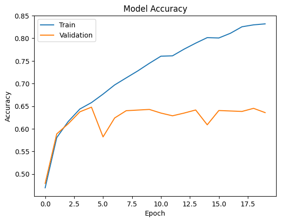

```python
# Model training evaluation
plt.plot(history_cnn_model_1.history['accuracy'])
plt.plot(history_cnn_model_1.history['val_accuracy'])
plt.title('Model Accuracy')
plt.ylabel('Accuracy')
plt.xlabel('Epoch')
plt.legend(['Train', 'Validation'], loc='upper left')
plt.show()
```

### **Evaluating the Model on the Test Set**

```python
# Evaluating the model on the test data
test_loss, test_accuracy = cnn_model_1.evaluate(test_mapdataset, verbose=2)
print(f"Test Loss: {test_loss:.4f}")
print(f"Test Accuracy: {test_accuracy:.4f}")
```

```
1/1 - 0s - 426ms/step - accuracy: 0.6719 - loss: 0.8933
Test Loss: 0.8933
Test Accuracy: 0.6719
```

**Observations and Insights:**

| Model Name | Accuracy (train) | Train Loss | Accuracy (val) | Val Loss | Accuracy (test) | Test Loss |
| --- | --- | --- | --- | --- | --- | --- |
| nn_model | 52.54% | 1.0663 | 51.28% | 1.1238 | 52.34% | 1.0779 |
| cnn_model_1 | 82.85% | 0.4169 | 63.57% | 1.0362 | 67.19% | 0.8933 |

The `cnn_model_1` is massively overfitting the training data at `82.85%` accuracy on train but only `63.57%` on validation data.

Accuracy is `67.19%` on test data.

We'll try to more aggressively reduce overfitting in `cnn_model_2`.

### **Creating the second Convolutional Neural Network**

- Try out a slightly larger architecture

We're going to try to deal with the overfitting more aggressively in this model by introducing He intialization and L2 regularization.

- L2 regularization directly penalizes large weights to simplify the model
- He initialization provides a better starting point for the training process, which makes the subsequent optimization more effective at finding an optimal, generalizable solution

```python
# Clearing backend
from keras import backend
backend.clear_session()

# Reset the random seed
import random
np.random.seed(42)
random.seed(42)
tf.random.set_seed(42)
```

```python
from keras.initializers import HeNormal
from keras.regularizers import l2

# Instantiate the HeNormal initializer
he_normal_init = HeNormal()
reg_strength = 0.0001

cnn_model_2 = Sequential([
    # 1st convolutional layer: 16 filters and kernel size 3x3
    Conv2D(16, (3, 3), padding="same", input_shape=(48, 48, 1),
           kernel_initializer=he_normal_init,
           kernel_regularizer=l2(reg_strength)),
    BatchNormalization(),
    LeakyReLU(alpha=0.1),

    # 2nd convolutional layer: 32 filters and kernel size 3x3
    Conv2D(32, (3, 3), padding="same",
           kernel_initializer=he_normal_init,
           kernel_regularizer=l2(reg_strength)),
    BatchNormalization(),
    LeakyReLU(alpha=0.1),

    # Slide 2x2 filter and only pass the largest value
    MaxPooling2D(pool_size=(2, 2)),
    Dropout(0.25), # regularization to prevent overfitting

    # More convolutional layers allows the network to learn more complex and hierarchical features from the image data
    # 3rd convolutional layer: 32 filters and kernel size 3x3
    Conv2D(32, (3, 3), padding="same",
           kernel_initializer=he_normal_init,
           kernel_regularizer=l2(reg_strength)),
    BatchNormalization(),
    LeakyReLU(alpha=0.1),

    # 4th convolutional layer: 64 filters and kernel size 3x3
    Conv2D(64, (3, 3), padding="same",
           kernel_initializer=he_normal_init,
           kernel_regularizer=l2(reg_strength)),
    BatchNormalization(),
    LeakyReLU(alpha=0.1),

    # 2nd MaxPooling layer. Cuts down trainable parameters
    MaxPooling2D(pool_size=(2, 2)),
    Dropout(0.25), # regularization to prevent overfitting

    Flatten(),

    Dense(32,
          kernel_initializer=he_normal_init,
          kernel_regularizer=l2(reg_strength)),
    BatchNormalization(),
    LeakyReLU(alpha=0.1),
    Dropout(0.5), # regularization to prevent overfitting

    Dense(4, activation='softmax', kernel_initializer=he_normal_init)
], name="cnn_model_2")


opt = Adam(learning_rate=0.001)

cnn_model_2.compile(
    optimizer=opt,
    loss='categorical_crossentropy',
    metrics=['accuracy']
)

cnn_model_2.summary()
```

```
Model: "cnn_model_2"
```

```
┏━━━━━━━━━━━━━━━━━━━━━━━━━━━━━━━━━┳━━━━━━━━━━━━━━━━━━━━━━━━┳━━━━━━━━━━━━━━━┓
┃ Layer (type)                    ┃ Output Shape           ┃       Param # ┃
┡━━━━━━━━━━━━━━━━━━━━━━━━━━━━━━━━━╇━━━━━━━━━━━━━━━━━━━━━━━━╇━━━━━━━━━━━━━━━┩
│ conv2d (Conv2D)                 │ (None, 48, 48, 16)     │           160 │
├─────────────────────────────────┼────────────────────────┼───────────────┤
│ batch_normalization             │ (None, 48, 48, 16)     │            64 │
│ (BatchNormalization)            │                        │               │
├─────────────────────────────────┼────────────────────────┼───────────────┤
│ leaky_re_lu (LeakyReLU)         │ (None, 48, 48, 16)     │             0 │
├─────────────────────────────────┼────────────────────────┼───────────────┤
│ conv2d_1 (Conv2D)               │ (None, 48, 48, 32)     │         4,640 │
├─────────────────────────────────┼────────────────────────┼───────────────┤
│ batch_normalization_1           │ (None, 48, 48, 32)     │           128 │
│ (BatchNormalization)            │                        │               │
├─────────────────────────────────┼────────────────────────┼───────────────┤
│ leaky_re_lu_1 (LeakyReLU)       │ (None, 48, 48, 32)     │             0 │
├─────────────────────────────────┼────────────────────────┼───────────────┤
│ max_pooling2d (MaxPooling2D)    │ (None, 24, 24, 32)     │             0 │
├─────────────────────────────────┼────────────────────────┼───────────────┤
│ dropout (Dropout)               │ (None, 24, 24, 32)     │             0 │
├─────────────────────────────────┼────────────────────────┼───────────────┤
│ conv2d_2 (Conv2D)               │ (None, 24, 24, 32)     │         9,248 │
├─────────────────────────────────┼────────────────────────┼───────────────┤
│ batch_normalization_2           │ (None, 24, 24, 32)     │           128 │
│ (BatchNormalization)            │                        │               │
├─────────────────────────────────┼────────────────────────┼───────────────┤
│ leaky_re_lu_2 (LeakyReLU)       │ (None, 24, 24, 32)     │             0 │
├─────────────────────────────────┼────────────────────────┼───────────────┤
│ conv2d_3 (Conv2D)               │ (None, 24, 24, 64)     │        18,496 │
├─────────────────────────────────┼────────────────────────┼───────────────┤
│ batch_normalization_3           │ (None, 24, 24, 64)     │           256 │
│ (BatchNormalization)            │                        │               │
├─────────────────────────────────┼────────────────────────┼───────────────┤
│ leaky_re_lu_3 (LeakyReLU)       │ (None, 24, 24, 64)     │             0 │
├─────────────────────────────────┼────────────────────────┼───────────────┤
│ max_pooling2d_1 (MaxPooling2D)  │ (None, 12, 12, 64)     │             0 │
├─────────────────────────────────┼────────────────────────┼───────────────┤
│ dropout_1 (Dropout)             │ (None, 12, 12, 64)     │             0 │
├─────────────────────────────────┼────────────────────────┼───────────────┤
│ flatten (Flatten)               │ (None, 9216)           │             0 │
├─────────────────────────────────┼────────────────────────┼───────────────┤
│ dense (Dense)                   │ (None, 32)             │       294,944 │
├─────────────────────────────────┼────────────────────────┼───────────────┤
│ batch_normalization_4           │ (None, 32)             │           128 │
│ (BatchNormalization)            │                        │               │
├─────────────────────────────────┼────────────────────────┼───────────────┤
│ leaky_re_lu_4 (LeakyReLU)       │ (None, 32)             │             0 │
├─────────────────────────────────┼────────────────────────┼───────────────┤
│ dropout_2 (Dropout)             │ (None, 32)             │             0 │
├─────────────────────────────────┼────────────────────────┼───────────────┤
│ dense_1 (Dense)                 │ (None, 4)              │           132 │
└─────────────────────────────────┴────────────────────────┴───────────────┘
```

```
 Total params: 328,324 (1.25 MB)
```

```
 Trainable params: 327,972 (1.25 MB)
```

```
 Non-trainable params: 352 (1.38 KB)
```

### **Compiling and Training the Model**

```python
history_cnn_model_2 = cnn_model_2.fit(
    train_mapdataset, # Use the normalized map dataset
    epochs=20,
    class_weight=class_weights_dict,
    validation_data=val_mapdataset, # Use the normalized map dataset
    verbose=1
)
```

```
473/473 ━━━━━━━━━━━━━━━━━━━━ 24s 30ms/step - accuracy: 0.3959 - loss: 1.5145 - val_accuracy: 0.5489 - val_loss: 1.0800
473/473 ━━━━━━━━━━━━━━━━━━━━ 4s 8ms/step - accuracy: 0.5571 - loss: 1.0828 - val_accuracy: 0.6369 - val_loss: 0.9270
473/473 ━━━━━━━━━━━━━━━━━━━━ 4s 9ms/step - accuracy: 0.6079 - loss: 0.9780 - val_accuracy: 0.6606 - val_loss: 0.8815
473/473 ━━━━━━━━━━━━━━━━━━━━ 5s 11ms/step - accuracy: 0.6237 - loss: 0.9339 - val_accuracy: 0.6763 - val_loss: 0.8499
473/473 ━━━━━━━━━━━━━━━━━━━━ 4s 9ms/step - accuracy: 0.6358 - loss: 0.8995 - val_accuracy: 0.6839 - val_loss: 0.8368
473/473 ━━━━━━━━━━━━━━━━━━━━ 4s 8ms/step - accuracy: 0.6468 - loss: 0.8894 - val_accuracy: 0.6952 - val_loss: 0.8150
473/473 ━━━━━━━━━━━━━━━━━━━━ 5s 11ms/step - accuracy: 0.6591 - loss: 0.8701 - val_accuracy: 0.6962 - val_loss: 0.8278
473/473 ━━━━━━━━━━━━━━━━━━━━ 4s 8ms/step - accuracy: 0.6775 - loss: 0.8388 - val_accuracy: 0.7071 - val_loss: 0.8198
473/473 ━━━━━━━━━━━━━━━━━━━━ 4s 8ms/step - accuracy: 0.6873 - loss: 0.8286 - val_accuracy: 0.6775 - val_loss: 0.8701
473/473 ━━━━━━━━━━━━━━━━━━━━ 5s 11ms/step - accuracy: 0.7001 - loss: 0.7973 - val_accuracy: 0.6862 - val_loss: 0.8906
473/473 ━━━━━━━━━━━━━━━━━━━━ 4s 8ms/step - accuracy: 0.7104 - loss: 0.7893 - val_accuracy: 0.7040 - val_loss: 0.8434
473/473 ━━━━━━━━━━━━━━━━━━━━ 6s 11ms/step - accuracy: 0.7167 - loss: 0.7799 - val_accuracy: 0.6508 - val_loss: 0.9339
473/473 ━━━━━━━━━━━━━━━━━━━━ 7s 14ms/step - accuracy: 0.7235 - loss: 0.7629 - val_accuracy: 0.7119 - val_loss: 0.8520
473/473 ━━━━━━━━━━━━━━━━━━━━ 4s 8ms/step - accuracy: 0.7306 - loss: 0.7706 - val_accuracy: 0.6934 - val_loss: 0.8697
473/473 ━━━━━━━━━━━━━━━━━━━━ 5s 10ms/step - accuracy: 0.7370 - loss: 0.7590 - val_accuracy: 0.7183 - val_loss: 0.8432
473/473 ━━━━━━━━━━━━━━━━━━━━ 4s 9ms/step - accuracy: 0.7499 - loss: 0.7334 - val_accuracy: 0.7231 - val_loss: 0.8416
473/473 ━━━━━━━━━━━━━━━━━━━━ 4s 8ms/step - accuracy: 0.7627 - loss: 0.7250 - val_accuracy: 0.7213 - val_loss: 0.8579
473/473 ━━━━━━━━━━━━━━━━━━━━ 4s 9ms/step - accuracy: 0.7487 - loss: 0.7394 - val_accuracy: 0.7290 - val_loss: 0.8729
473/473 ━━━━━━━━━━━━━━━━━━━━ 5s 9ms/step - accuracy: 0.7551 - loss: 0.7325 - val_accuracy: 0.7155 - val_loss: 0.8832
473/473 ━━━━━━━━━━━━━━━━━━━━ 4s 8ms/step - accuracy: 0.7738 - loss: 0.6935 - val_accuracy: 0.6928 - val_loss: 0.9463
```

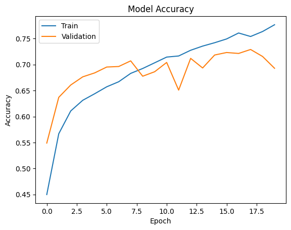

```python
# Model training evaluation
plt.plot(history_cnn_model_2.history['accuracy'])
plt.plot(history_cnn_model_2.history['val_accuracy'])
plt.title('Model Accuracy')
plt.ylabel('Accuracy')
plt.xlabel('Epoch')
plt.legend(['Train', 'Validation'], loc='upper left')
plt.show()
```

### **Evaluating the Model on the Test Set**

```python
# Evaluating the model on the test data
test_loss, test_accuracy = cnn_model_2.evaluate(test_mapdataset, verbose=2)
print(f"Test Loss: {test_loss:.4f}")
print(f"Test Accuracy: {test_accuracy:.4f}")
```

```
1/1 - 1s - 712ms/step - accuracy: 0.7109 - loss: 0.8611
Test Loss: 0.8611
Test Accuracy: 0.7109
```

**Observations and Insights:**

[output not shown]

`cnn_model_2` is performing much better. There's still some overfitting as we're able to achieve `77.38%` accuracy on the training data but accuracy on validation seems to plateau; we ended training at `69.28%` validation accuracy.

This new model performs much more satisfactorily on test data (`71.09%`) than `cnn_model_1`.

### **Train and Evaluate an RGB version of the model**

```python
# Clearing backend
from keras import backend
backend.clear_session()

# Reset the random seed
import random
np.random.seed(42)
random.seed(42)
tf.random.set_seed(42)
```

```python
# train an RGB version of the model

from keras.initializers import HeNormal
from keras.regularizers import l2

he_normal_init = HeNormal()
reg_strength = 0.0001

cnn_model_2_rgb = Sequential([

    # 1st convolutional layer: 16 filters and kernel size 3x3
    Conv2D(16, (3, 3), padding="same", input_shape=(48, 48, 3), # 3 channels for RGB
           kernel_initializer=he_normal_init,
           kernel_regularizer=l2(reg_strength)),
    BatchNormalization(),
    LeakyReLU(alpha=0.1),

    # 2nd convolutional layer: 32 filters and kernel size 3x3
    Conv2D(32, (3, 3), padding="same",
           kernel_initializer=he_normal_init,
           kernel_regularizer=l2(reg_strength)),
    BatchNormalization(),
    LeakyReLU(alpha=0.1),

    # 1st MaxPooling layer
    MaxPooling2D(pool_size=(2, 2)),
    Dropout(0.25),

    # 3rd convolutional layer: 32 filters and kernel size 3x3
    Conv2D(32, (3, 3), padding="same",
           kernel_initializer=he_normal_init,
           kernel_regularizer=l2(reg_strength)),
    BatchNormalization(),
    LeakyReLU(alpha=0.1),

    # 4th convolutional layer: 64 filters and kernel size 3x3
    Conv2D(64, (3, 3), padding="same",
           kernel_initializer=he_normal_init,
           kernel_regularizer=l2(reg_strength)),
    BatchNormalization(),
    LeakyReLU(alpha=0.1),

    # 2nd MaxPooling layer. Cuts down trainable parameters
    MaxPooling2D(pool_size=(2, 2)),
    Dropout(0.25),

    Flatten(),

    Dense(32,
          kernel_initializer=he_normal_init,
          kernel_regularizer=l2(reg_strength)),
    BatchNormalization(),
    LeakyReLU(alpha=0.1),
    Dropout(0.5),

    Dense(4, activation='softmax', kernel_initializer=he_normal_init)
], name="cnn_model_2_rgb")


opt = Adam(learning_rate=0.001)

cnn_model_2_rgb.compile(
    optimizer=opt,
    loss='categorical_crossentropy',
    metrics=['accuracy']
)

cnn_model_2_rgb.summary()
```

```
Model: "cnn_model_2_rgb"
```

```
┏━━━━━━━━━━━━━━━━━━━━━━━━━━━━━━━━━┳━━━━━━━━━━━━━━━━━━━━━━━━┳━━━━━━━━━━━━━━━┓
┃ Layer (type)                    ┃ Output Shape           ┃       Param # ┃
┡━━━━━━━━━━━━━━━━━━━━━━━━━━━━━━━━━╇━━━━━━━━━━━━━━━━━━━━━━━━╇━━━━━━━━━━━━━━━┩
│ conv2d (Conv2D)                 │ (None, 48, 48, 16)     │           448 │
├─────────────────────────────────┼────────────────────────┼───────────────┤
│ batch_normalization             │ (None, 48, 48, 16)     │            64 │
│ (BatchNormalization)            │                        │               │
├─────────────────────────────────┼────────────────────────┼───────────────┤
│ leaky_re_lu (LeakyReLU)         │ (None, 48, 48, 16)     │             0 │
├─────────────────────────────────┼────────────────────────┼───────────────┤
│ conv2d_1 (Conv2D)               │ (None, 48, 48, 32)     │         4,640 │
├─────────────────────────────────┼────────────────────────┼───────────────┤
│ batch_normalization_1           │ (None, 48, 48, 32)     │           128 │
│ (BatchNormalization)            │                        │               │
├─────────────────────────────────┼────────────────────────┼───────────────┤
│ leaky_re_lu_1 (LeakyReLU)       │ (None, 48, 48, 32)     │             0 │
├─────────────────────────────────┼────────────────────────┼───────────────┤
│ max_pooling2d (MaxPooling2D)    │ (None, 24, 24, 32)     │             0 │
├─────────────────────────────────┼────────────────────────┼───────────────┤
│ dropout (Dropout)               │ (None, 24, 24, 32)     │             0 │
├─────────────────────────────────┼────────────────────────┼───────────────┤
│ conv2d_2 (Conv2D)               │ (None, 24, 24, 32)     │         9,248 │
├─────────────────────────────────┼────────────────────────┼───────────────┤
│ batch_normalization_2           │ (None, 24, 24, 32)     │           128 │
│ (BatchNormalization)            │                        │               │
├─────────────────────────────────┼────────────────────────┼───────────────┤
│ leaky_re_lu_2 (LeakyReLU)       │ (None, 24, 24, 32)     │             0 │
├─────────────────────────────────┼────────────────────────┼───────────────┤
│ conv2d_3 (Conv2D)               │ (None, 24, 24, 64)     │        18,496 │
├─────────────────────────────────┼────────────────────────┼───────────────┤
│ batch_normalization_3           │ (None, 24, 24, 64)     │           256 │
│ (BatchNormalization)            │                        │               │
├─────────────────────────────────┼────────────────────────┼───────────────┤
│ leaky_re_lu_3 (LeakyReLU)       │ (None, 24, 24, 64)     │             0 │
├─────────────────────────────────┼────────────────────────┼───────────────┤
│ max_pooling2d_1 (MaxPooling2D)  │ (None, 12, 12, 64)     │             0 │
├─────────────────────────────────┼────────────────────────┼───────────────┤
│ dropout_1 (Dropout)             │ (None, 12, 12, 64)     │             0 │
├─────────────────────────────────┼────────────────────────┼───────────────┤
│ flatten (Flatten)               │ (None, 9216)           │             0 │
├─────────────────────────────────┼────────────────────────┼───────────────┤
│ dense (Dense)                   │ (None, 32)             │       294,944 │
├─────────────────────────────────┼────────────────────────┼───────────────┤
│ batch_normalization_4           │ (None, 32)             │           128 │
│ (BatchNormalization)            │                        │               │
├─────────────────────────────────┼────────────────────────┼───────────────┤
│ leaky_re_lu_4 (LeakyReLU)       │ (None, 32)             │             0 │
├─────────────────────────────────┼────────────────────────┼───────────────┤
│ dropout_2 (Dropout)             │ (None, 32)             │             0 │
├─────────────────────────────────┼────────────────────────┼───────────────┤
│ dense_1 (Dense)                 │ (None, 4)              │           132 │
└─────────────────────────────────┴────────────────────────┴───────────────┘
```

```
 Total params: 328,612 (1.25 MB)
```

```
 Trainable params: 328,260 (1.25 MB)
```

```
 Non-trainable params: 352 (1.38 KB)
```

```python
history_cnn_model_2_rgb = cnn_model_2_rgb.fit(
    train_mapdataset_rgb, # Use the normalized RGB map dataset
    epochs=20,
    class_weight=class_weights_dict,
    validation_data=val_mapdataset_rgb, # Use the normalized map dataset
    verbose=1
)
```

```
473/473 ━━━━━━━━━━━━━━━━━━━━ 29s 28ms/step - accuracy: 0.3811 - loss: 1.5180 - val_accuracy: 0.5537 - val_loss: 1.0562
473/473 ━━━━━━━━━━━━━━━━━━━━ 4s 8ms/step - accuracy: 0.5462 - loss: 1.0783 - val_accuracy: 0.6277 - val_loss: 0.9278
473/473 ━━━━━━━━━━━━━━━━━━━━ 4s 9ms/step - accuracy: 0.6038 - loss: 0.9807 - val_accuracy: 0.6502 - val_loss: 0.8856
473/473 ━━━━━━━━━━━━━━━━━━━━ 5s 10ms/step - accuracy: 0.6265 - loss: 0.9327 - val_accuracy: 0.6631 - val_loss: 0.8657
473/473 ━━━━━━━━━━━━━━━━━━━━ 4s 8ms/step - accuracy: 0.6560 - loss: 0.8959 - val_accuracy: 0.6860 - val_loss: 0.8485
473/473 ━━━━━━━━━━━━━━━━━━━━ 4s 9ms/step - accuracy: 0.6488 - loss: 0.8920 - val_accuracy: 0.6771 - val_loss: 0.8530
473/473 ━━━━━━━━━━━━━━━━━━━━ 5s 11ms/step - accuracy: 0.6735 - loss: 0.8598 - val_accuracy: 0.6858 - val_loss: 0.8394
473/473 ━━━━━━━━━━━━━━━━━━━━ 4s 8ms/step - accuracy: 0.6755 - loss: 0.8418 - val_accuracy: 0.6809 - val_loss: 0.8522
473/473 ━━━━━━━━━━━━━━━━━━━━ 4s 9ms/step - accuracy: 0.6929 - loss: 0.8172 - val_accuracy: 0.6823 - val_loss: 0.8771
473/473 ━━━━━━━━━━━━━━━━━━━━ 5s 11ms/step - accuracy: 0.6977 - loss: 0.8017 - val_accuracy: 0.6938 - val_loss: 0.8483
473/473 ━━━━━━━━━━━━━━━━━━━━ 5s 11ms/step - accuracy: 0.7088 - loss: 0.8009 - val_accuracy: 0.6641 - val_loss: 0.9480
473/473 ━━━━━━━━━━━━━━━━━━━━ 4s 9ms/step - accuracy: 0.7224 - loss: 0.7670 - val_accuracy: 0.7069 - val_loss: 0.8438
473/473 ━━━━━━━━━━━━━━━━━━━━ 5s 10ms/step - accuracy: 0.7233 - loss: 0.7664 - val_accuracy: 0.6598 - val_loss: 0.9818
473/473 ━━━━━━━━━━━━━━━━━━━━ 4s 8ms/step - accuracy: 0.7264 - loss: 0.7711 - val_accuracy: 0.7163 - val_loss: 0.8452
473/473 ━━━━━━━━━━━━━━━━━━━━ 5s 10ms/step - accuracy: 0.7450 - loss: 0.7389 - val_accuracy: 0.7091 - val_loss: 0.8656
473/473 ━━━━━━━━━━━━━━━━━━━━ 5s 10ms/step - accuracy: 0.7467 - loss: 0.7474 - val_accuracy: 0.7022 - val_loss: 0.9163
473/473 ━━━━━━━━━━━━━━━━━━━━ 4s 8ms/step - accuracy: 0.7488 - loss: 0.7340 - val_accuracy: 0.7089 - val_loss: 0.8859
473/473 ━━━━━━━━━━━━━━━━━━━━ 4s 9ms/step - accuracy: 0.7652 - loss: 0.7080 - val_accuracy: 0.7207 - val_loss: 0.8669
473/473 ━━━━━━━━━━━━━━━━━━━━ 5s 10ms/step - accuracy: 0.7664 - loss: 0.7061 - val_accuracy: 0.7032 - val_loss: 0.9031
473/473 ━━━━━━━━━━━━━━━━━━━━ 4s 8ms/step - accuracy: 0.7719 - loss: 0.6936 - val_accuracy: 0.7267 - val_loss: 0.8923
```

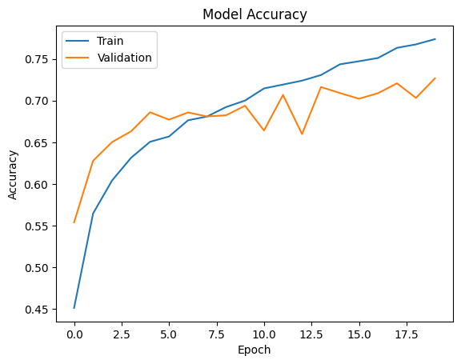

```python
# Model training evaluation
plt.plot(history_cnn_model_2_rgb.history['accuracy'])
plt.plot(history_cnn_model_2_rgb.history['val_accuracy'])
plt.title('Model Accuracy')
plt.ylabel('Accuracy')
plt.xlabel('Epoch')
plt.legend(['Train', 'Validation'], loc='upper left')
plt.show()
```

```python
# Evaluating the model on the test data
test_loss, test_accuracy = cnn_model_2_rgb.evaluate(test_mapdataset_rgb, verbose=2)
print(f"Test Loss: {test_loss:.4f}")
print(f"Test Accuracy: {test_accuracy:.4f}")
```

```
1/1 - 1s - 1s/step - accuracy: 0.7422 - loss: 0.8017
Test Loss: 0.8017
Test Accuracy: 0.7422
```

**Observations and Insights: RGB vs. Grayscale**

[output not shown]

In theory, 3 channels should offer 3 separate feature maps for the same information. This should allow the network to learn more varied low-level features.

`cnn_model_2_rgb` has performance that is slightly better at `74.22%` on test and validation data `72.67%`.

Since the RGB model has more parameters in its initial layers, it has a higher learning capacity BUT is more susceptible to overfitting.

We'll try more regularization in the form of:

- Adjusting dropout rates
- Increasing L2 regularization
- Changing the optimizer to AdamW
- Introducing checkpoints and early stopping

### **Second attempt at making the RGB model work**

```python
# Clearing backend
from keras import backend
backend.clear_session()

# Reset the random seed
import random
np.random.seed(42)
random.seed(42)
tf.random.set_seed(42)
```

```python
# cnn_model_3_rgb

from keras.initializers import HeNormal
from keras.regularizers import l2
from keras.optimizers import AdamW

he_normal_init = HeNormal()
reg_strength = 0.001 # higher than cnn_model_2_rgb

cnn_model_3_rgb = Sequential([

    # 1st convolutional layer: 16 filters and kernel size 3x3
    Conv2D(16, (3, 3), padding="same", input_shape=(48, 48, 3), # 3 channels for RGB
           kernel_initializer=he_normal_init,
           kernel_regularizer=l2(reg_strength)),
    BatchNormalization(),
    LeakyReLU(alpha=0.1),

    # 2nd convolutional layer: 32 filters and kernel size 3x3
    Conv2D(32, (3, 3), padding="same",
           kernel_initializer=he_normal_init,
           kernel_regularizer=l2(reg_strength)),
    BatchNormalization(),
    LeakyReLU(alpha=0.1),

    # MaxPooling 1
    MaxPooling2D(pool_size=(2, 2)),
    Dropout(0.3), # regularization to prevent overfitting

    # 3rd convolutional layer: 32 filters and kernel size 3x3
    Conv2D(32, (3, 3), padding="same",
           kernel_initializer=he_normal_init,
           kernel_regularizer=l2(reg_strength)),
    BatchNormalization(),
    LeakyReLU(alpha=0.1),

    # 4th convolutional layer: 64 filters and kernel size 3x3
    Conv2D(64, (3, 3), padding="same",
           kernel_initializer=he_normal_init,
           kernel_regularizer=l2(reg_strength)),
    BatchNormalization(),
    LeakyReLU(alpha=0.1),

    # 2nd MaxPooling layer. Cuts down trainable parameters
    MaxPooling2D(pool_size=(2, 2)),
    Dropout(0.3), # regularization to prevent overfitting

    Flatten(),

    Dense(32,
          kernel_initializer=he_normal_init,
          kernel_regularizer=l2(reg_strength)),
    BatchNormalization(),
    LeakyReLU(alpha=0.1),
    Dropout(0.6), # higher than cnn_model_2_rgb

    Dense(4, activation='softmax', kernel_initializer=he_normal_init)
], name="cnn_model_3_rgb")

# Using AdamW Optimizer
opt = AdamW(learning_rate=0.001)

cnn_model_3_rgb.compile(
    optimizer=opt,
    loss='categorical_crossentropy',
    metrics=['accuracy']
)

cnn_model_3_rgb.summary()
```

```
Model: "cnn_model_3_rgb"
```

```
┏━━━━━━━━━━━━━━━━━━━━━━━━━━━━━━━━━┳━━━━━━━━━━━━━━━━━━━━━━━━┳━━━━━━━━━━━━━━━┓
┃ Layer (type)                    ┃ Output Shape           ┃       Param # ┃
┡━━━━━━━━━━━━━━━━━━━━━━━━━━━━━━━━━╇━━━━━━━━━━━━━━━━━━━━━━━━╇━━━━━━━━━━━━━━━┩
│ conv2d (Conv2D)                 │ (None, 48, 48, 16)     │           448 │
├─────────────────────────────────┼────────────────────────┼───────────────┤
│ batch_normalization             │ (None, 48, 48, 16)     │            64 │
│ (BatchNormalization)            │                        │               │
├─────────────────────────────────┼────────────────────────┼───────────────┤
│ leaky_re_lu (LeakyReLU)         │ (None, 48, 48, 16)     │             0 │
├─────────────────────────────────┼────────────────────────┼───────────────┤
│ conv2d_1 (Conv2D)               │ (None, 48, 48, 32)     │         4,640 │
├─────────────────────────────────┼────────────────────────┼───────────────┤
│ batch_normalization_1           │ (None, 48, 48, 32)     │           128 │
│ (BatchNormalization)            │                        │               │
├─────────────────────────────────┼────────────────────────┼───────────────┤
│ leaky_re_lu_1 (LeakyReLU)       │ (None, 48, 48, 32)     │             0 │
├─────────────────────────────────┼────────────────────────┼───────────────┤
│ max_pooling2d (MaxPooling2D)    │ (None, 24, 24, 32)     │             0 │
├─────────────────────────────────┼────────────────────────┼───────────────┤
│ dropout (Dropout)               │ (None, 24, 24, 32)     │             0 │
├─────────────────────────────────┼────────────────────────┼───────────────┤
│ conv2d_2 (Conv2D)               │ (None, 24, 24, 32)     │         9,248 │
├─────────────────────────────────┼────────────────────────┼───────────────┤
│ batch_normalization_2           │ (None, 24, 24, 32)     │           128 │
│ (BatchNormalization)            │                        │               │
├─────────────────────────────────┼────────────────────────┼───────────────┤
│ leaky_re_lu_2 (LeakyReLU)       │ (None, 24, 24, 32)     │             0 │
├─────────────────────────────────┼────────────────────────┼───────────────┤
│ conv2d_3 (Conv2D)               │ (None, 24, 24, 64)     │        18,496 │
├─────────────────────────────────┼────────────────────────┼───────────────┤
│ batch_normalization_3           │ (None, 24, 24, 64)     │           256 │
│ (BatchNormalization)            │                        │               │
├─────────────────────────────────┼────────────────────────┼───────────────┤
│ leaky_re_lu_3 (LeakyReLU)       │ (None, 24, 24, 64)     │             0 │
├─────────────────────────────────┼────────────────────────┼───────────────┤
│ max_pooling2d_1 (MaxPooling2D)  │ (None, 12, 12, 64)     │             0 │
├─────────────────────────────────┼────────────────────────┼───────────────┤
│ dropout_1 (Dropout)             │ (None, 12, 12, 64)     │             0 │
├─────────────────────────────────┼────────────────────────┼───────────────┤
│ flatten (Flatten)               │ (None, 9216)           │             0 │
├─────────────────────────────────┼────────────────────────┼───────────────┤
│ dense (Dense)                   │ (None, 32)             │       294,944 │
├─────────────────────────────────┼────────────────────────┼───────────────┤
│ batch_normalization_4           │ (None, 32)             │           128 │
│ (BatchNormalization)            │                        │               │
├─────────────────────────────────┼────────────────────────┼───────────────┤
│ leaky_re_lu_4 (LeakyReLU)       │ (None, 32)             │             0 │
├─────────────────────────────────┼────────────────────────┼───────────────┤
│ dropout_2 (Dropout)             │ (None, 32)             │             0 │
├─────────────────────────────────┼────────────────────────┼───────────────┤
│ dense_1 (Dense)                 │ (None, 4)              │           132 │
└─────────────────────────────────┴────────────────────────┴───────────────┘
```

```
 Total params: 328,612 (1.25 MB)
```

```
 Trainable params: 328,260 (1.25 MB)
```

```
 Non-trainable params: 352 (1.38 KB)
```

```python
from keras.callbacks import EarlyStopping, ReduceLROnPlateau, ModelCheckpoint

# --- Define Callbacks ---

# EarlyStopping: Stops training when validation accuracy stops improving
early_stopping = EarlyStopping(
    monitor='val_accuracy',      # Monitor validation accuracy
    patience=10,                 # stop training if the validation metric has failed to improve for 10 consecutive epochs
    restore_best_weights=True    # Restore the best model weights
)

reduce_lr_on_plateau = ReduceLROnPlateau(
    monitor='val_accuracy', # Monitor the validation accuracy
    factor=0.5,             # Reduce the learning rate by a factor of 50%
    patience=5,             # Lower than the early stopping patience to lower LR before stopping
    min_lr=1e-5,            # Set a lower bound for the learning rate
    verbose=1,              # Print a message when the learning rate is reduced
    mode='max'              # The goal is to maximize the monitored metric (val_accuracy)
)

# Save model to Google Drive
cnn3_save_path = '/content/gdrive/MyDrive/Data Science/Capstone/cnn_model_3_rgb.keras'

# ModelCheckpoint: Saves the best model based on validation accuracy
cnn_model_3_rgb_checkpoint = ModelCheckpoint(
    filepath=cnn3_save_path,     # Name of the file to save the model to
    monitor='val_accuracy',      # Monitor validation accuracy
    save_best_only=True,         # Only save the best model found so far
    mode='max'                   # 'max' because we want to maximize accuracy
)

# --- Train the Model with Callbacks ---
history_cnn_model_3_rgb = cnn_model_3_rgb.fit(
    train_mapdataset_rgb,
    epochs=100, # A large number of epochs, EarlyStopping will stop training
    validation_data=val_mapdataset_rgb,
    callbacks=[early_stopping, reduce_lr_on_plateau, cnn_model_3_rgb_checkpoint]
)
```

```
473/473 ━━━━━━━━━━━━━━━━━━━━ 22s 27ms/step - accuracy: 0.3617 - loss: 1.9742 - val_accuracy: 0.5469 - val_loss: 1.4092 - learning_rate: 0.0010
473/473 ━━━━━━━━━━━━━━━━━━━━ 10s 21ms/step - accuracy: 0.5203 - loss: 1.4685 - val_accuracy: 0.6160 - val_loss: 1.2496 - learning_rate: 0.0010
473/473 ━━━━━━━━━━━━━━━━━━━━ 7s 14ms/step - accuracy: 0.5730 - loss: 1.3204 - val_accuracy: 0.6064 - val_loss: 1.2303 - learning_rate: 0.0010
473/473 ━━━━━━━━━━━━━━━━━━━━ 12s 17ms/step - accuracy: 0.5965 - loss: 1.2378 - val_accuracy: 0.6496 - val_loss: 1.1184 - learning_rate: 0.0010
473/473 ━━━━━━━━━━━━━━━━━━━━ 12s 22ms/step - accuracy: 0.6120 - loss: 1.1836 - val_accuracy: 0.6663 - val_loss: 1.0821 - learning_rate: 0.0010
473/473 ━━━━━━━━━━━━━━━━━━━━ 8s 16ms/step - accuracy: 0.6273 - loss: 1.1473 - val_accuracy: 0.6476 - val_loss: 1.0975 - learning_rate: 0.0010
473/473 ━━━━━━━━━━━━━━━━━━━━ 4s 9ms/step - accuracy: 0.6367 - loss: 1.1247 - val_accuracy: 0.6725 - val_loss: 1.0444 - learning_rate: 0.0010
473/473 ━━━━━━━━━━━━━━━━━━━━ 4s 9ms/step - accuracy: 0.6362 - loss: 1.1200 - val_accuracy: 0.6773 - val_loss: 1.0153 - learning_rate: 0.0010
473/473 ━━━━━━━━━━━━━━━━━━━━ 5s 11ms/step - accuracy: 0.6536 - loss: 1.0958 - val_accuracy: 0.6502 - val_loss: 1.0973 - learning_rate: 0.0010
473/473 ━━━━━━━━━━━━━━━━━━━━ 4s 9ms/step - accuracy: 0.6566 - loss: 1.0825 - val_accuracy: 0.7032 - val_loss: 0.9952 - learning_rate: 0.0010
473/473 ━━━━━━━━━━━━━━━━━━━━ 5s 9ms/step - accuracy: 0.6549 - loss: 1.0839 - val_accuracy: 0.6835 - val_loss: 1.0299 - learning_rate: 0.0010
473/473 ━━━━━━━━━━━━━━━━━━━━ 5s 11ms/step - accuracy: 0.6572 - loss: 1.0754 - val_accuracy: 0.6767 - val_loss: 1.0555 - learning_rate: 0.0010
473/473 ━━━━━━━━━━━━━━━━━━━━ 4s 9ms/step - accuracy: 0.6698 - loss: 1.0668 - val_accuracy: 0.6409 - val_loss: 1.1090 - learning_rate: 0.0010
473/473 ━━━━━━━━━━━━━━━━━━━━ 4s 9ms/step - accuracy: 0.6680 - loss: 1.0613 - val_accuracy: 0.6693 - val_loss: 1.0643 - learning_rate: 0.0010
473/473 ━━━━━━━━━━━━━━━━━━━━ 5s 11ms/step - accuracy: 0.6724 - loss: 1.0698 - val_accuracy: 0.7085 - val_loss: 0.9891 - learning_rate: 0.0010
473/473 ━━━━━━━━━━━━━━━━━━━━ 4s 8ms/step - accuracy: 0.6747 - loss: 1.0575 - val_accuracy: 0.6950 - val_loss: 1.0324 - learning_rate: 0.0010
473/473 ━━━━━━━━━━━━━━━━━━━━ 4s 9ms/step - accuracy: 0.6761 - loss: 1.0471 - val_accuracy: 0.7115 - val_loss: 0.9819 - learning_rate: 0.0010
473/473 ━━━━━━━━━━━━━━━━━━━━ 5s 11ms/step - accuracy: 0.6841 - loss: 1.0484 - val_accuracy: 0.7225 - val_loss: 0.9681 - learning_rate: 0.0010
473/473 ━━━━━━━━━━━━━━━━━━━━ 8s 16ms/step - accuracy: 0.6818 - loss: 1.0500 - val_accuracy: 0.6944 - val_loss: 1.0340 - learning_rate: 0.0010
473/473 ━━━━━━━━━━━━━━━━━━━━ 10s 21ms/step - accuracy: 0.6838 - loss: 1.0407 - val_accuracy: 0.6898 - val_loss: 1.0301 - learning_rate: 0.0010
473/473 ━━━━━━━━━━━━━━━━━━━━ 4s 8ms/step - accuracy: 0.6870 - loss: 1.0495 - val_accuracy: 0.7048 - val_loss: 1.0119 - learning_rate: 0.0010
473/473 ━━━━━━━━━━━━━━━━━━━━ 5s 11ms/step - accuracy: 0.6948 - loss: 1.0378 - val_accuracy: 0.6845 - val_loss: 1.0377 - learning_rate: 0.0010
466/473 ━━━━━━━━━━━━━━━━━━━━ 0s 7ms/step - accuracy: 0.7019 - loss: 1.0364
Epoch 23: ReduceLROnPlateau reducing learning rate to 0.0005000000237487257.
473/473 ━━━━━━━━━━━━━━━━━━━━ 4s 9ms/step - accuracy: 0.7019 - loss: 1.0363 - val_accuracy: 0.6960 - val_loss: 1.0375 - learning_rate: 0.0010
473/473 ━━━━━━━━━━━━━━━━━━━━ 4s 9ms/step - accuracy: 0.7175 - loss: 0.9954 - val_accuracy: 0.7221 - val_loss: 0.9547 - learning_rate: 5.0000e-04
473/473 ━━━━━━━━━━━━━━━━━━━━ 6s 10ms/step - accuracy: 0.7284 - loss: 0.9332 - val_accuracy: 0.7195 - val_loss: 0.9414 - learning_rate: 5.0000e-04
473/473 ━━━━━━━━━━━━━━━━━━━━ 4s 9ms/step - accuracy: 0.7298 - loss: 0.9141 - val_accuracy: 0.7281 - val_loss: 0.9166 - learning_rate: 5.0000e-04
473/473 ━━━━━━━━━━━━━━━━━━━━ 4s 9ms/step - accuracy: 0.7358 - loss: 0.8828 - val_accuracy: 0.7277 - val_loss: 0.9111 - learning_rate: 5.0000e-04
473/473 ━━━━━━━━━━━━━━━━━━━━ 5s 10ms/step - accuracy: 0.7386 - loss: 0.8825 - val_accuracy: 0.7263 - val_loss: 0.9120 - learning_rate: 5.0000e-04
473/473 ━━━━━━━━━━━━━━━━━━━━ 4s 8ms/step - accuracy: 0.7311 - loss: 0.9067 - val_accuracy: 0.7113 - val_loss: 0.9541 - learning_rate: 5.0000e-04
473/473 ━━━━━━━━━━━━━━━━━━━━ 4s 9ms/step - accuracy: 0.7493 - loss: 0.8562 - val_accuracy: 0.7227 - val_loss: 0.9215 - learning_rate: 5.0000e-04
473/473 ━━━━━━━━━━━━━━━━━━━━ 5s 11ms/step - accuracy: 0.7469 - loss: 0.8483 - val_accuracy: 0.7296 - val_loss: 0.9196 - learning_rate: 5.0000e-04
473/473 ━━━━━━━━━━━━━━━━━━━━ 4s 9ms/step - accuracy: 0.7452 - loss: 0.8589 - val_accuracy: 0.7071 - val_loss: 0.9593 - learning_rate: 5.0000e-04
473/473 ━━━━━━━━━━━━━━━━━━━━ 4s 9ms/step - accuracy: 0.7549 - loss: 0.8482 - val_accuracy: 0.7225 - val_loss: 0.9294 - learning_rate: 5.0000e-04
473/473 ━━━━━━━━━━━━━━━━━━━━ 5s 11ms/step - accuracy: 0.7549 - loss: 0.8550 - val_accuracy: 0.7322 - val_loss: 0.9172 - learning_rate: 5.0000e-04
473/473 ━━━━━━━━━━━━━━━━━━━━ 4s 9ms/step - accuracy: 0.7664 - loss: 0.8229 - val_accuracy: 0.7304 - val_loss: 0.9152 - learning_rate: 5.0000e-04
473/473 ━━━━━━━━━━━━━━━━━━━━ 4s 9ms/step - accuracy: 0.7605 - loss: 0.8411 - val_accuracy: 0.7275 - val_loss: 0.9587 - learning_rate: 5.0000e-04
473/473 ━━━━━━━━━━━━━━━━━━━━ 5s 10ms/step - accuracy: 0.7638 - loss: 0.8431 - val_accuracy: 0.7302 - val_loss: 0.9530 - learning_rate: 5.0000e-04
473/473 ━━━━━━━━━━━━━━━━━━━━ 4s 9ms/step - accuracy: 0.7674 - loss: 0.8164 - val_accuracy: 0.7245 - val_loss: 0.9565 - learning_rate: 5.0000e-04
```

[output cut: 20 more lines]

```
473/473 ━━━━━━━━━━━━━━━━━━━━ 4s 9ms/step - accuracy: 0.8459 - loss: 0.5856 - val_accuracy: 0.7472 - val_loss: 0.9148 - learning_rate: 1.2500e-04
473/473 ━━━━━━━━━━━━━━━━━━━━ 4s 9ms/step - accuracy: 0.8521 - loss: 0.5714 - val_accuracy: 0.7410 - val_loss: 0.9227 - learning_rate: 1.2500e-04
473/473 ━━━━━━━━━━━━━━━━━━━━ 5s 11ms/step - accuracy: 0.8478 - loss: 0.5777 - val_accuracy: 0.7382 - val_loss: 0.9317 - learning_rate: 1.2500e-04
473/473 ━━━━━━━━━━━━━━━━━━━━ 4s 8ms/step - accuracy: 0.8434 - loss: 0.5751 - val_accuracy: 0.7392 - val_loss: 0.9156 - learning_rate: 1.2500e-04
473/473 ━━━━━━━━━━━━━━━━━━━━ 4s 8ms/step - accuracy: 0.8485 - loss: 0.5705 - val_accuracy: 0.7432 - val_loss: 0.9437 - learning_rate: 1.2500e-04
467/473 ━━━━━━━━━━━━━━━━━━━━ 0s 10ms/step - accuracy: 0.8441 - loss: 0.5654
Epoch 60: ReduceLROnPlateau reducing learning rate to 6.25000029685907e-05.
473/473 ━━━━━━━━━━━━━━━━━━━━ 5s 11ms/step - accuracy: 0.8442 - loss: 0.5654 - val_accuracy: 0.7294 - val_loss: 0.9430 - learning_rate: 1.2500e-04
473/473 ━━━━━━━━━━━━━━━━━━━━ 4s 9ms/step - accuracy: 0.8588 - loss: 0.5490 - val_accuracy: 0.7462 - val_loss: 0.9193 - learning_rate: 6.2500e-05
473/473 ━━━━━━━━━━━━━━━━━━━━ 4s 9ms/step - accuracy: 0.8617 - loss: 0.5354 - val_accuracy: 0.7382 - val_loss: 0.9276 - learning_rate: 6.2500e-05
473/473 ━━━━━━━━━━━━━━━━━━━━ 5s 11ms/step - accuracy: 0.8603 - loss: 0.5368 - val_accuracy: 0.7422 - val_loss: 0.9208 - learning_rate: 6.2500e-05
473/473 ━━━━━━━━━━━━━━━━━━━━ 4s 9ms/step - accuracy: 0.8665 - loss: 0.5239 - val_accuracy: 0.7402 - val_loss: 0.9269 - learning_rate: 6.2500e-05
466/473 ━━━━━━━━━━━━━━━━━━━━ 0s 7ms/step - accuracy: 0.8634 - loss: 0.5256
Epoch 65: ReduceLROnPlateau reducing learning rate to 3.125000148429535e-05.
473/473 ━━━━━━━━━━━━━━━━━━━━ 4s 9ms/step - accuracy: 0.8635 - loss: 0.5254 - val_accuracy: 0.7418 - val_loss: 0.9227 - learning_rate: 6.2500e-05
```

```python
# Load the model from G-drive
cnn3_save_path = '/content/gdrive/MyDrive/Data Science/Capstone/cnn_model_3_rgb.keras'
cnn_model_3_rgb = keras.models.load_model(cnn3_save_path)
```

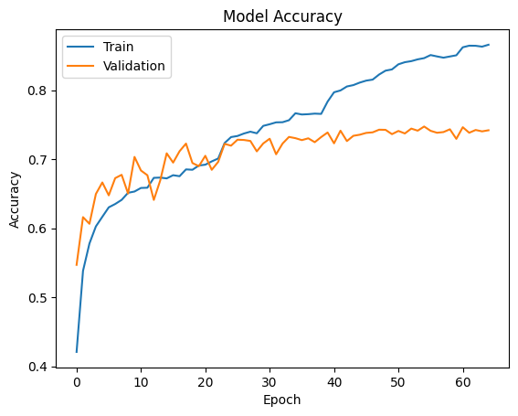

```python
# Model training evaluation
plt.plot(history_cnn_model_3_rgb.history['accuracy'])
plt.plot(history_cnn_model_3_rgb.history['val_accuracy'])
plt.title('Model Accuracy')
plt.ylabel('Accuracy')
plt.xlabel('Epoch')
plt.legend(['Train', 'Validation'], loc='upper left')
plt.show()
```

```python
train_loss, train_accuracy = cnn_model_3_rgb.evaluate(train_mapdataset_rgb, verbose=2)
print(f"Train Loss: {train_loss:.4f}")
print(f"Train Accuracy: {train_accuracy:.4f}")

val_loss, val_accuracy = cnn_model_3_rgb.evaluate(val_mapdataset_rgb, verbose=2)
print(f"Validation Loss: {val_loss:.4f}")
print(f"Validation Accuracy: {val_accuracy:.4f}")

test_loss, test_accuracy = cnn_model_3_rgb.evaluate(test_mapdataset_rgb, verbose=2)
print(f"Test Loss: {test_loss:.4f}")
print(f"Test Accuracy: {test_accuracy:.4f}")
```

```
473/473 - 6s - 12ms/step - accuracy: 0.9513 - loss: 0.3649
Train Loss: 0.3649
Train Accuracy: 0.9513
10/10 - 2s - 194ms/step - accuracy: 0.7472 - loss: 0.9148
Validation Loss: 0.9148
Validation Accuracy: 0.7472
1/1 - 1s - 753ms/step - accuracy: 0.7656 - loss: 0.7349
Test Loss: 0.7349
Test Accuracy: 0.7656
```

```python
from sklearn.metrics import f1_score, classification_report

test_true_labels = []

# to use sklearn f1_score, we need to extract the y/true labels
for images, labels in test_mapdataset_rgb:
    # Convert the TensorFlow tensor of one-hot encoded labels to a NumPy array
    labels_numpy = labels.numpy()
    labels_int = np.argmax(labels_numpy, axis=1) # argmax the array to get the int label value
    test_true_labels.extend(labels_int)

y_pred_probs_test = cnn_model_3_rgb.predict(test_mapdataset_rgb)
y_pred_test = np.argmax(y_pred_probs_test, axis=1)

f1 = f1_score(test_true_labels, y_pred_test, average='weighted') # 'weighted' adjusts for the distribution imbalance between classes
print(f"F1 Score: {f1:.4f}")

print(classification_report(test_true_labels, y_pred_test))
```

```
1/1 ━━━━━━━━━━━━━━━━━━━━ 1s 561ms/step
F1 Score: 0.7699
              precision    recall  f1-score   support

           0       0.90      0.81      0.85        32
           1       0.61      0.72      0.66        32
           2       0.68      0.66      0.67        32
           3       0.93      0.88      0.90        32

    accuracy                           0.77       128
   macro avg       0.78      0.77      0.77       128
weighted avg       0.78      0.77      0.77       128
```

```python
get_inference_time(cnn_model_3_rgb, test_mapdataset_rgb)
```

```
Starting sequential unbatched inference on 128 images with cnn_model_3_rgb
--------------------------------------------------
Mean inference time per image: 63.49 ms
```

**Observations and Insights: 2nd RGB Model with early stopping + more regularization**

[output not shown]

`cnn_model_3_rgb` achieved satisfactory performance at `76.56%` accuracy on test data.

We'll also evaluate F1 score since we know our dataset is imblanced.

`cnn_model_3_rgb` is the best performing model by accuracy with an F1 score (0-1 with 1 being the best) of `0.7699`.

**Note**: A large batch size (`512`) for validation data was crucial because it made `val_accuracy` more stable for each epoch. `val_accuracy` is used by all 3 training callbacks. If it is not stable, it is difficult for the callbacks to determine if a true performance plateau had been reached.

There's still overfitting so we may try to adjust the dropout rates later.

## **Transfer Learning Architectures**

In this section, we will create several Transfer Learning architectures. For the pre-trained models, we will select three popular architectures namely, VGG16, ResNet v2, and Efficient Net. The difference between these architectures and the previous architectures is that these will require 3 input channels while the earlier ones worked on 'grayscale' images. Therefore, we need to create new DataLoaders.

### **Creating our Data Loaders for Transfer Learning Architectures**

In this section, we are creating data loaders that we will use as inputs to our Neural Network.

We will have to go with color_mode = 'rgb' as this is the required format for the transfer learning architectures.

```python
# we already prepared rgb train, val, test datasets earlier

print(f"Training RGB dataset:")
print(f"element spec:", train_dataset_rgb.element_spec)
train_batches = train_dataset_rgb.cardinality().numpy()
print(f"Number of Train batches: {train_batches}", end='\n\n')

print(f"Validation RGB dataset:")
print(f"element spec:", val_dataset_rgb.element_spec)
val_batches = val_dataset_rgb.cardinality().numpy()
print(f"Number of Validation batches: {val_batches}", end='\n\n')

print(f"Test RGB dataset:")
print(f"element spec:", test_dataset_rgb.element_spec)
test_batches = test_dataset_rgb.cardinality().numpy()
print(f"Number of Test batches: {test_batches}", end='\n\n')

# we'll use preprocess_vgg16() instead of normalize_img() later
# So no need to create the mapdatasets at this stage
```

```
Training RGB dataset:
element spec: (TensorSpec(shape=(None, 48, 48, 3), dtype=tf.float32, name=None), TensorSpec(shape=(None, 4), dtype=tf.float32, name=None))
Number of Train batches: 473

Validation RGB dataset:
element spec: (TensorSpec(shape=(None, 48, 48, 3), dtype=tf.float32, name=None), TensorSpec(shape=(None, 4), dtype=tf.float32, name=None))
Number of Validation batches: 10

Test RGB dataset:
element spec: (TensorSpec(shape=(None, 48, 48, 3), dtype=tf.float32, name=None), TensorSpec(shape=(None, 4), dtype=tf.float32, name=None))
Number of Test batches: 1
```

## **VGG16 Model**

VGG16 was trained on the ImageNet dataset on 1.2+ million images with 1000 different object categories.

VGG16 has a large number of parameters (over 138 million).

The convolutional base of VGG16 is highly effective at extracting general image features. These features (such as lines, textures, and shapes) are also relevant for facial analysis, as they help to capture the nuances of a face, such as the wrinkles around the eyes or the shape of the mouth.

We will cut off the original VGG16 classification layers as we want to classify the 4 emotions not the original 1000 object categories.

### **Importing the VGG16 Architecture**

```python
# Clearing backend
from keras import backend
backend.clear_session()

# Reset the random seed
import random
np.random.seed(42)
random.seed(42)
tf.random.set_seed(42)
```

```python
# import VGG16 Architecture
from keras.applications import VGG16

# Load the VGG16 base model with ImageNet weights, excluding the top layers
vgg16_base = VGG16(
    weights='imagenet',
    include_top=False, # exclude fully connected classification layers
    input_shape=(224, 224, 3) # VGG16 expects RGB input
)

# Freeze the convolutional base to prevent its weights from being updated
vgg16_base.trainable = False
```

```python
# Create dataloaders with the new preprocessing function

# --- Preprocess Function for VGG16 ---
def preprocess_vgg16(image, label):
    # Resize the image to VGG16's required input size
    image = tf.image.resize(image, (224, 224))
    # Normalize images for VGG16's specific requirements
    image = tf.keras.applications.vgg16.preprocess_input(image)
    return image, label

# We have to reduce the batch size for the validation set because there is not enough memory as VGG16 model is very large

val_dataset_sm_batch_rgb = tf.keras.utils.image_dataset_from_directory(
    '/content/Facial_emotion_images/validation/',
    image_size=(48, 48),
    batch_size=64,
    labels='inferred',
    label_mode='categorical',
    color_mode='rgb',
    shuffle=False # Do NOT shuffle so we can extract labels consistently for F1 score
)

train_vgg_dataset = train_dataset_rgb.map(preprocess_vgg16)
val_vgg_dataset = val_dataset_sm_batch_rgb.map(preprocess_vgg16)
test_vgg_dataset = test_dataset_rgb.map(preprocess_vgg16)
```

```
Found 4977 files belonging to 4 classes.
```

### **Model Building**

- Import VGG16 and add Fully Connected layers on top of it.

```python
from keras.layers import GlobalAveragePooling2D
from keras.initializers import HeNormal
from keras.regularizers import l2

he_normal_init = HeNormal()
reg_strength = 0.0005 # higher than cnn_model_2_rgb

# Create a new model on top of the frozen VGG16 base
vgg16_cnn_model = Sequential([
    vgg16_base,

    # replace Flatten() to speed up training by reducing number of parameters in the subsequent Dense layers
    # also reduces overfitting as our dataset is much smaller than ImageNet
    GlobalAveragePooling2D(),

    # not overly large dense layer to prevent overfitting and speed up training
    # but not too small as to underfit
    Dense(64,
          kernel_initializer=he_normal_init,
          kernel_regularizer=l2(reg_strength)),
    BatchNormalization(),
    LeakyReLU(alpha=0.1),
    Dropout(0.5),

    Dense(4, activation='softmax', kernel_initializer=he_normal_init)
])

vgg16_cnn_model.summary()
```

```
Model: "sequential"
```

```
┏━━━━━━━━━━━━━━━━━━━━━━━━━━━━━━━━━┳━━━━━━━━━━━━━━━━━━━━━━━━┳━━━━━━━━━━━━━━━┓
┃ Layer (type)                    ┃ Output Shape           ┃       Param # ┃
┡━━━━━━━━━━━━━━━━━━━━━━━━━━━━━━━━━╇━━━━━━━━━━━━━━━━━━━━━━━━╇━━━━━━━━━━━━━━━┩
│ vgg16 (Functional)              │ (None, 7, 7, 512)      │    14,714,688 │
├─────────────────────────────────┼────────────────────────┼───────────────┤
│ global_average_pooling2d        │ (None, 512)            │             0 │
│ (GlobalAveragePooling2D)        │                        │               │
├─────────────────────────────────┼────────────────────────┼───────────────┤
│ dense (Dense)                   │ (None, 64)             │        32,832 │
├─────────────────────────────────┼────────────────────────┼───────────────┤
│ batch_normalization             │ (None, 64)             │           256 │
│ (BatchNormalization)            │                        │               │
├─────────────────────────────────┼────────────────────────┼───────────────┤
│ leaky_re_lu (LeakyReLU)         │ (None, 64)             │             0 │
├─────────────────────────────────┼────────────────────────┼───────────────┤
│ dropout (Dropout)               │ (None, 64)             │             0 │
├─────────────────────────────────┼────────────────────────┼───────────────┤
│ dense_1 (Dense)                 │ (None, 4)              │           260 │
└─────────────────────────────────┴────────────────────────┴───────────────┘
```

```
 Total params: 14,748,036 (56.26 MB)
```

```
 Trainable params: 33,220 (129.77 KB)
```

```
 Non-trainable params: 14,714,816 (56.13 MB)
```

### **Compiling and Training the VGG16 Model**

```python
opt = Adam(learning_rate=0.001)

vgg16_cnn_model.compile(
    optimizer=opt,
    loss='categorical_crossentropy',
    metrics=['accuracy']
)
```

```python
# Check for GPUs. Training this model will require one.
print("Num GPUs Available: ", len(tf.config.list_physical_devices('GPU')))
```

```
Num GPUs Available:  1
```

```python
# Lower precision to float16 for training to fit in memory
from keras import mixed_precision

policy = mixed_precision.Policy('mixed_float16')
mixed_precision.set_global_policy(policy)
```

```python
from keras.callbacks import EarlyStopping, ReduceLROnPlateau, ModelCheckpoint

# --- Define Callbacks ---

# EarlyStopping: Stops training when validation accuracy stops improving
early_stopping = EarlyStopping(
    monitor='val_accuracy',      # Monitor validation accuracy
    patience=10,                 # stop training if the validation metric has failed to improve for 10 consecutive epochs
    restore_best_weights=True    # Restore the best model weights
)

reduce_lr_on_plateau = ReduceLROnPlateau(
    monitor='val_accuracy',     # Monitor validation accuracy
    factor=0.5,                 # Reduce the learning rate by a factor of 50%
    patience=5,                 # Lower than the early stopping patience to lower LR before stopping
    min_lr=1e-5,                # Set a lower bound for the learning rate
    verbose=1,                  # Print a message when the learning rate is reduced
    mode='max'                  # The goal is to maximize the monitored metric (val_accuracy)
)

# Save model to Google Drive
vgg16_cnn_save_path = '/content/gdrive/MyDrive/Data Science/Capstone/vgg16_cnn_model.keras'

# ModelCheckpoint: Saves the best model based on validation accuracy
model_checkpoint = ModelCheckpoint(
    filepath=vgg16_cnn_save_path,     # Name of the file to save the model to
    monitor='val_accuracy',           # Monitor validation accuracy
    save_best_only=True,              # Only save the best model found so far
    mode='max'                        # 'max' because we want to maximize accuracy
)

# Train with callbacks
history_vgg16_cnn_model = vgg16_cnn_model.fit(
    train_vgg_dataset,
    epochs=100,
    class_weight=class_weights_dict,
    validation_data=val_vgg_dataset,
    callbacks=[early_stopping, reduce_lr_on_plateau, model_checkpoint]
)
```

```
473/473 ━━━━━━━━━━━━━━━━━━━━ 167s 346ms/step - accuracy: 0.4521 - loss: 1.3754 - val_accuracy: 0.6333 - val_loss: 0.9527 - learning_rate: 0.0010
473/473 ━━━━━━━━━━━━━━━━━━━━ 113s 240ms/step - accuracy: 0.5959 - loss: 1.0214 - val_accuracy: 0.6470 - val_loss: 0.9275 - learning_rate: 0.0010
473/473 ━━━━━━━━━━━━━━━━━━━━ 114s 241ms/step - accuracy: 0.6195 - loss: 0.9564 - val_accuracy: 0.6626 - val_loss: 0.8879 - learning_rate: 0.0010
473/473 ━━━━━━━━━━━━━━━━━━━━ 114s 240ms/step - accuracy: 0.6298 - loss: 0.9204 - val_accuracy: 0.6647 - val_loss: 0.8819 - learning_rate: 0.0010
473/473 ━━━━━━━━━━━━━━━━━━━━ 114s 240ms/step - accuracy: 0.6460 - loss: 0.9011 - val_accuracy: 0.6596 - val_loss: 0.8811 - learning_rate: 0.0010
473/473 ━━━━━━━━━━━━━━━━━━━━ 114s 240ms/step - accuracy: 0.6512 - loss: 0.8829 - val_accuracy: 0.6578 - val_loss: 0.8936 - learning_rate: 0.0010
473/473 ━━━━━━━━━━━━━━━━━━━━ 113s 239ms/step - accuracy: 0.6546 - loss: 0.8790 - val_accuracy: 0.6586 - val_loss: 0.8776 - learning_rate: 0.0010
473/473 ━━━━━━━━━━━━━━━━━━━━ 114s 240ms/step - accuracy: 0.6682 - loss: 0.8614 - val_accuracy: 0.6665 - val_loss: 0.8770 - learning_rate: 0.0010
473/473 ━━━━━━━━━━━━━━━━━━━━ 113s 240ms/step - accuracy: 0.6670 - loss: 0.8643 - val_accuracy: 0.6614 - val_loss: 0.8848 - learning_rate: 0.0010
473/473 ━━━━━━━━━━━━━━━━━━━━ 114s 241ms/step - accuracy: 0.6702 - loss: 0.8542 - val_accuracy: 0.6671 - val_loss: 0.8742 - learning_rate: 0.0010
473/473 ━━━━━━━━━━━━━━━━━━━━ 114s 240ms/step - accuracy: 0.6739 - loss: 0.8486 - val_accuracy: 0.6699 - val_loss: 0.8708 - learning_rate: 0.0010
473/473 ━━━━━━━━━━━━━━━━━━━━ 113s 239ms/step - accuracy: 0.6763 - loss: 0.8380 - val_accuracy: 0.6671 - val_loss: 0.8809 - learning_rate: 0.0010
473/473 ━━━━━━━━━━━━━━━━━━━━ 113s 239ms/step - accuracy: 0.6734 - loss: 0.8448 - val_accuracy: 0.6635 - val_loss: 0.8947 - learning_rate: 0.0010
473/473 ━━━━━━━━━━━━━━━━━━━━ 113s 240ms/step - accuracy: 0.6754 - loss: 0.8413 - val_accuracy: 0.6612 - val_loss: 0.8873 - learning_rate: 0.0010
473/473 ━━━━━━━━━━━━━━━━━━━━ 114s 240ms/step - accuracy: 0.6792 - loss: 0.8333 - val_accuracy: 0.6622 - val_loss: 0.8934 - learning_rate: 0.0010
472/473 ━━━━━━━━━━━━━━━━━━━━ 0s 186ms/step - accuracy: 0.6729 - loss: 0.8357
Epoch 16: ReduceLROnPlateau reducing learning rate to 0.0005000000237487257.
473/473 ━━━━━━━━━━━━━━━━━━━━ 113s 239ms/step - accuracy: 0.6729 - loss: 0.8357 - val_accuracy: 0.6637 - val_loss: 0.8901 - learning_rate: 0.0010
473/473 ━━━━━━━━━━━━━━━━━━━━ 114s 240ms/step - accuracy: 0.6856 - loss: 0.8143 - val_accuracy: 0.6721 - val_loss: 0.8770 - learning_rate: 5.0000e-04
473/473 ━━━━━━━━━━━━━━━━━━━━ 114s 240ms/step - accuracy: 0.6990 - loss: 0.7947 - val_accuracy: 0.6729 - val_loss: 0.8754 - learning_rate: 5.0000e-04
473/473 ━━━━━━━━━━━━━━━━━━━━ 114s 240ms/step - accuracy: 0.6991 - loss: 0.7897 - val_accuracy: 0.6661 - val_loss: 0.8912 - learning_rate: 5.0000e-04
473/473 ━━━━━━━━━━━━━━━━━━━━ 114s 241ms/step - accuracy: 0.6921 - loss: 0.7862 - val_accuracy: 0.6689 - val_loss: 0.8841 - learning_rate: 5.0000e-04
473/473 ━━━━━━━━━━━━━━━━━━━━ 114s 241ms/step - accuracy: 0.6965 - loss: 0.7736 - val_accuracy: 0.6671 - val_loss: 0.8862 - learning_rate: 5.0000e-04
473/473 ━━━━━━━━━━━━━━━━━━━━ 113s 240ms/step - accuracy: 0.7015 - loss: 0.7748 - val_accuracy: 0.6639 - val_loss: 0.8899 - learning_rate: 5.0000e-04
472/473 ━━━━━━━━━━━━━━━━━━━━ 0s 187ms/step - accuracy: 0.7023 - loss: 0.7706
Epoch 23: ReduceLROnPlateau reducing learning rate to 0.0002500000118743628.
473/473 ━━━━━━━━━━━━━━━━━━━━ 114s 241ms/step - accuracy: 0.7023 - loss: 0.7706 - val_accuracy: 0.6675 - val_loss: 0.8853 - learning_rate: 5.0000e-04
473/473 ━━━━━━━━━━━━━━━━━━━━ 114s 240ms/step - accuracy: 0.7069 - loss: 0.7580 - val_accuracy: 0.6715 - val_loss: 0.8799 - learning_rate: 2.5000e-04
473/473 ━━━━━━━━━━━━━━━━━━━━ 129s 273ms/step - accuracy: 0.7149 - loss: 0.7438 - val_accuracy: 0.6743 - val_loss: 0.8760 - learning_rate: 2.5000e-04
473/473 ━━━━━━━━━━━━━━━━━━━━ 115s 242ms/step - accuracy: 0.7218 - loss: 0.7336 - val_accuracy: 0.6707 - val_loss: 0.8829 - learning_rate: 2.5000e-04
473/473 ━━━━━━━━━━━━━━━━━━━━ 114s 240ms/step - accuracy: 0.7154 - loss: 0.7385 - val_accuracy: 0.6739 - val_loss: 0.8820 - learning_rate: 2.5000e-04
473/473 ━━━━━━━━━━━━━━━━━━━━ 114s 240ms/step - accuracy: 0.7160 - loss: 0.7436 - val_accuracy: 0.6739 - val_loss: 0.8859 - learning_rate: 2.5000e-04
473/473 ━━━━━━━━━━━━━━━━━━━━ 113s 240ms/step - accuracy: 0.7215 - loss: 0.7229 - val_accuracy: 0.6681 - val_loss: 0.8895 - learning_rate: 2.5000e-04
472/473 ━━━━━━━━━━━━━━━━━━━━ 0s 187ms/step - accuracy: 0.7244 - loss: 0.7219
Epoch 30: ReduceLROnPlateau reducing learning rate to 0.0001250000059371814.
473/473 ━━━━━━━━━━━━━━━━━━━━ 114s 241ms/step - accuracy: 0.7244 - loss: 0.7220 - val_accuracy: 0.6717 - val_loss: 0.8810 - learning_rate: 2.5000e-04
473/473 ━━━━━━━━━━━━━━━━━━━━ 113s 239ms/step - accuracy: 0.7240 - loss: 0.7233 - val_accuracy: 0.6725 - val_loss: 0.8911 - learning_rate: 1.2500e-04
473/473 ━━━━━━━━━━━━━━━━━━━━ 113s 239ms/step - accuracy: 0.7202 - loss: 0.7221 - val_accuracy: 0.6719 - val_loss: 0.8842 - learning_rate: 1.2500e-04
473/473 ━━━━━━━━━━━━━━━━━━━━ 114s 241ms/step - accuracy: 0.7252 - loss: 0.7125 - val_accuracy: 0.6723 - val_loss: 0.8864 - learning_rate: 1.2500e-04
473/473 ━━━━━━━━━━━━━━━━━━━━ 113s 240ms/step - accuracy: 0.7255 - loss: 0.7068 - val_accuracy: 0.6725 - val_loss: 0.8820 - learning_rate: 1.2500e-04
472/473 ━━━━━━━━━━━━━━━━━━━━ 0s 186ms/step - accuracy: 0.7360 - loss: 0.7089
Epoch 35: ReduceLROnPlateau reducing learning rate to 6.25000029685907e-05.
473/473 ━━━━━━━━━━━━━━━━━━━━ 113s 239ms/step - accuracy: 0.7360 - loss: 0.7089 - val_accuracy: 0.6733 - val_loss: 0.8860 - learning_rate: 1.2500e-04
```

### **Evaluating the VGG16 model**

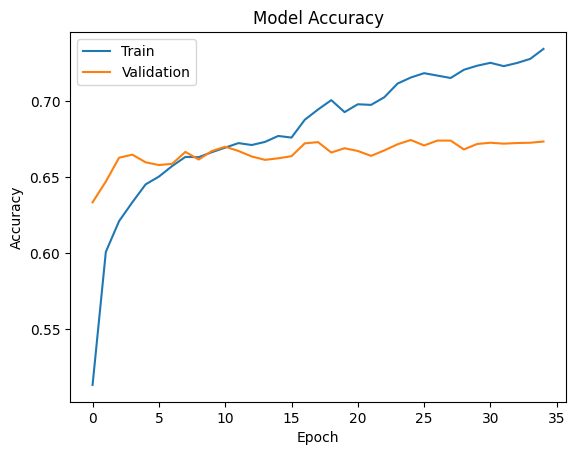

```python
# Model training evaluation
plt.plot(history_vgg16_cnn_model.history['accuracy'])
plt.plot(history_vgg16_cnn_model.history['val_accuracy'])
plt.title('Model Accuracy')
plt.ylabel('Accuracy')
plt.xlabel('Epoch')
plt.legend(['Train', 'Validation'], loc='upper left')
plt.show()
```

**Observations:**

Training accuracy continues to improve even while validation accuracy plateaus. This means the model has learned all it can to generalize. Past this point, it is just learning noise to fit the training data better.

```python
train_loss, train_accuracy = vgg16_cnn_model.evaluate(train_vgg_dataset, verbose=2)
print(f"Train Loss: {train_loss:.4f}")
print(f"Train Accuracy: {train_accuracy:.4f}")

val_loss, val_accuracy = vgg16_cnn_model.evaluate(val_vgg_dataset, verbose=2)
print(f"Validation Loss: {val_loss:.4f}")
print(f"Validation Accuracy: {val_accuracy:.4f}")

test_loss, test_accuracy = vgg16_cnn_model.evaluate(test_vgg_dataset, verbose=2)
print(f"Test Loss: {test_loss:.4f}")
print(f"Test Accuracy: {test_accuracy:.4f}")
```

```
473/473 - 89s - 189ms/step - accuracy: 0.7773 - loss: 0.6317
Train Loss: 0.6317
Train Accuracy: 0.7773
78/78 - 27s - 346ms/step - accuracy: 0.6743 - loss: 0.8760
Validation Loss: 0.8760
Validation Accuracy: 0.6743
1/1 - 1s - 1s/step - accuracy: 0.7266 - loss: 0.7105
Test Loss: 0.7105
Test Accuracy: 0.7266
```

**Observations and Insights: VGG16 Transfer Learning**

| Model Name | Accuracy (train) | Train Loss | Accuracy (val) | Val Loss | Accuracy (test) | Test Loss |
| --- | --- | --- | --- | --- | --- | --- |
| cnn_model_3_rgb | 95.13% | 0.3649 | 74.72% | 0.9148 | 76.56% | 0.7349 |
| vgg16_cnn_model | 77.73% | 0.6317 | 67.43% | 0.8760 | 72.66% | 0.7105 |

## **ResNet V2 Model**

**ResNetV2 is more memory efficient than VGG16** (despite having more parameters).

VGG's layers retain a high number of feature map channels at large spatial resolutions (e.g., 512 channels at a 28x28 resolution). The activations of these intermediate layers consume a lot of memory.

A key design principle of ResNet is that it only doubles the number of feature map channels after reducing the spatial dimensions by half through a stride-2 convolution.

Even if a ResNet model has more total parameters, its architectural design—which reduces activation sizes more effectively—leads to lower overall memory consumption during training.

Like VGG16, ResNetV2 was trained on the ImageNet dataset.

```python
# Clearing backend
from keras import backend
backend.clear_session()

# Reset the random seed
import random
np.random.seed(42)
random.seed(42)
tf.random.set_seed(42)
```

### **Model Building**

- Import Resnet v2 upto the layer of your choice and add Fully Connected layers on top of it.

```python
# Import ResNet50V2 Architecture
from keras.applications import ResNet50V2
from keras.applications.resnet_v2 import preprocess_input as preprocess_resnet_v2
```

```python
def preprocess_resnet_v2(image, label):
    # Resize the image to ResNet50V2's required input size
    image = tf.image.resize(image, (224, 224))
    # Normalize images for ResNet50V2's specific requirements
    image = tf.keras.applications.resnet_v2.preprocess_input(image)
    return image, label
```

```python
# Create dataloaders with the new preprocessing function
train_resnet_dataset = train_dataset_rgb.map(preprocess_resnet_v2)
val_resnet_dataset = val_dataset_rgb.map(preprocess_resnet_v2)
test_resnet_dataset = test_dataset_rgb.map(preprocess_resnet_v2)
```

```python
# Load the ResNet50V2 base model with ImageNet weights, excluding the top layers
resnet50_v2_base = ResNet50V2(
    weights='imagenet',
    include_top=False, # exclude fully connected classification layers
    input_shape=(224, 224, 3)
)

# Freeze the base model to prevent its weights from being updated
resnet50_v2_base.trainable = False
```

```
Downloading data from https://storage.googleapis.com/tensorflow/keras-applications/resnet/resnet50v2_weights_tf_dim_ordering_tf_kernels_notop.h5
94668760/94668760 ━━━━━━━━━━━━━━━━━━━━ 0s 0us/step
```

```python
# Lower precision to float16 for training to fit in memory
from keras import mixed_precision

policy = mixed_precision.Policy('mixed_float16')
mixed_precision.set_global_policy(policy)
```

```python
from keras.layers import GlobalAveragePooling2D
from keras.initializers import HeNormal
from keras.regularizers import l2

he_normal_init = HeNormal()
reg_strength = 0.0005 # higher than cnn_model_2_rgb

resnet_v2_cnn_model = Sequential([
    resnet50_v2_base,

    # replace Flatten() to speed up training by reducing number of parameters in the subsequent Dense layers
    # also reduces overfitting as our dataset is much smaller than ImageNet
    GlobalAveragePooling2D(),

    # not overly large dense layer to prevent overfitting and speed up training
    # but not too small as to underfit
    Dense(64,
          kernel_initializer=he_normal_init,
          kernel_regularizer=l2(reg_strength)),
    BatchNormalization(),
    LeakyReLU(alpha=0.1),
    Dropout(0.5),

    Dense(4, activation='softmax', kernel_initializer=he_normal_init)
])

resnet_v2_cnn_model.summary()
```

```
Model: "sequential"
```

```
┏━━━━━━━━━━━━━━━━━━━━━━━━━━━━━━━━━┳━━━━━━━━━━━━━━━━━━━━━━━━┳━━━━━━━━━━━━━━━┓
┃ Layer (type)                    ┃ Output Shape           ┃       Param # ┃
┡━━━━━━━━━━━━━━━━━━━━━━━━━━━━━━━━━╇━━━━━━━━━━━━━━━━━━━━━━━━╇━━━━━━━━━━━━━━━┩
│ resnet50v2 (Functional)         │ (None, 7, 7, 2048)     │    23,564,800 │
├─────────────────────────────────┼────────────────────────┼───────────────┤
│ global_average_pooling2d        │ (None, 2048)           │             0 │
│ (GlobalAveragePooling2D)        │                        │               │
├─────────────────────────────────┼────────────────────────┼───────────────┤
│ dense (Dense)                   │ (None, 64)             │       131,136 │
├─────────────────────────────────┼────────────────────────┼───────────────┤
│ batch_normalization             │ (None, 64)             │           256 │
│ (BatchNormalization)            │                        │               │
├─────────────────────────────────┼────────────────────────┼───────────────┤
│ leaky_re_lu (LeakyReLU)         │ (None, 64)             │             0 │
├─────────────────────────────────┼────────────────────────┼───────────────┤
│ dropout (Dropout)               │ (None, 64)             │             0 │
├─────────────────────────────────┼────────────────────────┼───────────────┤
│ dense_1 (Dense)                 │ (None, 4)              │           260 │
└─────────────────────────────────┴────────────────────────┴───────────────┘
```

```
 Total params: 23,696,452 (90.39 MB)
```

```
 Trainable params: 131,524 (513.77 KB)
```

```
 Non-trainable params: 23,564,928 (89.89 MB)
```

### **Compiling and Training the Model**

```python
opt = Adam(learning_rate=0.001)

resnet_v2_cnn_model.compile(
    optimizer=opt,
    loss='categorical_crossentropy',
    metrics=['accuracy']
)
```

```python
from keras.callbacks import EarlyStopping, ReduceLROnPlateau, ModelCheckpoint

# --- Define Callbacks ---

# EarlyStopping: Stops training when validation accuracy stops improving
early_stopping = EarlyStopping(
    monitor='val_accuracy',      # Monitor validation accuracy
    patience=10,                 # stop training if the validation metric has failed to improve for 10 consecutive epochs
    restore_best_weights=True    # Restore the best model weights
)

reduce_lr_on_plateau = ReduceLROnPlateau(
    monitor='val_accuracy',     # Monitor validation accuracy
    factor=0.5,                 # Reduce the learning rate by a factor of 50%
    patience=5,                 # Lower than the early stopping patience to lower LR before stopping
    min_lr=1e-5,                # Set a lower bound for the learning rate
    verbose=1,                  # Print a message when the learning rate is reduced
    mode='max'                  # The goal is to maximize the monitored metric (val_accuracy)
)

# Save model to Google Drive
resnet_v2_cnn_save_path = '/content/gdrive/MyDrive/Data Science/Capstone/resnet_v2_cnn_model.keras'

# ModelCheckpoint: Saves the best model based on validation accuracy
model_checkpoint = ModelCheckpoint(
    filepath=resnet_v2_cnn_save_path,     # Name of the file to save the model to
    monitor='val_accuracy',               # Monitor validation accuracy
    save_best_only=True,                  # Only save the best model found so far
    mode='max'                            # 'max' because we want to maximize accuracy
)

# Train with callbacks
history_resnet_v2_cnn_model = resnet_v2_cnn_model.fit(
    train_resnet_dataset,
    epochs=100,
    class_weight=class_weights_dict,
    validation_data=val_resnet_dataset,
    callbacks=[early_stopping, reduce_lr_on_plateau, model_checkpoint]
)
```

```
473/473 ━━━━━━━━━━━━━━━━━━━━ 52s 110ms/step - accuracy: 0.7064 - loss: 0.7924 - val_accuracy: 0.6940 - val_loss: 0.8515 - learning_rate: 0.0010
473/473 ━━━━━━━━━━━━━━━━━━━━ 48s 100ms/step - accuracy: 0.7040 - loss: 0.8026 - val_accuracy: 0.6936 - val_loss: 0.8555 - learning_rate: 0.0010
473/473 ━━━━━━━━━━━━━━━━━━━━ 48s 101ms/step - accuracy: 0.7111 - loss: 0.7827 - val_accuracy: 0.6922 - val_loss: 0.8563 - learning_rate: 0.0010
473/473 ━━━━━━━━━━━━━━━━━━━━ 49s 103ms/step - accuracy: 0.7049 - loss: 0.7949 - val_accuracy: 0.6858 - val_loss: 0.8844 - learning_rate: 0.0010
473/473 ━━━━━━━━━━━━━━━━━━━━ 50s 106ms/step - accuracy: 0.7082 - loss: 0.7972 - val_accuracy: 0.6982 - val_loss: 0.8677 - learning_rate: 0.0010
473/473 ━━━━━━━━━━━━━━━━━━━━ 49s 103ms/step - accuracy: 0.7056 - loss: 0.7992 - val_accuracy: 0.6882 - val_loss: 0.8833 - learning_rate: 0.0010
473/473 ━━━━━━━━━━━━━━━━━━━━ 50s 105ms/step - accuracy: 0.7232 - loss: 0.7799 - val_accuracy: 0.7042 - val_loss: 0.8498 - learning_rate: 0.0010
473/473 ━━━━━━━━━━━━━━━━━━━━ 48s 101ms/step - accuracy: 0.7144 - loss: 0.7882 - val_accuracy: 0.7018 - val_loss: 0.8575 - learning_rate: 0.0010
473/473 ━━━━━━━━━━━━━━━━━━━━ 49s 103ms/step - accuracy: 0.7198 - loss: 0.7750 - val_accuracy: 0.6964 - val_loss: 0.8676 - learning_rate: 0.0010
473/473 ━━━━━━━━━━━━━━━━━━━━ 48s 101ms/step - accuracy: 0.7186 - loss: 0.7819 - val_accuracy: 0.6902 - val_loss: 0.8889 - learning_rate: 0.0010
473/473 ━━━━━━━━━━━━━━━━━━━━ 83s 103ms/step - accuracy: 0.7215 - loss: 0.7833 - val_accuracy: 0.6908 - val_loss: 0.8957 - learning_rate: 0.0010
472/473 ━━━━━━━━━━━━━━━━━━━━ 0s 75ms/step - accuracy: 0.7214 - loss: 0.7865
Epoch 12: ReduceLROnPlateau reducing learning rate to 0.0005000000237487257.
473/473 ━━━━━━━━━━━━━━━━━━━━ 48s 101ms/step - accuracy: 0.7214 - loss: 0.7865 - val_accuracy: 0.6872 - val_loss: 0.8909 - learning_rate: 0.0010
473/473 ━━━━━━━━━━━━━━━━━━━━ 48s 102ms/step - accuracy: 0.7339 - loss: 0.7561 - val_accuracy: 0.6986 - val_loss: 0.8797 - learning_rate: 5.0000e-04
473/473 ━━━━━━━━━━━━━━━━━━━━ 48s 101ms/step - accuracy: 0.7432 - loss: 0.7265 - val_accuracy: 0.6998 - val_loss: 0.8747 - learning_rate: 5.0000e-04
473/473 ━━━━━━━━━━━━━━━━━━━━ 49s 104ms/step - accuracy: 0.7558 - loss: 0.7012 - val_accuracy: 0.7127 - val_loss: 0.8686 - learning_rate: 5.0000e-04
473/473 ━━━━━━━━━━━━━━━━━━━━ 48s 102ms/step - accuracy: 0.7577 - loss: 0.7001 - val_accuracy: 0.7046 - val_loss: 0.8821 - learning_rate: 5.0000e-04
473/473 ━━━━━━━━━━━━━━━━━━━━ 48s 101ms/step - accuracy: 0.7573 - loss: 0.6819 - val_accuracy: 0.7071 - val_loss: 0.8850 - learning_rate: 5.0000e-04
473/473 ━━━━━━━━━━━━━━━━━━━━ 48s 101ms/step - accuracy: 0.7615 - loss: 0.6759 - val_accuracy: 0.7008 - val_loss: 0.8920 - learning_rate: 5.0000e-04
473/473 ━━━━━━━━━━━━━━━━━━━━ 48s 101ms/step - accuracy: 0.7617 - loss: 0.6754 - val_accuracy: 0.7077 - val_loss: 0.8888 - learning_rate: 5.0000e-04
472/473 ━━━━━━━━━━━━━━━━━━━━ 0s 81ms/step - accuracy: 0.7621 - loss: 0.6722
Epoch 20: ReduceLROnPlateau reducing learning rate to 0.0002500000118743628.
473/473 ━━━━━━━━━━━━━━━━━━━━ 93s 124ms/step - accuracy: 0.7621 - loss: 0.6721 - val_accuracy: 0.7046 - val_loss: 0.8895 - learning_rate: 5.0000e-04
473/473 ━━━━━━━━━━━━━━━━━━━━ 52s 109ms/step - accuracy: 0.7793 - loss: 0.6449 - val_accuracy: 0.7129 - val_loss: 0.8735 - learning_rate: 2.5000e-04
473/473 ━━━━━━━━━━━━━━━━━━━━ 48s 102ms/step - accuracy: 0.7800 - loss: 0.6325 - val_accuracy: 0.7081 - val_loss: 0.8910 - learning_rate: 2.5000e-04
473/473 ━━━━━━━━━━━━━━━━━━━━ 48s 102ms/step - accuracy: 0.7907 - loss: 0.6105 - val_accuracy: 0.7071 - val_loss: 0.8928 - learning_rate: 2.5000e-04
473/473 ━━━━━━━━━━━━━━━━━━━━ 48s 101ms/step - accuracy: 0.7882 - loss: 0.6023 - val_accuracy: 0.7040 - val_loss: 0.9055 - learning_rate: 2.5000e-04
473/473 ━━━━━━━━━━━━━━━━━━━━ 48s 103ms/step - accuracy: 0.7928 - loss: 0.5969 - val_accuracy: 0.7141 - val_loss: 0.8956 - learning_rate: 2.5000e-04
473/473 ━━━━━━━━━━━━━━━━━━━━ 48s 102ms/step - accuracy: 0.7893 - loss: 0.5958 - val_accuracy: 0.7131 - val_loss: 0.8980 - learning_rate: 2.5000e-04
473/473 ━━━━━━━━━━━━━━━━━━━━ 49s 103ms/step - accuracy: 0.7989 - loss: 0.5843 - val_accuracy: 0.7171 - val_loss: 0.8967 - learning_rate: 2.5000e-04
473/473 ━━━━━━━━━━━━━━━━━━━━ 48s 102ms/step - accuracy: 0.7993 - loss: 0.5803 - val_accuracy: 0.7143 - val_loss: 0.9069 - learning_rate: 2.5000e-04
473/473 ━━━━━━━━━━━━━━━━━━━━ 49s 103ms/step - accuracy: 0.8040 - loss: 0.5774 - val_accuracy: 0.7081 - val_loss: 0.9154 - learning_rate: 2.5000e-04
473/473 ━━━━━━━━━━━━━━━━━━━━ 49s 104ms/step - accuracy: 0.8053 - loss: 0.5729 - val_accuracy: 0.7141 - val_loss: 0.9147 - learning_rate: 2.5000e-04
473/473 ━━━━━━━━━━━━━━━━━━━━ 52s 109ms/step - accuracy: 0.7950 - loss: 0.5761 - val_accuracy: 0.7087 - val_loss: 0.9252 - learning_rate: 2.5000e-04
472/473 ━━━━━━━━━━━━━━━━━━━━ 0s 74ms/step - accuracy: 0.7999 - loss: 0.5584
Epoch 32: ReduceLROnPlateau reducing learning rate to 0.0001250000059371814.
473/473 ━━━━━━━━━━━━━━━━━━━━ 48s 101ms/step - accuracy: 0.7999 - loss: 0.5584 - val_accuracy: 0.7157 - val_loss: 0.9120 - learning_rate: 2.5000e-04
473/473 ━━━━━━━━━━━━━━━━━━━━ 48s 102ms/step - accuracy: 0.8093 - loss: 0.5499 - val_accuracy: 0.7141 - val_loss: 0.9085 - learning_rate: 1.2500e-04
473/473 ━━━━━━━━━━━━━━━━━━━━ 48s 102ms/step - accuracy: 0.8243 - loss: 0.5355 - val_accuracy: 0.7127 - val_loss: 0.9292 - learning_rate: 1.2500e-04
473/473 ━━━━━━━━━━━━━━━━━━━━ 48s 101ms/step - accuracy: 0.8170 - loss: 0.5306 - val_accuracy: 0.7151 - val_loss: 0.9175 - learning_rate: 1.2500e-04
473/473 ━━━━━━━━━━━━━━━━━━━━ 49s 103ms/step - accuracy: 0.8239 - loss: 0.5126 - val_accuracy: 0.7103 - val_loss: 0.9244 - learning_rate: 1.2500e-04
472/473 ━━━━━━━━━━━━━━━━━━━━ 0s 75ms/step - accuracy: 0.8240 - loss: 0.5213
Epoch 37: ReduceLROnPlateau reducing learning rate to 6.25000029685907e-05.
473/473 ━━━━━━━━━━━━━━━━━━━━ 48s 101ms/step - accuracy: 0.8240 - loss: 0.5213 - val_accuracy: 0.7135 - val_loss: 0.9314 - learning_rate: 1.2500e-04
```

### **Evaluating the ResNet Model**

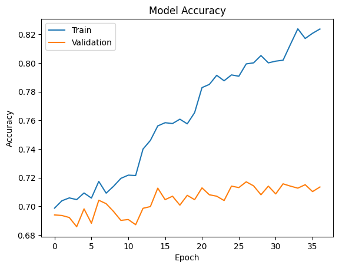

```python
# Model training evaluation
plt.plot(history_resnet_v2_cnn_model.history['accuracy'])
plt.plot(history_resnet_v2_cnn_model.history['val_accuracy'])
plt.title('Model Accuracy')
plt.ylabel('Accuracy')
plt.xlabel('Epoch')
plt.legend(['Train', 'Validation'], loc='upper left')
plt.show()
```

```python
train_loss, train_accuracy = resnet_v2_cnn_model.evaluate(train_resnet_dataset, verbose=2)
print(f"Train Loss: {train_loss:.4f}")
print(f"Train Accuracy: {train_accuracy:.4f}")

val_loss, val_accuracy = resnet_v2_cnn_model.evaluate(val_resnet_dataset, verbose=2)
print(f"Validation Loss: {val_loss:.4f}")
print(f"Validation Accuracy: {val_accuracy:.4f}")

test_loss, test_accuracy = resnet_v2_cnn_model.evaluate(test_resnet_dataset, verbose=2)
print(f"Test Loss: {test_loss:.4f}")
print(f"Test Accuracy: {test_accuracy:.4f}")
```

```
473/473 - 39s - 82ms/step - accuracy: 0.8731 - loss: 0.4503
Train Loss: 0.4503
Train Accuracy: 0.8731
10/10 - 12s - 1s/step - accuracy: 0.7171 - loss: 0.8967
Validation Loss: 0.8967
Validation Accuracy: 0.7171
1/1 - 19s - 19s/step - accuracy: 0.7109 - loss: 0.7828
Test Loss: 0.7828
Test Accuracy: 0.7109
```

**Observations and Insights: ResNetV2 Transfer Learning**

| Model Name | Accuracy (train) | Train Loss | Accuracy (val) | Val Loss | Accuracy (test) | Test Loss |
| --- | --- | --- | --- | --- | --- | --- |
| cnn_model_3_rgb | 95.13% | 0.3649 | 74.72% | 0.9148 | 76.56% | 0.7349 |
| vgg16_cnn_model | 77.73% | 0.6317 | 67.43% | 0.8760 | 72.66% | 0.7105 |
| resnet_v2_cnn_model | 87.31% | 0.4503 | 71.71% | 0.8967 | 71.09% | 0.7828 |

**ResNetV2 is more memory efficient during training than VGG16** (despite having more parameters). Each training epoch took less than half the time that the VGG16 model did (for most epochs but not all).

The final model's performance comes close to but does not exceed `cnn_model_3_rgb`.

The final model is even larger than the one we trained with a VGG16 base at `93.1 MB`.

## **EfficientNet Model**

```python
# Clearing backend
from keras import backend
backend.clear_session()

# Reset the random seed
import random
np.random.seed(42)
random.seed(42)
tf.random.set_seed(42)
```

### **Model Building**

B0 is the smallest and most efficient variant of EffcientNet.

```python
# Import EfficientNetB0 Architecture
from keras.applications import EfficientNetB0
```

```python
# Just resize the image; no other preprocessing is necessary
# EfficientNet handles normalization

def preprocess_efficientnet(image, label):
    image = tf.image.resize(image, (224, 224))
    return image, label
```

```python
# Create dataloaders with the new preprocessing function
train_efficientnet_dataset = train_dataset_rgb.map(preprocess_efficientnet)
val_efficientnet_dataset = val_dataset_rgb.map(preprocess_efficientnet)
test_efficientnet_dataset = test_dataset_rgb.map(preprocess_efficientnet)
```

```python
# Load the EfficientNetB0 base model with ImageNet weights, excluding the top layers
efficientnet_base = EfficientNetB0(
    weights='imagenet',
    include_top=False,
    input_shape=(224, 224, 3)
)

# Freeze the base model to prevent its weights from being updated
efficientnet_base.trainable = False
```

```
Downloading data from https://storage.googleapis.com/keras-applications/efficientnetb0_notop.h5
16705208/16705208 ━━━━━━━━━━━━━━━━━━━━ 0s 0us/step
```

```python
from keras.layers import GlobalAveragePooling2D
from keras.initializers import HeNormal
from keras.regularizers import l2

he_normal_init = HeNormal()
reg_strength = 0.0005 # higher than cnn_model_2_rgb

efficientnet_cnn_model = Sequential([
    efficientnet_base,

    # replace Flatten() to speed up training by reducing number of parameters in the subsequent Dense layers
    # also reduces overfitting as our dataset is much smaller than ImageNet
    GlobalAveragePooling2D(),

    # not overly large dense layer to prevent overfitting and speed up training
    # but not too small as to underfit
    Dense(64,
          kernel_initializer=he_normal_init,
          kernel_regularizer=l2(reg_strength)),
    BatchNormalization(),
    LeakyReLU(alpha=0.1),
    Dropout(0.5),

    Dense(4, activation='softmax', kernel_initializer=he_normal_init)
])

efficientnet_cnn_model.summary()
```

```
Model: "sequential"
```

```
┏━━━━━━━━━━━━━━━━━━━━━━━━━━━━━━━━━┳━━━━━━━━━━━━━━━━━━━━━━━━┳━━━━━━━━━━━━━━━┓
┃ Layer (type)                    ┃ Output Shape           ┃       Param # ┃
┡━━━━━━━━━━━━━━━━━━━━━━━━━━━━━━━━━╇━━━━━━━━━━━━━━━━━━━━━━━━╇━━━━━━━━━━━━━━━┩
│ efficientnetb0 (Functional)     │ (None, 7, 7, 1280)     │     4,049,571 │
├─────────────────────────────────┼────────────────────────┼───────────────┤
│ global_average_pooling2d        │ (None, 1280)           │             0 │
│ (GlobalAveragePooling2D)        │                        │               │
├─────────────────────────────────┼────────────────────────┼───────────────┤
│ dense (Dense)                   │ (None, 64)             │        81,984 │
├─────────────────────────────────┼────────────────────────┼───────────────┤
│ batch_normalization             │ (None, 64)             │           256 │
│ (BatchNormalization)            │                        │               │
├─────────────────────────────────┼────────────────────────┼───────────────┤
│ leaky_re_lu (LeakyReLU)         │ (None, 64)             │             0 │
├─────────────────────────────────┼────────────────────────┼───────────────┤
│ dropout (Dropout)               │ (None, 64)             │             0 │
├─────────────────────────────────┼────────────────────────┼───────────────┤
│ dense_1 (Dense)                 │ (None, 4)              │           260 │
└─────────────────────────────────┴────────────────────────┴───────────────┘
```

```
 Total params: 4,132,071 (15.76 MB)
```

```
 Trainable params: 82,372 (321.77 KB)
```

```
 Non-trainable params: 4,049,699 (15.45 MB)
```

### **Compiling and Training the Model**

```python
opt = Adam(learning_rate=0.001)

efficientnet_cnn_model.compile(
    optimizer=opt,
    loss='categorical_crossentropy',
    metrics=['accuracy']
)
```

```python
from keras.callbacks import EarlyStopping, ReduceLROnPlateau, ModelCheckpoint

# --- Define Callbacks ---

# EarlyStopping: Stops training when validation accuracy stops improving
early_stopping = EarlyStopping(
    monitor='val_accuracy',      # Monitor validation accuracy
    patience=10,                 # stop training if the validation metric has failed to improve for 10 consecutive epochs
    restore_best_weights=True    # Restore the best model weights
)

reduce_lr_on_plateau = ReduceLROnPlateau(
    monitor='val_accuracy',     # Monitor validation accuracy
    factor=0.5,                 # Reduce the learning rate by a factor of 50%
    patience=5,                 # Lower than the early stopping patience to lower LR before stopping
    min_lr=1e-5,                # Set a lower bound for the learning rate
    verbose=1,                  # Print a message when the learning rate is reduced
    mode='max'                  # The goal is to maximize the monitored metric (val_accuracy)
)

# Save model to Google Drive
efficientnet_cnn_save_path = '/content/gdrive/MyDrive/Data Science/Capstone/efficientnet_cnn_model.keras'

# ModelCheckpoint: Saves the best model based on validation accuracy
model_checkpoint = ModelCheckpoint(
    filepath=efficientnet_cnn_save_path,     # Name of the file to save the model to
    monitor='val_accuracy',                  # Monitor validation accuracy
    save_best_only=True,                     # Only save the best model found so far
    mode='max'                               # 'max' because we want to maximize accuracy
)

# train with callbacks
history_efficientnet_cnn_model = efficientnet_cnn_model.fit(
    train_efficientnet_dataset,
    epochs=100,
    class_weight=class_weights_dict,
    validation_data=val_efficientnet_dataset,
    callbacks=[early_stopping, reduce_lr_on_plateau, model_checkpoint]
)
```

```
473/473 ━━━━━━━━━━━━━━━━━━━━ 162s 273ms/step - accuracy: 0.4862 - loss: 1.3053 - val_accuracy: 0.6622 - val_loss: 0.9105 - learning_rate: 0.0010
473/473 ━━━━━━━━━━━━━━━━━━━━ 27s 57ms/step - accuracy: 0.6086 - loss: 0.9947 - val_accuracy: 0.6870 - val_loss: 0.8748 - learning_rate: 0.0010
473/473 ━━━━━━━━━━━━━━━━━━━━ 33s 70ms/step - accuracy: 0.6400 - loss: 0.9247 - val_accuracy: 0.6958 - val_loss: 0.8368 - learning_rate: 0.0010
473/473 ━━━━━━━━━━━━━━━━━━━━ 27s 58ms/step - accuracy: 0.6486 - loss: 0.9081 - val_accuracy: 0.7095 - val_loss: 0.8124 - learning_rate: 0.0010
473/473 ━━━━━━━━━━━━━━━━━━━━ 26s 55ms/step - accuracy: 0.6541 - loss: 0.9067 - val_accuracy: 0.7095 - val_loss: 0.8121 - learning_rate: 0.0010
473/473 ━━━━━━━━━━━━━━━━━━━━ 28s 59ms/step - accuracy: 0.6624 - loss: 0.8912 - val_accuracy: 0.7113 - val_loss: 0.8209 - learning_rate: 0.0010
473/473 ━━━━━━━━━━━━━━━━━━━━ 26s 55ms/step - accuracy: 0.6705 - loss: 0.8699 - val_accuracy: 0.6924 - val_loss: 0.8378 - learning_rate: 0.0010
473/473 ━━━━━━━━━━━━━━━━━━━━ 26s 54ms/step - accuracy: 0.6643 - loss: 0.8808 - val_accuracy: 0.7097 - val_loss: 0.8120 - learning_rate: 0.0010
473/473 ━━━━━━━━━━━━━━━━━━━━ 41s 55ms/step - accuracy: 0.6664 - loss: 0.8715 - val_accuracy: 0.7064 - val_loss: 0.8335 - learning_rate: 0.0010
473/473 ━━━━━━━━━━━━━━━━━━━━ 27s 56ms/step - accuracy: 0.6741 - loss: 0.8602 - val_accuracy: 0.7046 - val_loss: 0.8182 - learning_rate: 0.0010
472/473 ━━━━━━━━━━━━━━━━━━━━ 0s 42ms/step - accuracy: 0.6745 - loss: 0.8601
Epoch 11: ReduceLROnPlateau reducing learning rate to 0.0005000000237487257.
473/473 ━━━━━━━━━━━━━━━━━━━━ 26s 54ms/step - accuracy: 0.6745 - loss: 0.8601 - val_accuracy: 0.7030 - val_loss: 0.8348 - learning_rate: 0.0010
473/473 ━━━━━━━━━━━━━━━━━━━━ 26s 55ms/step - accuracy: 0.6873 - loss: 0.8461 - val_accuracy: 0.7215 - val_loss: 0.7920 - learning_rate: 5.0000e-04
473/473 ━━━━━━━━━━━━━━━━━━━━ 26s 55ms/step - accuracy: 0.6977 - loss: 0.8189 - val_accuracy: 0.7209 - val_loss: 0.7871 - learning_rate: 5.0000e-04
473/473 ━━━━━━━━━━━━━━━━━━━━ 26s 54ms/step - accuracy: 0.6956 - loss: 0.8108 - val_accuracy: 0.7207 - val_loss: 0.7938 - learning_rate: 5.0000e-04
473/473 ━━━━━━━━━━━━━━━━━━━━ 26s 54ms/step - accuracy: 0.6995 - loss: 0.8053 - val_accuracy: 0.7195 - val_loss: 0.7956 - learning_rate: 5.0000e-04
473/473 ━━━━━━━━━━━━━━━━━━━━ 25s 54ms/step - accuracy: 0.7052 - loss: 0.7927 - val_accuracy: 0.7117 - val_loss: 0.7988 - learning_rate: 5.0000e-04
473/473 ━━━━━━━━━━━━━━━━━━━━ 0s 40ms/step - accuracy: 0.6999 - loss: 0.8002
Epoch 17: ReduceLROnPlateau reducing learning rate to 0.0002500000118743628.
473/473 ━━━━━━━━━━━━━━━━━━━━ 25s 53ms/step - accuracy: 0.6999 - loss: 0.8002 - val_accuracy: 0.7215 - val_loss: 0.7866 - learning_rate: 5.0000e-04
473/473 ━━━━━━━━━━━━━━━━━━━━ 26s 55ms/step - accuracy: 0.7055 - loss: 0.7881 - val_accuracy: 0.7223 - val_loss: 0.7862 - learning_rate: 2.5000e-04
473/473 ━━━━━━━━━━━━━━━━━━━━ 27s 56ms/step - accuracy: 0.7125 - loss: 0.7563 - val_accuracy: 0.7271 - val_loss: 0.7785 - learning_rate: 2.5000e-04
473/473 ━━━━━━━━━━━━━━━━━━━━ 42s 57ms/step - accuracy: 0.7225 - loss: 0.7479 - val_accuracy: 0.7277 - val_loss: 0.7821 - learning_rate: 2.5000e-04
473/473 ━━━━━━━━━━━━━━━━━━━━ 27s 58ms/step - accuracy: 0.7250 - loss: 0.7412 - val_accuracy: 0.7281 - val_loss: 0.7797 - learning_rate: 2.5000e-04
473/473 ━━━━━━━━━━━━━━━━━━━━ 26s 54ms/step - accuracy: 0.7251 - loss: 0.7406 - val_accuracy: 0.7243 - val_loss: 0.7846 - learning_rate: 2.5000e-04
473/473 ━━━━━━━━━━━━━━━━━━━━ 26s 55ms/step - accuracy: 0.7282 - loss: 0.7419 - val_accuracy: 0.7306 - val_loss: 0.7858 - learning_rate: 2.5000e-04
473/473 ━━━━━━━━━━━━━━━━━━━━ 25s 53ms/step - accuracy: 0.7259 - loss: 0.7415 - val_accuracy: 0.7277 - val_loss: 0.7728 - learning_rate: 2.5000e-04
473/473 ━━━━━━━━━━━━━━━━━━━━ 26s 55ms/step - accuracy: 0.7241 - loss: 0.7313 - val_accuracy: 0.7326 - val_loss: 0.7719 - learning_rate: 2.5000e-04
473/473 ━━━━━━━━━━━━━━━━━━━━ 25s 53ms/step - accuracy: 0.7299 - loss: 0.7205 - val_accuracy: 0.7251 - val_loss: 0.7774 - learning_rate: 2.5000e-04
473/473 ━━━━━━━━━━━━━━━━━━━━ 26s 54ms/step - accuracy: 0.7292 - loss: 0.7296 - val_accuracy: 0.7249 - val_loss: 0.7790 - learning_rate: 2.5000e-04
473/473 ━━━━━━━━━━━━━━━━━━━━ 26s 54ms/step - accuracy: 0.7373 - loss: 0.7194 - val_accuracy: 0.7251 - val_loss: 0.7867 - learning_rate: 2.5000e-04
473/473 ━━━━━━━━━━━━━━━━━━━━ 32s 67ms/step - accuracy: 0.7326 - loss: 0.7185 - val_accuracy: 0.7332 - val_loss: 0.7772 - learning_rate: 2.5000e-04
473/473 ━━━━━━━━━━━━━━━━━━━━ 26s 54ms/step - accuracy: 0.7361 - loss: 0.7157 - val_accuracy: 0.7294 - val_loss: 0.7759 - learning_rate: 2.5000e-04
473/473 ━━━━━━━━━━━━━━━━━━━━ 42s 57ms/step - accuracy: 0.7250 - loss: 0.7158 - val_accuracy: 0.7296 - val_loss: 0.7771 - learning_rate: 2.5000e-04
473/473 ━━━━━━━━━━━━━━━━━━━━ 26s 56ms/step - accuracy: 0.7305 - loss: 0.7125 - val_accuracy: 0.7243 - val_loss: 0.7837 - learning_rate: 2.5000e-04
473/473 ━━━━━━━━━━━━━━━━━━━━ 26s 54ms/step - accuracy: 0.7362 - loss: 0.7067 - val_accuracy: 0.7300 - val_loss: 0.7814 - learning_rate: 2.5000e-04
473/473 ━━━━━━━━━━━━━━━━━━━━ 0s 42ms/step - accuracy: 0.7335 - loss: 0.7149
```

[output cut: 19 more lines]

### **Evaluating the EfficientnetNet Model**

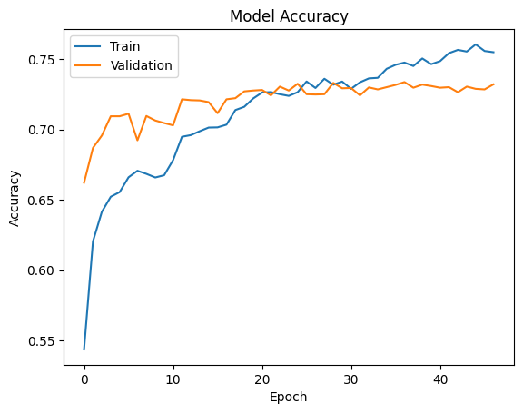

```python
# Model training evaluation
plt.plot(history_efficientnet_cnn_model.history['accuracy'])
plt.plot(history_efficientnet_cnn_model.history['val_accuracy'])
plt.title('Model Accuracy')
plt.ylabel('Accuracy')
plt.xlabel('Epoch')
plt.legend(['Train', 'Validation'], loc='upper left')
plt.show()
```

```python
train_loss, train_accuracy = efficientnet_cnn_model.evaluate(train_efficientnet_dataset, verbose=2)
print(f"Train Loss: {train_loss:.4f}")
print(f"Train Accuracy: {train_accuracy:.4f}")

val_loss, val_accuracy = efficientnet_cnn_model.evaluate(val_efficientnet_dataset, verbose=2)
print(f"Validation Loss: {val_loss:.4f}")
print(f"Validation Accuracy: {val_accuracy:.4f}")

test_loss, test_accuracy = efficientnet_cnn_model.evaluate(test_efficientnet_dataset, verbose=2)
print(f"Test Loss: {test_loss:.4f}")
print(f"Test Accuracy: {test_accuracy:.4f}")
```

```
473/473 - 18s - 38ms/step - accuracy: 0.8327 - loss: 0.5153
Train Loss: 0.5153
Train Accuracy: 0.8327
10/10 - 6s - 580ms/step - accuracy: 0.7338 - loss: 0.7755
Validation Loss: 0.7755
Validation Accuracy: 0.7338
1/1 - 0s - 293ms/step - accuracy: 0.7422 - loss: 0.6352
Test Loss: 0.6352
Test Accuracy: 0.7422
```

**Observations and Insights: EfficientNet Transfer Learning**

| Model Name | Accuracy (train) | Train Loss | Accuracy (val) | Val Loss | Accuracy (test) | Test Loss | File size |
| --- | --- | --- | --- | --- | --- | --- | --- |
| cnn_model_3_rgb | 95.13% | 0.3649 | 74.72% | 0.9148 | 76.56% | 0.7349 | 3.8 MB |
| vgg16_cnn_model | 77.73% | 0.6317 | 67.43% | 0.8760 | 72.66% | 0.7105 | 56.6 MB |
| resnet_v2_cnn_model | 87.31% | 0.4503 | 71.71% | 0.8967 | 71.09% | 0.7828 | 93.1 MB |
| efficientnet_cnn_model | 83.27% | 0.5153 | 73.38% | 0.7755 | 74.22% | 0.6352 | 17.2 MB |

EfficientNet was the fastest to train (amongst the 3 base models we used for transfer learning).

The model trained using EfficientNet as a convolutional base for feature extraction comes close to the performance of `cnn_model_3_rgb`.

However though these are powerful models for image classification, our custom trained model has the advantage of being trained solely on the FER (Facial Emotion Recognition) dataset for the specific purpose of classifying the 4 emotions.

Fundamentally we have a mismatch between the datasets that these base models were trained on versus our dataset.

All 4 models use RGB color mode for their input so it's good to benchmark their performance against `cnn_model_3_rgb`.

**Transfer learning observations:**

- Overall the transfer learning models did not perform satisfactorily.
- Worse yet, they were costly and time consuming to train.
- It is likely that the poor performance is due to the color mode as all 3 models were trained on RGB images.
  - By loading the datasets in 'rgb' color mode, we already providing images with 3 channels as the model expects.
  - Given more time (and compute), we could try changing the first layer of the models to accept grayscale images and fine tune that layer.

Now that we have tried multiple pre-trained models, let's build a more complex CNN architecture and see if we can get better performance.

## **Building a Complex Neural Network Architecture**

```python
# Clearing backend
from keras import backend
backend.clear_session()

# Reset the random seed
import random
np.random.seed(42)
random.seed(42)
tf.random.set_seed(42)
```

## **Creating our Data Loaders**

In this section, we are creating data loaders which we will use as inputs to the more Complicated Convolutional Neural Network.

We will go ahead with color_mode = 'grayscale'.

```python
# convert pixel values from the 0–255 integer range to a 0-1 float range
def normalize_img(image, label):
    image = tf.cast(image, tf.float32) / 255.0 # cast int8 to float32
    return image, label

train_dataset = tf.keras.utils.image_dataset_from_directory(
    '/content/Facial_emotion_images/train/',
    image_size=(48, 48),    # image size
    batch_size=32,          # smaller batch size to escape local minima during training
    labels='inferred',      # Infers labels from subdirectories
    label_mode='categorical',
    color_mode='grayscale',
    shuffle=True            # Shuffle to reduce overfitting
)

train_mapdataset = train_dataset.map(normalize_img)

val_dataset = tf.keras.utils.image_dataset_from_directory(
    '/content/Facial_emotion_images/validation/',
    image_size=(48, 48),
    batch_size=512,            # larger batch size for validation
    labels='inferred',
    label_mode='categorical',
    color_mode='grayscale',
    shuffle=False # Do NOT shuffle so we can extract labels consistently for F1 score
)

val_mapdataset = val_dataset.map(normalize_img)

test_dataset = tf.keras.utils.image_dataset_from_directory(
    '/content/Facial_emotion_images/test/',
    image_size=(48, 48),
    batch_size=128,           # larger batch size for test. There are 128 images in test.
    labels='inferred',
    label_mode='categorical',
    color_mode='grayscale',
    shuffle=False # Do NOT shuffle so we can extract labels consistently for F1 score
)

test_mapdataset = test_dataset.map(normalize_img)
```

```
Found 15109 files belonging to 4 classes.
Found 4977 files belonging to 4 classes.
Found 128 files belonging to 4 classes.
```

### **Model Building**

Using cnn_model_3_rgb as a starting point, we'll build a more complex model with 5 convolutional blocks.

```python
# Using cnn_model_3_rgb as a starting point
# cnn_model_3_rgb had 2 convolution blocks (with 2 Conv2D layers each)

# Refactor to use the Functional API instead of Sequential
from keras.initializers import HeNormal
from keras.regularizers import l2
from keras.layers import Conv2D, BatchNormalization, Activation, LeakyReLU

he_normal_init = HeNormal()
reg_strength = 0.001 # same as cnn_model_3_rgb

def conv_block(input_tensor, num_filters: tuple):
    """
    A function that encapsulates a block of two Conv2D layers.

    Args:
        input_tensor: The input tensor to the block.
        num_filters (int): A tuple with the number of filters for Conv2D layers
    Returns:
        The output tensor of the block.
    """

    filters_1, filters_2 = num_filters

    x = Conv2D(filters_1, (3, 3), padding="same",
               kernel_initializer=he_normal_init,
               kernel_regularizer=l2(reg_strength))(input_tensor)
    x = BatchNormalization()(x)
    x = LeakyReLU(alpha=0.1)(x)

    x = Conv2D(filters_2, (3, 3), padding="same",
               kernel_initializer=he_normal_init,
               kernel_regularizer=l2(reg_strength))(x)
    x = BatchNormalization()(x)
    x = LeakyReLU(alpha=0.1)(x)

    return x
```

```python
from keras.models import Model
from keras.layers import Input
from keras.layers import GlobalAveragePooling2D
from keras.layers import Dense, Dropout, MaxPooling2D

block_dropout_rate = 0.4
dense_dropout_rate = 0.5

# Define the input layer and change to grayscale (1 channel)
inputs = Input(shape=(48, 48, 1))

# 1st convolutional block
x = conv_block(inputs, num_filters=(16, 32))
x = MaxPooling2D(pool_size=(2, 2))(x)
x = Dropout(block_dropout_rate)(x)

# 2nd convolutional block
x = conv_block(x, num_filters=(32, 64))
x = MaxPooling2D(pool_size=(2, 2))(x)
x = Dropout(block_dropout_rate)(x)

# 3rd convolutional block
x = conv_block(x, num_filters=(64, 128))
x = MaxPooling2D(pool_size=(2, 2))(x)
x = Dropout(block_dropout_rate)(x)

# 4th convolutional block
x = conv_block(x, num_filters=(128, 256))
x = MaxPooling2D(pool_size=(2, 2))(x)
x = Dropout(block_dropout_rate)(x)

# 5th convolutional block
# we cannot have more than 5 MaxPooling2D as the input image size is 48x48
# by the 5th operation (halve each time), the image size is 1x1
# thus we have no MaxPooling2D for the 5th block so that 3x3 images are passed to GlobalAveragePooling2D
x = conv_block(x, num_filters=(256, 512))
x = Dropout(block_dropout_rate)(x)

# Replace Flatten with GlobalAveragePooling2D
x = GlobalAveragePooling2D()(x)

x = Dense(64, # higher than cnn_model_3_rgb which had 32
          kernel_initializer=he_normal_init,
          kernel_regularizer=l2(reg_strength))(x)
x = BatchNormalization()(x)
x = LeakyReLU(alpha=0.1)(x)
x = Dropout(dense_dropout_rate)(x)

outputs = Dense(4, activation='softmax', kernel_initializer=he_normal_init)(x)

cnn_functional_model = Model(inputs=inputs, outputs=outputs, name='cnn_functional_model')

cnn_functional_model.summary()
```

```
Model: "cnn_functional_model"
```

```
┏━━━━━━━━━━━━━━━━━━━━━━━━━━━━━━━━━┳━━━━━━━━━━━━━━━━━━━━━━━━┳━━━━━━━━━━━━━━━┓
┃ Layer (type)                    ┃ Output Shape           ┃       Param # ┃
┡━━━━━━━━━━━━━━━━━━━━━━━━━━━━━━━━━╇━━━━━━━━━━━━━━━━━━━━━━━━╇━━━━━━━━━━━━━━━┩
│ input_layer (InputLayer)        │ (None, 48, 48, 1)      │             0 │
├─────────────────────────────────┼────────────────────────┼───────────────┤
│ conv2d (Conv2D)                 │ (None, 48, 48, 16)     │           160 │
├─────────────────────────────────┼────────────────────────┼───────────────┤
│ batch_normalization             │ (None, 48, 48, 16)     │            64 │
│ (BatchNormalization)            │                        │               │
├─────────────────────────────────┼────────────────────────┼───────────────┤
│ leaky_re_lu (LeakyReLU)         │ (None, 48, 48, 16)     │             0 │
├─────────────────────────────────┼────────────────────────┼───────────────┤
│ conv2d_1 (Conv2D)               │ (None, 48, 48, 32)     │         4,640 │
├─────────────────────────────────┼────────────────────────┼───────────────┤
│ batch_normalization_1           │ (None, 48, 48, 32)     │           128 │
│ (BatchNormalization)            │                        │               │
├─────────────────────────────────┼────────────────────────┼───────────────┤
│ leaky_re_lu_1 (LeakyReLU)       │ (None, 48, 48, 32)     │             0 │
├─────────────────────────────────┼────────────────────────┼───────────────┤
│ max_pooling2d (MaxPooling2D)    │ (None, 24, 24, 32)     │             0 │
├─────────────────────────────────┼────────────────────────┼───────────────┤
│ dropout (Dropout)               │ (None, 24, 24, 32)     │             0 │
├─────────────────────────────────┼────────────────────────┼───────────────┤
│ conv2d_2 (Conv2D)               │ (None, 24, 24, 32)     │         9,248 │
├─────────────────────────────────┼────────────────────────┼───────────────┤
│ batch_normalization_2           │ (None, 24, 24, 32)     │           128 │
│ (BatchNormalization)            │                        │               │
├─────────────────────────────────┼────────────────────────┼───────────────┤
│ leaky_re_lu_2 (LeakyReLU)       │ (None, 24, 24, 32)     │             0 │
├─────────────────────────────────┼────────────────────────┼───────────────┤
│ conv2d_3 (Conv2D)               │ (None, 24, 24, 64)     │        18,496 │
├─────────────────────────────────┼────────────────────────┼───────────────┤
│ batch_normalization_3           │ (None, 24, 24, 64)     │           256 │
│ (BatchNormalization)            │                        │               │
├─────────────────────────────────┼────────────────────────┼───────────────┤
│ leaky_re_lu_3 (LeakyReLU)       │ (None, 24, 24, 64)     │             0 │
├─────────────────────────────────┼────────────────────────┼───────────────┤
│ max_pooling2d_1 (MaxPooling2D)  │ (None, 12, 12, 64)     │             0 │
├─────────────────────────────────┼────────────────────────┼───────────────┤
│ dropout_1 (Dropout)             │ (None, 12, 12, 64)     │             0 │
```

[output cut: 52 more lines]

```
├─────────────────────────────────┼────────────────────────┼───────────────┤
│ global_average_pooling2d        │ (None, 512)            │             0 │
│ (GlobalAveragePooling2D)        │                        │               │
├─────────────────────────────────┼────────────────────────┼───────────────┤
│ dense (Dense)                   │ (None, 64)             │        32,832 │
├─────────────────────────────────┼────────────────────────┼───────────────┤
│ batch_normalization_10          │ (None, 64)             │           256 │
│ (BatchNormalization)            │                        │               │
├─────────────────────────────────┼────────────────────────┼───────────────┤
│ leaky_re_lu_10 (LeakyReLU)      │ (None, 64)             │             0 │
├─────────────────────────────────┼────────────────────────┼───────────────┤
│ dropout_5 (Dropout)             │ (None, 64)             │             0 │
├─────────────────────────────────┼────────────────────────┼───────────────┤
│ dense_1 (Dense)                 │ (None, 4)              │           260 │
└─────────────────────────────────┴────────────────────────┴───────────────┘
```

```
 Total params: 2,395,620 (9.14 MB)
```

```
 Trainable params: 2,392,516 (9.13 MB)
```

```
 Non-trainable params: 3,104 (12.12 KB)
```

### **Compiling and Training the Model**

```python
# Restore precision to float32 for training
from keras import mixed_precision

policy = mixed_precision.Policy('float32')
mixed_precision.set_global_policy(policy)
```

```python
from keras.optimizers import AdamW

opt = AdamW(learning_rate=0.001)

cnn_functional_model.compile(
    optimizer=opt,
    loss='categorical_crossentropy',
    metrics=['accuracy']
)
```

```python
from keras.callbacks import EarlyStopping, ReduceLROnPlateau, ModelCheckpoint

# --- Define Callbacks ---

early_stopping = EarlyStopping(
    monitor='val_accuracy',      # Monitor validation accuracy
    patience=10,                 # stop training if the validation metric has failed to improve for 10 consecutive epochs
    restore_best_weights=True    # Restore the best model weights
)

reduce_lr_on_plateau = ReduceLROnPlateau(
    monitor='val_accuracy',     # Monitor validation accuracy
    factor=0.5,                 # Reduce the learning rate by a factor of 50%
    patience=5,                 # Lower than the early stopping patience to lower LR before stopping
    min_lr=1e-5,                # Set a lower bound for the learning rate
    verbose=1,                  # Print a message when the learning rate is reduced
    mode='max'                  # The goal is to maximize the monitored metric (val_accuracy)
)

# Save model to Google Drive
cnn_functional_model_save_path = '/content/gdrive/MyDrive/Data Science/Capstone/cnn_functional_model.keras'

# Save the best model based on validation accuracy
model_checkpoint = ModelCheckpoint(
    filepath=cnn_functional_model_save_path,     # Name of the file to save the model to
    monitor='val_accuracy',                      # Monitor validation accuracy
    save_best_only=True,                         # Only save the best model found so far
    mode='max'                                   # 'max' because we want to maximize accuracy
)

# train with callbacks
history_cnn_functional_model = cnn_functional_model.fit(
    train_mapdataset,
    epochs=100,
    class_weight=class_weights_dict,
    validation_data=val_mapdataset,
    callbacks=[early_stopping, reduce_lr_on_plateau, model_checkpoint]
)
```

```
473/473 ━━━━━━━━━━━━━━━━━━━━ 52s 62ms/step - accuracy: 0.3044 - loss: 4.5277 - val_accuracy: 0.4609 - val_loss: 3.0759 - learning_rate: 0.0010
473/473 ━━━━━━━━━━━━━━━━━━━━ 7s 15ms/step - accuracy: 0.4512 - loss: 2.7746 - val_accuracy: 0.5118 - val_loss: 2.2937 - learning_rate: 0.0010
473/473 ━━━━━━━━━━━━━━━━━━━━ 6s 14ms/step - accuracy: 0.5751 - loss: 1.8163 - val_accuracy: 0.6468 - val_loss: 1.3880 - learning_rate: 0.0010
473/473 ━━━━━━━━━━━━━━━━━━━━ 7s 15ms/step - accuracy: 0.6170 - loss: 1.4207 - val_accuracy: 0.5212 - val_loss: 1.5515 - learning_rate: 0.0010
473/473 ━━━━━━━━━━━━━━━━━━━━ 7s 14ms/step - accuracy: 0.6304 - loss: 1.2518 - val_accuracy: 0.6984 - val_loss: 1.0961 - learning_rate: 0.0010
473/473 ━━━━━━━━━━━━━━━━━━━━ 8s 16ms/step - accuracy: 0.6332 - loss: 1.1878 - val_accuracy: 0.6854 - val_loss: 1.0696 - learning_rate: 0.0010
473/473 ━━━━━━━━━━━━━━━━━━━━ 7s 14ms/step - accuracy: 0.6510 - loss: 1.1453 - val_accuracy: 0.6978 - val_loss: 1.0624 - learning_rate: 0.0010
473/473 ━━━━━━━━━━━━━━━━━━━━ 7s 14ms/step - accuracy: 0.6510 - loss: 1.1279 - val_accuracy: 0.6733 - val_loss: 1.0892 - learning_rate: 0.0010
473/473 ━━━━━━━━━━━━━━━━━━━━ 7s 14ms/step - accuracy: 0.6598 - loss: 1.1048 - val_accuracy: 0.7052 - val_loss: 1.0172 - learning_rate: 0.0010
473/473 ━━━━━━━━━━━━━━━━━━━━ 7s 15ms/step - accuracy: 0.6625 - loss: 1.0967 - val_accuracy: 0.5975 - val_loss: 1.3010 - learning_rate: 0.0010
473/473 ━━━━━━━━━━━━━━━━━━━━ 10s 15ms/step - accuracy: 0.6673 - loss: 1.0982 - val_accuracy: 0.6850 - val_loss: 1.0802 - learning_rate: 0.0010
473/473 ━━━━━━━━━━━━━━━━━━━━ 6s 13ms/step - accuracy: 0.6659 - loss: 1.0930 - val_accuracy: 0.6301 - val_loss: 1.1414 - learning_rate: 0.0010
473/473 ━━━━━━━━━━━━━━━━━━━━ 7s 14ms/step - accuracy: 0.6676 - loss: 1.0782 - val_accuracy: 0.6538 - val_loss: 1.1414 - learning_rate: 0.0010
473/473 ━━━━━━━━━━━━━━━━━━━━ 6s 14ms/step - accuracy: 0.6786 - loss: 1.0527 - val_accuracy: 0.7151 - val_loss: 1.0057 - learning_rate: 0.0010
473/473 ━━━━━━━━━━━━━━━━━━━━ 7s 14ms/step - accuracy: 0.6767 - loss: 1.0692 - val_accuracy: 0.6594 - val_loss: 1.0449 - learning_rate: 0.0010
473/473 ━━━━━━━━━━━━━━━━━━━━ 6s 13ms/step - accuracy: 0.6827 - loss: 1.0523 - val_accuracy: 0.7093 - val_loss: 0.9935 - learning_rate: 0.0010
473/473 ━━━━━━━━━━━━━━━━━━━━ 8s 16ms/step - accuracy: 0.6791 - loss: 1.0567 - val_accuracy: 0.7123 - val_loss: 0.9912 - learning_rate: 0.0010
473/473 ━━━━━━━━━━━━━━━━━━━━ 6s 13ms/step - accuracy: 0.6926 - loss: 1.0217 - val_accuracy: 0.5793 - val_loss: 1.5528 - learning_rate: 0.0010
472/473 ━━━━━━━━━━━━━━━━━━━━ 0s 13ms/step - accuracy: 0.6931 - loss: 1.0088
Epoch 19: ReduceLROnPlateau reducing learning rate to 0.0005000000237487257.
473/473 ━━━━━━━━━━━━━━━━━━━━ 7s 15ms/step - accuracy: 0.6930 - loss: 1.0088 - val_accuracy: 0.7018 - val_loss: 1.0192 - learning_rate: 0.0010
473/473 ━━━━━━━━━━━━━━━━━━━━ 6s 14ms/step - accuracy: 0.7101 - loss: 0.9395 - val_accuracy: 0.7404 - val_loss: 0.8571 - learning_rate: 5.0000e-04
473/473 ━━━━━━━━━━━━━━━━━━━━ 7s 15ms/step - accuracy: 0.7164 - loss: 0.8979 - val_accuracy: 0.7173 - val_loss: 0.8906 - learning_rate: 5.0000e-04
473/473 ━━━━━━━━━━━━━━━━━━━━ 6s 14ms/step - accuracy: 0.7233 - loss: 0.8788 - val_accuracy: 0.7388 - val_loss: 0.8906 - learning_rate: 5.0000e-04
473/473 ━━━━━━━━━━━━━━━━━━━━ 7s 15ms/step - accuracy: 0.7224 - loss: 0.8610 - val_accuracy: 0.7400 - val_loss: 0.8395 - learning_rate: 5.0000e-04
473/473 ━━━━━━━━━━━━━━━━━━━━ 6s 13ms/step - accuracy: 0.7226 - loss: 0.8687 - val_accuracy: 0.7306 - val_loss: 0.8438 - learning_rate: 5.0000e-04
473/473 ━━━━━━━━━━━━━━━━━━━━ 7s 15ms/step - accuracy: 0.7279 - loss: 0.8481 - val_accuracy: 0.7454 - val_loss: 0.8473 - learning_rate: 5.0000e-04
473/473 ━━━━━━━━━━━━━━━━━━━━ 6s 13ms/step - accuracy: 0.7300 - loss: 0.8354 - val_accuracy: 0.7336 - val_loss: 0.8890 - learning_rate: 5.0000e-04
473/473 ━━━━━━━━━━━━━━━━━━━━ 7s 15ms/step - accuracy: 0.7363 - loss: 0.8352 - val_accuracy: 0.7133 - val_loss: 0.8834 - learning_rate: 5.0000e-04
473/473 ━━━━━━━━━━━━━━━━━━━━ 10s 15ms/step - accuracy: 0.7472 - loss: 0.8127 - val_accuracy: 0.7474 - val_loss: 0.8507 - learning_rate: 5.0000e-04
473/473 ━━━━━━━━━━━━━━━━━━━━ 6s 13ms/step - accuracy: 0.7419 - loss: 0.8168 - val_accuracy: 0.7444 - val_loss: 0.8179 - learning_rate: 5.0000e-04
473/473 ━━━━━━━━━━━━━━━━━━━━ 7s 15ms/step - accuracy: 0.7431 - loss: 0.8078 - val_accuracy: 0.7448 - val_loss: 0.8653 - learning_rate: 5.0000e-04
473/473 ━━━━━━━━━━━━━━━━━━━━ 6s 14ms/step - accuracy: 0.7411 - loss: 0.8109 - val_accuracy: 0.7304 - val_loss: 0.8704 - learning_rate: 5.0000e-04
473/473 ━━━━━━━━━━━━━━━━━━━━ 7s 14ms/step - accuracy: 0.7457 - loss: 0.8109 - val_accuracy: 0.7444 - val_loss: 0.8383 - learning_rate: 5.0000e-04
473/473 ━━━━━━━━━━━━━━━━━━━━ 7s 14ms/step - accuracy: 0.7435 - loss: 0.8171 - val_accuracy: 0.7587 - val_loss: 0.8089 - learning_rate: 5.0000e-04
473/473 ━━━━━━━━━━━━━━━━━━━━ 7s 14ms/step - accuracy: 0.7500 - loss: 0.7931 - val_accuracy: 0.7448 - val_loss: 0.8281 - learning_rate: 5.0000e-04
473/473 ━━━━━━━━━━━━━━━━━━━━ 7s 14ms/step - accuracy: 0.7411 - loss: 0.8173 - val_accuracy: 0.7527 - val_loss: 0.8376 - learning_rate: 5.0000e-04
473/473 ━━━━━━━━━━━━━━━━━━━━ 7s 15ms/step - accuracy: 0.7471 - loss: 0.8009 - val_accuracy: 0.7488 - val_loss: 0.8132 - learning_rate: 5.0000e-04
473/473 ━━━━━━━━━━━━━━━━━━━━ 6s 13ms/step - accuracy: 0.7565 - loss: 0.7770 - val_accuracy: 0.7470 - val_loss: 0.8394 - learning_rate: 5.0000e-04
472/473 ━━━━━━━━━━━━━━━━━━━━ 0s 13ms/step - accuracy: 0.7405 - loss: 0.8121
```

[output cut: 42 more lines]

```
473/473 ━━━━━━━━━━━━━━━━━━━━ 7s 14ms/step - accuracy: 0.8605 - loss: 0.4821 - val_accuracy: 0.7898 - val_loss: 0.7841 - learning_rate: 3.1250e-05
473/473 ━━━━━━━━━━━━━━━━━━━━ 7s 14ms/step - accuracy: 0.8638 - loss: 0.4694 - val_accuracy: 0.7864 - val_loss: 0.7971 - learning_rate: 3.1250e-05
473/473 ━━━━━━━━━━━━━━━━━━━━ 7s 15ms/step - accuracy: 0.8643 - loss: 0.4597 - val_accuracy: 0.7896 - val_loss: 0.7877 - learning_rate: 3.1250e-05
473/473 ━━━━━━━━━━━━━━━━━━━━ 7s 14ms/step - accuracy: 0.8689 - loss: 0.4670 - val_accuracy: 0.7790 - val_loss: 0.8045 - learning_rate: 3.1250e-05
473/473 ━━━━━━━━━━━━━━━━━━━━ 7s 14ms/step - accuracy: 0.8673 - loss: 0.4623 - val_accuracy: 0.7870 - val_loss: 0.7998 - learning_rate: 3.1250e-05
471/473 ━━━━━━━━━━━━━━━━━━━━ 0s 13ms/step - accuracy: 0.8777 - loss: 0.4511
Epoch 78: ReduceLROnPlateau reducing learning rate to 1.5625000742147677e-05.
473/473 ━━━━━━━━━━━━━━━━━━━━ 7s 14ms/step - accuracy: 0.8777 - loss: 0.4511 - val_accuracy: 0.7844 - val_loss: 0.8014 - learning_rate: 3.1250e-05
473/473 ━━━━━━━━━━━━━━━━━━━━ 7s 14ms/step - accuracy: 0.8703 - loss: 0.4504 - val_accuracy: 0.7858 - val_loss: 0.8048 - learning_rate: 1.5625e-05
473/473 ━━━━━━━━━━━━━━━━━━━━ 7s 14ms/step - accuracy: 0.8745 - loss: 0.4428 - val_accuracy: 0.7874 - val_loss: 0.8053 - learning_rate: 1.5625e-05
473/473 ━━━━━━━━━━━━━━━━━━━━ 7s 14ms/step - accuracy: 0.8719 - loss: 0.4476 - val_accuracy: 0.7864 - val_loss: 0.8045 - learning_rate: 1.5625e-05
473/473 ━━━━━━━━━━━━━━━━━━━━ 7s 14ms/step - accuracy: 0.8721 - loss: 0.4487 - val_accuracy: 0.7876 - val_loss: 0.8063 - learning_rate: 1.5625e-05
471/473 ━━━━━━━━━━━━━━━━━━━━ 0s 14ms/step - accuracy: 0.8755 - loss: 0.4456
Epoch 83: ReduceLROnPlateau reducing learning rate to 1e-05.
473/473 ━━━━━━━━━━━━━━━━━━━━ 11s 15ms/step - accuracy: 0.8755 - loss: 0.4455 - val_accuracy: 0.7872 - val_loss: 0.8095 - learning_rate: 1.5625e-05
```

### **Evaluating the Model on Test Set**

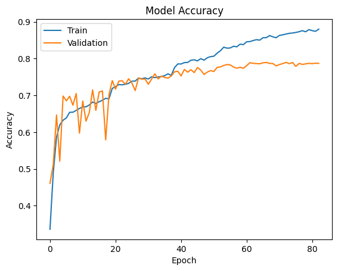

```python
# Model training evaluation
plt.plot(history_cnn_functional_model.history['accuracy'])
plt.plot(history_cnn_functional_model.history['val_accuracy'])
plt.title('Model Accuracy')
plt.ylabel('Accuracy')
plt.xlabel('Epoch')
plt.legend(['Train', 'Validation'], loc='upper left')
plt.show()
```

```python
# Load the model from G-drive
cnn_functional_model_save_path = '/content/gdrive/MyDrive/Data Science/Capstone/cnn_functional_model.keras'
cnn_functional_model = keras.models.load_model(cnn_functional_model_save_path)
```

```python
train_loss, train_accuracy = cnn_functional_model.evaluate(train_mapdataset, verbose=2)
print(f"Train Loss: {train_loss:.4f}")
print(f"Train Accuracy: {train_accuracy:.4f}")

val_loss, val_accuracy = cnn_functional_model.evaluate(val_mapdataset, verbose=2)
print(f"Validation Loss: {val_loss:.4f}")
print(f"Validation Accuracy: {val_accuracy:.4f}")

test_loss, test_accuracy = cnn_functional_model.evaluate(test_mapdataset, verbose=2)
print(f"Test Loss: {test_loss:.4f}")
print(f"Test Accuracy: {test_accuracy:.4f}")
```

```
473/473 - 6s - 12ms/step - accuracy: 0.9371 - loss: 0.2981
Train Loss: 0.2981
Train Accuracy: 0.9371
10/10 - 4s - 402ms/step - accuracy: 0.7898 - loss: 0.7841
Validation Loss: 0.7841
Validation Accuracy: 0.7898
1/1 - 3s - 3s/step - accuracy: 0.8516 - loss: 0.6588
Test Loss: 0.6588
Test Accuracy: 0.8516
```

```python
from sklearn.metrics import f1_score, classification_report

test_true_labels = []

# to use sklearn f1_score, we need to extract the y/true labels
for images, labels in test_mapdataset:
    # Convert the TensorFlow tensor of one-hot encoded labels to a NumPy array
    labels_numpy = labels.numpy()
    labels_int = np.argmax(labels_numpy, axis=1) # argmax the array to get the int label value
    test_true_labels.extend(labels_int)

y_pred_probs_test = cnn_functional_model.predict(test_mapdataset)
y_pred_test_cnn_functional = np.argmax(y_pred_probs_test, axis=1)

f1 = f1_score(test_true_labels, y_pred_test_cnn_functional, average='weighted') # 'weighted' adjusts for the distribution imbalance between classes
print(f"F1 Score: {f1:.4f}")

# And generate a classification report
print(classification_report(test_true_labels, y_pred_test_cnn_functional))
```

```
1/1 ━━━━━━━━━━━━━━━━━━━━ 1s 942ms/step
F1 Score: 0.8544
              precision    recall  f1-score   support

           0       1.00      0.84      0.92        32
           1       0.70      0.88      0.78        32
           2       0.83      0.75      0.79        32
           3       0.94      0.94      0.94        32

    accuracy                           0.85       128
   macro avg       0.87      0.85      0.85       128
weighted avg       0.87      0.85      0.85       128
```

```python
get_inference_time(cnn_functional_model, test_mapdataset)
```

```
Starting sequential unbatched inference on 128 images with cnn_functional_model
------------------------------------------------------------
Mean inference time per image: 67.14 ms
```

**Observations and Insights: Complex CNN Architecture**

[output not shown]

We have winner, `cnn_functional_model` outperforms `cnn_model_3_rgb` and the transfer learning models.

`85.16%` accuracy (on test) and an F1 score of `0.8544` will be the targets to beat the later models.

### **Model Building**

Let's go one last step further to try to get better results with data augmentation. Since we know using 3 channels can give us better results, we'll train with the rgb dataset.

```python
# Clearing backend
from keras import backend
backend.clear_session()

# Reset the random seed
import random
np.random.seed(42)
random.seed(42)
tf.random.set_seed(42)
```

```python
# Model with Data augmentation
from keras.models import Model, Sequential
from keras import layers
from keras.layers import Input, GlobalAveragePooling2D, MaxPooling2D, Dropout, Dense, LeakyReLU, BatchNormalization
from keras.regularizers import l2

# Define the data augmentation pipeline
data_augmentation = Sequential([
    layers.RandomFlip("horizontal"),
    layers.RandomRotation(0.02, fill_mode='nearest'),
    layers.RandomZoom(0.05, fill_mode='nearest'),
    layers.RandomContrast(0.1),
    layers.RandomTranslation(0.1, 0.1, fill_mode='nearest')
])

block_dropout_rate = 0.4
dense_dropout_rate = 0.5

# Define the input layer and change to rgb (3 channels)
inputs = Input(shape=(48, 48, 3))

# Data augmentation as the first step for training data only
x = data_augmentation(inputs)

# 1st convolutional block
x = conv_block(inputs, num_filters=(16, 32))
x = MaxPooling2D(pool_size=(2, 2))(x)
x = Dropout(block_dropout_rate)(x)

# 2nd convolutional block
x = conv_block(x, num_filters=(32, 64))
x = MaxPooling2D(pool_size=(2, 2))(x)
x = Dropout(block_dropout_rate)(x)

# 3rd convolutional block
x = conv_block(x, num_filters=(64, 128))
x = MaxPooling2D(pool_size=(2, 2))(x)
x = Dropout(block_dropout_rate)(x)

# 4th convolutional block
x = conv_block(x, num_filters=(128, 256))
x = MaxPooling2D(pool_size=(2, 2))(x)
x = Dropout(block_dropout_rate)(x)

# 5th convolutional block
x = conv_block(x, num_filters=(256, 512))
x = Dropout(block_dropout_rate)(x)

x = GlobalAveragePooling2D()(x)

x = Dense(64,
          kernel_initializer=he_normal_init,
          kernel_regularizer=l2(reg_strength))(x)
x = BatchNormalization()(x)
x = LeakyReLU(alpha=0.1)(x)
x = Dropout(dense_dropout_rate)(x)

outputs = Dense(4, activation='softmax', kernel_initializer=he_normal_init)(x)

data_augmented_cnn = Model(inputs=inputs, outputs=outputs, name="data_augmented_cnn")

data_augmented_cnn.summary()
```

```
Model: "data_augmented_cnn"
```

```
┏━━━━━━━━━━━━━━━━━━━━━━━━━━━━━━━━━┳━━━━━━━━━━━━━━━━━━━━━━━━┳━━━━━━━━━━━━━━━┓
┃ Layer (type)                    ┃ Output Shape           ┃       Param # ┃
┡━━━━━━━━━━━━━━━━━━━━━━━━━━━━━━━━━╇━━━━━━━━━━━━━━━━━━━━━━━━╇━━━━━━━━━━━━━━━┩
│ input_layer (InputLayer)        │ (None, 48, 48, 3)      │             0 │
├─────────────────────────────────┼────────────────────────┼───────────────┤
│ conv2d (Conv2D)                 │ (None, 48, 48, 16)     │           448 │
├─────────────────────────────────┼────────────────────────┼───────────────┤
│ batch_normalization             │ (None, 48, 48, 16)     │            64 │
│ (BatchNormalization)            │                        │               │
├─────────────────────────────────┼────────────────────────┼───────────────┤
│ leaky_re_lu (LeakyReLU)         │ (None, 48, 48, 16)     │             0 │
├─────────────────────────────────┼────────────────────────┼───────────────┤
│ conv2d_1 (Conv2D)               │ (None, 48, 48, 32)     │         4,640 │
├─────────────────────────────────┼────────────────────────┼───────────────┤
│ batch_normalization_1           │ (None, 48, 48, 32)     │           128 │
│ (BatchNormalization)            │                        │               │
├─────────────────────────────────┼────────────────────────┼───────────────┤
│ leaky_re_lu_1 (LeakyReLU)       │ (None, 48, 48, 32)     │             0 │
├─────────────────────────────────┼────────────────────────┼───────────────┤
│ max_pooling2d (MaxPooling2D)    │ (None, 24, 24, 32)     │             0 │
├─────────────────────────────────┼────────────────────────┼───────────────┤
│ dropout (Dropout)               │ (None, 24, 24, 32)     │             0 │
├─────────────────────────────────┼────────────────────────┼───────────────┤
│ conv2d_2 (Conv2D)               │ (None, 24, 24, 32)     │         9,248 │
├─────────────────────────────────┼────────────────────────┼───────────────┤
│ batch_normalization_2           │ (None, 24, 24, 32)     │           128 │
│ (BatchNormalization)            │                        │               │
├─────────────────────────────────┼────────────────────────┼───────────────┤
│ leaky_re_lu_2 (LeakyReLU)       │ (None, 24, 24, 32)     │             0 │
├─────────────────────────────────┼────────────────────────┼───────────────┤
│ conv2d_3 (Conv2D)               │ (None, 24, 24, 64)     │        18,496 │
├─────────────────────────────────┼────────────────────────┼───────────────┤
│ batch_normalization_3           │ (None, 24, 24, 64)     │           256 │
│ (BatchNormalization)            │                        │               │
├─────────────────────────────────┼────────────────────────┼───────────────┤
│ leaky_re_lu_3 (LeakyReLU)       │ (None, 24, 24, 64)     │             0 │
├─────────────────────────────────┼────────────────────────┼───────────────┤
│ max_pooling2d_1 (MaxPooling2D)  │ (None, 12, 12, 64)     │             0 │
├─────────────────────────────────┼────────────────────────┼───────────────┤
│ dropout_1 (Dropout)             │ (None, 12, 12, 64)     │             0 │
```

[output cut: 52 more lines]

```
├─────────────────────────────────┼────────────────────────┼───────────────┤
│ global_average_pooling2d        │ (None, 512)            │             0 │
│ (GlobalAveragePooling2D)        │                        │               │
├─────────────────────────────────┼────────────────────────┼───────────────┤
│ dense (Dense)                   │ (None, 64)             │        32,832 │
├─────────────────────────────────┼────────────────────────┼───────────────┤
│ batch_normalization_10          │ (None, 64)             │           256 │
│ (BatchNormalization)            │                        │               │
├─────────────────────────────────┼────────────────────────┼───────────────┤
│ leaky_re_lu_10 (LeakyReLU)      │ (None, 64)             │             0 │
├─────────────────────────────────┼────────────────────────┼───────────────┤
│ dropout_5 (Dropout)             │ (None, 64)             │             0 │
├─────────────────────────────────┼────────────────────────┼───────────────┤
│ dense_1 (Dense)                 │ (None, 4)              │           260 │
└─────────────────────────────────┴────────────────────────┴───────────────┘
```

```
 Total params: 2,395,908 (9.14 MB)
```

```
 Trainable params: 2,392,804 (9.13 MB)
```

```
 Non-trainable params: 3,104 (12.12 KB)
```

```python
# Using AdamW Optimizer
from keras.optimizers import AdamW

opt = AdamW(learning_rate=0.001)

# Compile model
data_augmented_cnn.compile(
    optimizer=opt,
    loss='categorical_crossentropy',
    metrics=['accuracy']
)
```

```python
from keras.callbacks import EarlyStopping, ReduceLROnPlateau, ModelCheckpoint

# --- Define Callbacks ---

early_stopping = EarlyStopping(
    monitor='val_accuracy',      # Monitor validation accuracy
    patience=10,                 # stop training if the validation metric has failed to improve for 10 consecutive epochs
    restore_best_weights=True    # Restore the best model weights
)

reduce_lr_on_plateau = ReduceLROnPlateau(
    monitor='val_accuracy',     # Monitor validation accuracy
    factor=0.5,                 # Reduce the learning rate by a factor of 50%
    patience=5,                 # Lower than the early stopping patience to lower LR before stopping
    min_lr=1e-6,                # Set a lower bound for the learning rate
    verbose=1,                  # Print a message when the learning rate is reduced
    mode='max'                  # The goal is to maximize the monitored metric (val_accuracy)
)

# Save model to Google Drive
data_augmented_cnn_save_path = '/content/gdrive/MyDrive/Data Science/Capstone/data_augmented_cnn.keras'

# ModelCheckpoint: Saves the best model based on validation accuracy
model_checkpoint = ModelCheckpoint(
    filepath=data_augmented_cnn_save_path,       # Name of the file to save the model to
    monitor='val_accuracy',                      # Monitor validation accuracy
    save_best_only=True,                         # Only save the best model found so far
    mode='max'                                   # 'max' because we want to maximize accuracy
)

# train with callbacks
history_data_augmented_cnn = data_augmented_cnn.fit(
    train_mapdataset_rgb,
    epochs=100,
    class_weight=class_weights_dict,
    validation_data=val_mapdataset_rgb,
    callbacks=[early_stopping, reduce_lr_on_plateau, model_checkpoint]
)
```

```
473/473 ━━━━━━━━━━━━━━━━━━━━ 43s 44ms/step - accuracy: 0.2953 - loss: 4.4940 - val_accuracy: 0.4477 - val_loss: 2.9327 - learning_rate: 0.0010
473/473 ━━━━━━━━━━━━━━━━━━━━ 8s 16ms/step - accuracy: 0.4552 - loss: 2.6388 - val_accuracy: 0.6072 - val_loss: 1.7583 - learning_rate: 0.0010
473/473 ━━━━━━━━━━━━━━━━━━━━ 7s 15ms/step - accuracy: 0.5713 - loss: 1.7241 - val_accuracy: 0.6506 - val_loss: 1.3663 - learning_rate: 0.0010
473/473 ━━━━━━━━━━━━━━━━━━━━ 7s 15ms/step - accuracy: 0.6042 - loss: 1.3721 - val_accuracy: 0.6094 - val_loss: 1.2783 - learning_rate: 0.0010
473/473 ━━━━━━━━━━━━━━━━━━━━ 8s 16ms/step - accuracy: 0.6267 - loss: 1.2326 - val_accuracy: 0.5911 - val_loss: 1.3301 - learning_rate: 0.0010
473/473 ━━━━━━━━━━━━━━━━━━━━ 7s 14ms/step - accuracy: 0.6356 - loss: 1.1767 - val_accuracy: 0.4828 - val_loss: 1.5834 - learning_rate: 0.0010
473/473 ━━━━━━━━━━━━━━━━━━━━ 8s 16ms/step - accuracy: 0.6461 - loss: 1.1422 - val_accuracy: 0.6717 - val_loss: 1.1069 - learning_rate: 0.0010
473/473 ━━━━━━━━━━━━━━━━━━━━ 7s 14ms/step - accuracy: 0.6527 - loss: 1.1157 - val_accuracy: 0.6219 - val_loss: 1.1366 - learning_rate: 0.0010
473/473 ━━━━━━━━━━━━━━━━━━━━ 8s 17ms/step - accuracy: 0.6513 - loss: 1.1168 - val_accuracy: 0.6548 - val_loss: 1.1381 - learning_rate: 0.0010
473/473 ━━━━━━━━━━━━━━━━━━━━ 7s 14ms/step - accuracy: 0.6434 - loss: 1.1335 - val_accuracy: 0.5943 - val_loss: 1.2195 - learning_rate: 0.0010
473/473 ━━━━━━━━━━━━━━━━━━━━ 7s 15ms/step - accuracy: 0.6725 - loss: 1.0803 - val_accuracy: 0.6550 - val_loss: 1.1178 - learning_rate: 0.0010
470/473 ━━━━━━━━━━━━━━━━━━━━ 0s 12ms/step - accuracy: 0.6615 - loss: 1.1034
Epoch 12: ReduceLROnPlateau reducing learning rate to 0.0005000000237487257.
473/473 ━━━━━━━━━━━━━━━━━━━━ 7s 14ms/step - accuracy: 0.6615 - loss: 1.1033 - val_accuracy: 0.6711 - val_loss: 1.0877 - learning_rate: 0.0010
473/473 ━━━━━━━━━━━━━━━━━━━━ 8s 16ms/step - accuracy: 0.6821 - loss: 1.0190 - val_accuracy: 0.6884 - val_loss: 0.9897 - learning_rate: 5.0000e-04
473/473 ━━━━━━━━━━━━━━━━━━━━ 7s 14ms/step - accuracy: 0.7020 - loss: 0.9626 - val_accuracy: 0.6319 - val_loss: 1.1962 - learning_rate: 5.0000e-04
473/473 ━━━━━━━━━━━━━━━━━━━━ 11s 15ms/step - accuracy: 0.6986 - loss: 0.9490 - val_accuracy: 0.7123 - val_loss: 0.9289 - learning_rate: 5.0000e-04
473/473 ━━━━━━━━━━━━━━━━━━━━ 8s 16ms/step - accuracy: 0.7104 - loss: 0.9268 - val_accuracy: 0.7241 - val_loss: 0.8996 - learning_rate: 5.0000e-04
473/473 ━━━━━━━━━━━━━━━━━━━━ 7s 15ms/step - accuracy: 0.7136 - loss: 0.9150 - val_accuracy: 0.7292 - val_loss: 0.8850 - learning_rate: 5.0000e-04
473/473 ━━━━━━━━━━━━━━━━━━━━ 10s 14ms/step - accuracy: 0.7145 - loss: 0.9268 - val_accuracy: 0.7159 - val_loss: 0.9295 - learning_rate: 5.0000e-04
473/473 ━━━━━━━━━━━━━━━━━━━━ 8s 17ms/step - accuracy: 0.7214 - loss: 0.8913 - val_accuracy: 0.7378 - val_loss: 0.8441 - learning_rate: 5.0000e-04
473/473 ━━━━━━━━━━━━━━━━━━━━ 7s 14ms/step - accuracy: 0.7258 - loss: 0.8849 - val_accuracy: 0.7344 - val_loss: 0.8545 - learning_rate: 5.0000e-04
473/473 ━━━━━━━━━━━━━━━━━━━━ 8s 16ms/step - accuracy: 0.7207 - loss: 0.8750 - val_accuracy: 0.7304 - val_loss: 0.8674 - learning_rate: 5.0000e-04
473/473 ━━━━━━━━━━━━━━━━━━━━ 7s 14ms/step - accuracy: 0.7247 - loss: 0.8737 - val_accuracy: 0.7304 - val_loss: 0.8934 - learning_rate: 5.0000e-04
473/473 ━━━━━━━━━━━━━━━━━━━━ 8s 16ms/step - accuracy: 0.7264 - loss: 0.8737 - val_accuracy: 0.7384 - val_loss: 0.8502 - learning_rate: 5.0000e-04
473/473 ━━━━━━━━━━━━━━━━━━━━ 7s 15ms/step - accuracy: 0.7276 - loss: 0.8694 - val_accuracy: 0.7328 - val_loss: 0.8891 - learning_rate: 5.0000e-04
473/473 ━━━━━━━━━━━━━━━━━━━━ 7s 15ms/step - accuracy: 0.7365 - loss: 0.8522 - val_accuracy: 0.7079 - val_loss: 0.8905 - learning_rate: 5.0000e-04
473/473 ━━━━━━━━━━━━━━━━━━━━ 7s 15ms/step - accuracy: 0.7165 - loss: 0.9036 - val_accuracy: 0.7344 - val_loss: 0.8971 - learning_rate: 5.0000e-04
473/473 ━━━━━━━━━━━━━━━━━━━━ 7s 14ms/step - accuracy: 0.7356 - loss: 0.8444 - val_accuracy: 0.7332 - val_loss: 0.8894 - learning_rate: 5.0000e-04
471/473 ━━━━━━━━━━━━━━━━━━━━ 0s 14ms/step - accuracy: 0.7484 - loss: 0.8342
Epoch 28: ReduceLROnPlateau reducing learning rate to 0.0002500000118743628.
473/473 ━━━━━━━━━━━━━━━━━━━━ 8s 16ms/step - accuracy: 0.7484 - loss: 0.8342 - val_accuracy: 0.7161 - val_loss: 0.9019 - learning_rate: 5.0000e-04
473/473 ━━━━━━━━━━━━━━━━━━━━ 7s 15ms/step - accuracy: 0.7545 - loss: 0.8077 - val_accuracy: 0.7521 - val_loss: 0.8155 - learning_rate: 2.5000e-04
473/473 ━━━━━━━━━━━━━━━━━━━━ 8s 16ms/step - accuracy: 0.7614 - loss: 0.7815 - val_accuracy: 0.7705 - val_loss: 0.7578 - learning_rate: 2.5000e-04
473/473 ━━━━━━━━━━━━━━━━━━━━ 10s 16ms/step - accuracy: 0.7735 - loss: 0.7535 - val_accuracy: 0.7577 - val_loss: 0.7776 - learning_rate: 2.5000e-04
473/473 ━━━━━━━━━━━━━━━━━━━━ 10s 14ms/step - accuracy: 0.7696 - loss: 0.7399 - val_accuracy: 0.7667 - val_loss: 0.7574 - learning_rate: 2.5000e-04
473/473 ━━━━━━━━━━━━━━━━━━━━ 7s 15ms/step - accuracy: 0.7773 - loss: 0.7287 - val_accuracy: 0.7587 - val_loss: 0.7742 - learning_rate: 2.5000e-04
473/473 ━━━━━━━━━━━━━━━━━━━━ 10s 15ms/step - accuracy: 0.7774 - loss: 0.7306 - val_accuracy: 0.7340 - val_loss: 0.8557 - learning_rate: 2.5000e-04
473/473 ━━━━━━━━━━━━━━━━━━━━ 0s 13ms/step - accuracy: 0.7733 - loss: 0.7229
Epoch 35: ReduceLROnPlateau reducing learning rate to 0.0001250000059371814.
```

[output cut: 56 more lines]

```
473/473 ━━━━━━━━━━━━━━━━━━━━ 8s 17ms/step - accuracy: 0.8703 - loss: 0.4412 - val_accuracy: 0.7898 - val_loss: 0.7819 - learning_rate: 7.8125e-06
473/473 ━━━━━━━━━━━━━━━━━━━━ 7s 14ms/step - accuracy: 0.8729 - loss: 0.4507 - val_accuracy: 0.7874 - val_loss: 0.7814 - learning_rate: 7.8125e-06
473/473 ━━━━━━━━━━━━━━━━━━━━ 8s 18ms/step - accuracy: 0.8721 - loss: 0.4396 - val_accuracy: 0.7824 - val_loss: 0.7844 - learning_rate: 7.8125e-06
473/473 ━━━━━━━━━━━━━━━━━━━━ 7s 14ms/step - accuracy: 0.8760 - loss: 0.4329 - val_accuracy: 0.7882 - val_loss: 0.7846 - learning_rate: 7.8125e-06
473/473 ━━━━━━━━━━━━━━━━━━━━ 8s 16ms/step - accuracy: 0.8695 - loss: 0.4395 - val_accuracy: 0.7870 - val_loss: 0.7852 - learning_rate: 7.8125e-06
471/473 ━━━━━━━━━━━━━━━━━━━━ 0s 13ms/step - accuracy: 0.8722 - loss: 0.4392
Epoch 88: ReduceLROnPlateau reducing learning rate to 3.906250185536919e-06.
473/473 ━━━━━━━━━━━━━━━━━━━━ 7s 14ms/step - accuracy: 0.8723 - loss: 0.4391 - val_accuracy: 0.7882 - val_loss: 0.7866 - learning_rate: 7.8125e-06
473/473 ━━━━━━━━━━━━━━━━━━━━ 7s 16ms/step - accuracy: 0.8763 - loss: 0.4337 - val_accuracy: 0.7878 - val_loss: 0.7879 - learning_rate: 3.9063e-06
473/473 ━━━━━━━━━━━━━━━━━━━━ 6s 14ms/step - accuracy: 0.8778 - loss: 0.4246 - val_accuracy: 0.7854 - val_loss: 0.7891 - learning_rate: 3.9063e-06
473/473 ━━━━━━━━━━━━━━━━━━━━ 7s 15ms/step - accuracy: 0.8762 - loss: 0.4376 - val_accuracy: 0.7870 - val_loss: 0.7885 - learning_rate: 3.9063e-06
473/473 ━━━━━━━━━━━━━━━━━━━━ 7s 14ms/step - accuracy: 0.8786 - loss: 0.4275 - val_accuracy: 0.7858 - val_loss: 0.7917 - learning_rate: 3.9063e-06
472/473 ━━━━━━━━━━━━━━━━━━━━ 0s 14ms/step - accuracy: 0.8754 - loss: 0.4356
Epoch 93: ReduceLROnPlateau reducing learning rate to 1.9531250927684596e-06.
473/473 ━━━━━━━━━━━━━━━━━━━━ 7s 15ms/step - accuracy: 0.8754 - loss: 0.4356 - val_accuracy: 0.7862 - val_loss: 0.7855 - learning_rate: 3.9063e-06
```

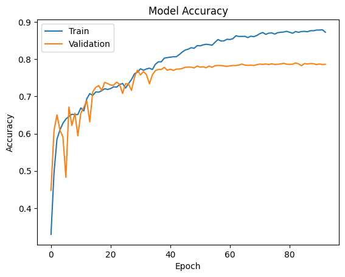

```python
# Model training evaluation
plt.plot(history_data_augmented_cnn.history['accuracy'])
plt.plot(history_data_augmented_cnn.history['val_accuracy'])
plt.title('Model Accuracy')
plt.ylabel('Accuracy')
plt.xlabel('Epoch')
plt.legend(['Train', 'Validation'], loc='upper left')
plt.show()
```

```python
# Load the model from G-drive
data_augmented_cnn_save_path = '/content/gdrive/MyDrive/Data Science/Capstone/data_augmented_cnn.keras'
data_augmented_cnn = keras.models.load_model(data_augmented_cnn_save_path)
```

```python
train_loss, train_accuracy = data_augmented_cnn.evaluate(train_mapdataset_rgb, verbose=2)
print(f"Train Loss: {train_loss:.4f}")
print(f"Train Accuracy: {train_accuracy:.4f}")

val_loss, val_accuracy = data_augmented_cnn.evaluate(val_mapdataset_rgb, verbose=2)
print(f"Validation Loss: {val_loss:.4f}")
print(f"Validation Accuracy: {val_accuracy:.4f}")

test_loss, test_accuracy = data_augmented_cnn.evaluate(test_mapdataset_rgb, verbose=2)
print(f"Test Loss: {test_loss:.4f}")
print(f"Test Accuracy: {test_accuracy:.4f}")
```

```
473/473 - 5s - 11ms/step - accuracy: 0.9459 - loss: 0.2768
Train Loss: 0.2768
Train Accuracy: 0.9459
10/10 - 1s - 59ms/step - accuracy: 0.7898 - loss: 0.7819
Validation Loss: 0.7819
Validation Accuracy: 0.7898
1/1 - 2s - 2s/step - accuracy: 0.8438 - loss: 0.6031
Test Loss: 0.6031
Test Accuracy: 0.8438
```

```python
from sklearn.metrics import f1_score, classification_report

test_true_labels = []

# to use sklearn f1_score, we need to extract the y/true labels
for images, labels in test_mapdataset_rgb:
    # Convert the TensorFlow tensor of one-hot encoded labels to a NumPy array
    labels_numpy = labels.numpy()
    labels_int = np.argmax(labels_numpy, axis=1) # argmax the array to get the int label value
    test_true_labels.extend(labels_int)

y_pred_probs_test = data_augmented_cnn.predict(test_mapdataset_rgb)
y_pred_test_data_augmented_cnn = np.argmax(y_pred_probs_test, axis=1)

f1 = f1_score(test_true_labels, y_pred_test_data_augmented_cnn, average='weighted') # 'weighted' adjusts for the distribution imbalance between classes
print(f"F1 Score: {f1:.4f}")

# And generate a classification report
print(classification_report(test_true_labels, y_pred_test_data_augmented_cnn))
```

```
1/1 ━━━━━━━━━━━━━━━━━━━━ 1s 1s/step
F1 Score: 0.8460
              precision    recall  f1-score   support

           0       0.97      0.91      0.94        32
           1       0.71      0.78      0.75        32
           2       0.75      0.75      0.75        32
           3       0.97      0.94      0.95        32

    accuracy                           0.84       128
   macro avg       0.85      0.84      0.85       128
weighted avg       0.85      0.84      0.85       128
```

```python
get_inference_time(data_augmented_cnn, test_mapdataset_rgb)
```

```
Starting sequential unbatched inference on 128 images with data_augmented_cnn
------------------------------------------------------------
Mean inference time per image: 58.54 ms
```

### **Final Model: cnn_functional_model**

[output not shown]

Unfortunately the data augmentated model, `data_augmented_cnn` did not perform better than `cnn_functional_model`.

Thus the final selected model will be: `cnn_functional_model`

### **Plotting the Confusion Matrix for the chosen final model**

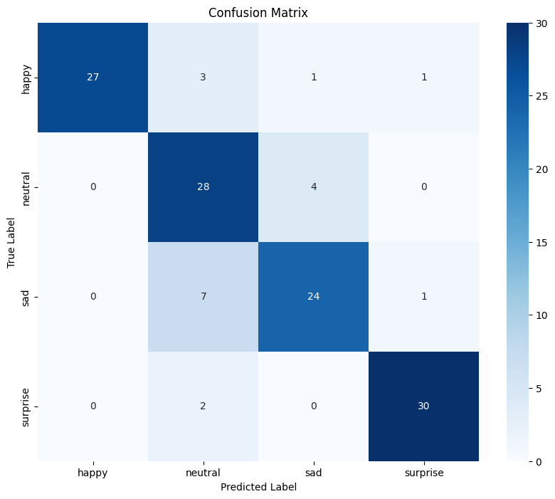

```python
from sklearn.metrics import confusion_matrix

cm = confusion_matrix(y_true=test_true_labels, y_pred=y_pred_test_cnn_functional)

# 5. Plot the confusion matrix
plt.figure(figsize=(10, 8))
sns.heatmap(cm, annot=True, fmt='d', cmap='Blues', xticklabels=class_names, yticklabels=class_names)
plt.title('Confusion Matrix')
plt.ylabel('True Label')
plt.xlabel('Predicted Label')
plt.show()
```

**Observations and Insights: Confusion matrix for cnn_functional_model**

Overall the model is making accurate predictions; however the model can mistake 'sad' for 'neutral' and vice versa.

This isn't really unexpected as we can observe from our exploratory data analysis that unless the subject is crying, it is hard to differentiate 'sad' from 'neutral'.

## **Conclusion:**

Our custom more complex CNN: `cnn_functional_model` is the best performing and the one we should use.

- Note: We have another larger model with higher accuracy at the end that we can also use but the filesize and memory usage will be significantly higher.

```python
# Bonus: testing the model on an image of my daughter

import matplotlib.pyplot as plt
from keras.utils import load_img, img_to_array

img = load_img(
    "/content/gdrive/My Drive/Data Science/Capstone/Rina_48x48.jpg",
    color_mode='grayscale',
    target_size=(48, 48)
)

img_rgb = load_img(
    "/content/gdrive/My Drive/Data Science/Capstone/Rina_48x48.jpg",
    color_mode='rgb',
    target_size=(48, 48)
)

# convert to numpy array
img_array = img_to_array(img)

img_array = np.expand_dims(img_array, axis=0)

# normalize
normalized_img_array = img_array / 255.0

predictions = cnn_functional_model.predict(normalized_img_array)
predicted_class_index = np.argmax(predictions, axis=1)[0]
predicted_emotion = emotion_classes[predicted_class_index]

plt.figure(figsize=(1, 1))
plt.title(f"Predicted Emotion: {predicted_emotion}")
plt.imshow(img_rgb)
plt.axis('off')
plt.show()
```

[output not shown]

```
1/1 ━━━━━━━━━━━━━━━━━━━━ 0s 158ms/step
```

### **Refined insights**:

- *What are the most meaningful insights from the data relevant to the problem?*

  *1. Behaviour of the two colorscales: Grayscale vs RGB*

  We were able to get better results with a model when we enabled 3 channels (RGB for our dataset even though all the images were grayscale).

  We were restricted to using grayscale images for the final model but if we have access to all 3 channels. We could introduce the Squeeze and Excitation (SE) blocks from the EfficientNet architecture and possibly improve performance.

  *2. Does transfer learning help to improve the model performance?*

  Transfer learning didn't give us good results up to this point (this will change at the end of the report). If we were trying to detect and classify objects in images, the base models would likely have been more suited to the purpose.

### **Comparison of various techniques and their relative performance**:

#### **1. Transfer Learning**

- Transfer learning did not yield great results and was costly and time consuming to train because the base models were much larger.

  The intuition behind *"why this did not perform well?"* (despite the base models being very powerful) is that the base models (VGG16, ResNetV2 and EfficientNet) are not trained specifically for FER (Facial Emotion Recognition). Whereas our custom trained models are train on a dataset that is nothing but images of people displaying the 4 emotions we want to classify.

  We used `GlobalAveragePooling2D` with the transfer learning base models. It calculates the average value of each feature map and uses that single value as a representative summary for that map. This reduces the size of the final output vector for the Dense layer that comes next.

  I brought this improvement over to the final model which allowed me to use a pyramid of larger and larger Conv2D layers.

#### **2. Data Augmentation**

- In theory, by making slight adjustments to the training images, the model will be trained to better generalize.

  I tested adjusting the images with 5 transformations:
  - RandomFlip("horizontal")
  - RandomRotation(0.1, fill_mode='nearest')
  - RandomZoom(0.1, fill_mode='nearest')
  - RandomContrast(0.1),
  - RandomTranslation(0.1, 0.1, fill_mode='nearest')

  The training looked promising; it was a lot more stable and both train and validation accuracy increased. Unfortunately, validation accuracy reach a similar plateau and overall the model was performed worse than `cnn_functional_model`.

  A possible for the validation accuracy plateau with both `cnn_functional_model` and the data_augmented model is the validation dataset. It may be lacking samples with certain features that are only present in the train dataset.

#### **3. Hyperparameter Choice**

- - **More neurons for classification head:** I experimented with 256, 128 and 64 neurons for the first Dense layer. The last convolution layer had 512 filters so we have a larger Dense layer than earlier simpler CNN models to increase the learning capacity.

    We don't need exactly 512 neurons because `GlobalAveragePooling2D` reduces the need for that.
  - **Higher dropout rates:** Increasing the size of the first Dense layer increases the network's capacity for learning. However, this will increase the the risk of overfitting so the more aggressive dropout helped to keep that in check.

#### **4. Potential Improvements**

- We could try an even more complex model with more convolutional layers if we introduce Residual blocks from the ResNetV2 architecture. This may be a good approach as the task (Facial Emotion Recognition) is complex does require the model to capture intricate and abstract features.

### **Operational costs**:

- **Training Costs:** We used a Colab Pro subscription 9.99 USD to get access to a dedicated Tesla T4 GPU instance. This was necessary to train the models in a good amount of time. (The transfer learning models would have taken too long on CPU and their training exceeded the free tier of Google Colab).

  For a 3 year committed use, this works out to 1,401.6 USD / year. This excludes the cost of the hosting VM (CPU and storage).

  Google Cloud Run also now offers GPU support if a more scalable and ondemand solution is preferred.

#### *This isn't the end of the report. We have one more thing to try:*

**Using a vision transformer that will get us to 96% accuracy.**

## Using a Vision Transformer

CNNs are not the only type of vision model. Vision Transformers are trained on massive amounts of data. Our data set is relatively small so by using transfer learning, we can take advantage of a vision transformer that was trained on a lot more data.

Because the vision transform we want to use is a Pytorch model (and there is no Tensorflow implementation) we will have to use Pytorch instead (or the weights will fail to load).

```python
from google.colab import drive
drive.mount('/content/gdrive')
```

```python
#  extracts all the files and folders to the main /content/ directory in Colab environment
# -o flag will force overwrite if the kernel is restarted
# -q flag to perform operation quietly to prevent output from filling the cell
!unzip -o -q "/content/gdrive/My Drive/Data Science/Capstone/Facial_emotion_images.zip" -d "/content/"
```

```python
import torch
import numpy as np
import random
import os

def set_seed(seed):
    torch.manual_seed(seed)
    np.random.seed(seed)
    random.seed(seed)
    # Ensure all operations are deterministic for reproducibility
    # This might have a slight performance cost
    torch.backends.cudnn.deterministic = True
    torch.backends.cudnn.benchmark = False

# Call the function at the beginning of your script
set_seed(42)
```

```python
# TFViTModel cannot be used because the TensorFlow implementation of ViT in the transformers library is deprecated and is failing to load a PyTorch model's weights
from transformers import ViTModel, ViTConfig

# The model checkpoint to use
model_name = 'mo-thecreator/vit-Facial-Expression-Recognition'

# Load the base ViT model without the classification head
# This downloads the pre-trained weights
vit_base = ViTModel.from_pretrained(model_name)
```

```
Some weights of ViTModel were not initialized from the model checkpoint at mo-thecreator/vit-Facial-Expression-Recognition and are newly initialized: ['pooler.dense.bias', 'pooler.dense.weight']
You should probably TRAIN this model on a down-stream task to be able to use it for predictions and inference.
```

```python
# Use the image_processor to preprocess the dataset
import os
from torch.utils.data import Dataset, DataLoader
from transformers import AutoImageProcessor
from PIL import Image

# Load the image_processor
image_processor = AutoImageProcessor.from_pretrained(model_name, use_fast=True) # Use Rust based processor instead of Python processor

label_to_id = {'happy': 0, 'sad': 1, 'neutral': 2, 'surprise': 3}


class EmotionDataset(Dataset):
    def __init__(self, data_dir, image_processor, label_to_id):
        self.data_dir = data_dir
        self.image_processor = image_processor
        self.label_to_id = label_to_id
        self.image_paths = []
        self.labels = []

        # Walk through the directories to find images and infer labels
        for label_name, label_id in self.label_to_id.items():
            class_dir = os.path.join(self.data_dir, label_name)
            if os.path.isdir(class_dir):
                for img_name in os.listdir(class_dir):
                    if img_name.endswith(('jpg', 'png', 'jpeg')):
                        self.image_paths.append(os.path.join(class_dir, img_name))
                        self.labels.append(label_id)

    def __len__(self):
        return len(self.image_paths)

    def __getitem__(self, idx):
        # 1. Load image: The image is loaded from disk here.
        image = Image.open(self.image_paths[idx]).convert('RGB')
        label = self.labels[idx]

        # 2. Process image: The ViTImageProcessor is applied to the image.
        inputs = self.image_processor(images=image, return_tensors='pt')

        # 3. Return processed data: The processed tensor is returned.
        pixel_values = inputs['pixel_values'].squeeze(0)

        return {'pixel_values': pixel_values, 'labels': torch.tensor(label, dtype=torch.long)}


# Create the PyTorch Dataset and DataLoader
train_dataset = EmotionDataset('/content/Facial_emotion_images/train/', image_processor, label_to_id)
val_dataset = EmotionDataset('/content/Facial_emotion_images/validation/', image_processor, label_to_id)
test_dataset = EmotionDataset('/content/Facial_emotion_images/test/', image_processor, label_to_id)

train_dataloader = DataLoader(train_dataset, batch_size=32, shuffle=True, num_workers=2, pin_memory=True)
val_dataloader = DataLoader(val_dataset, batch_size=512, shuffle=False, num_workers=2, pin_memory=True)
test_dataloader = DataLoader(test_dataset, batch_size=128, shuffle=False, num_workers=2, pin_memory=True)

print("Train:")
for batch in train_dataloader:
     pixel_values = batch['pixel_values']
     labels = batch['labels']
     print(f"Batch pixel_values shape: {pixel_values.shape}")
     print(f"Batch labels shape: {labels.shape}")
     break
print("")

print("Validation:")
for batch in val_dataloader:
     pixel_values = batch['pixel_values']
     labels = batch['labels']
     print(f"Batch pixel_values shape: {pixel_values.shape}")
     print(f"Batch labels shape: {labels.shape}")
     break
print("")

print("Test:")
for batch in test_dataloader:
     pixel_values = batch['pixel_values']
     labels = batch['labels']
     print(f"Batch pixel_values shape: {pixel_values.shape}")
     print(f"Batch labels shape: {labels.shape}")
     break
```

```
Train:
Batch pixel_values shape: torch.Size([32, 3, 224, 224])
Batch labels shape: torch.Size([32])

Validation:
Batch pixel_values shape: torch.Size([512, 3, 224, 224])
Batch labels shape: torch.Size([512])

Test:
Batch pixel_values shape: torch.Size([128, 3, 224, 224])
Batch labels shape: torch.Size([128])
```

```python
from torch import nn

class CustomViT(nn.Module):
    def __init__(self, vit_base, num_labels):
        super(CustomViT, self).__init__()

        # Store the pre-trained ViT base model
        self.vit = vit_base

        # Instead of a final feature map from a convolutional layer, a ViT produces a single feature vector which summarizes the image
        # Custom classification head
        self.classifier = nn.Sequential(
            nn.Linear(self.vit.config.hidden_size, 64),
            nn.LeakyReLU(negative_slope=0.01),
            nn.Dropout(0.3),
            nn.Linear(64, num_labels)
        )

    def forward(self, pixel_values):
        # Pass the input through the ViT base model
        outputs = self.vit(pixel_values=pixel_values, interpolate_pos_encoding=True) # handle inputs that may be of a different resolution

        # Get the pooled output, which is the representation of the [CLS] token
        pooled_output = outputs.pooler_output

        # Pass the pooled output through your custom classifier head
        logits = self.classifier(pooled_output)

        return logits

vit_model = CustomViT(vit_base, num_labels=4)

# Freeze the parameters of the base ViT model
for param in vit_model.vit.parameters():
    param.requires_grad = False

# Verify that the model's new classifier head is trainable
for name, param in vit_model.named_parameters():
    print(f"Parameter: {name}, requires_grad: {param.requires_grad}")
```

[output not shown]

[output cut: 149 more lines]

[output not shown]

```python
import torch.optim as optim
import torch.optim.lr_scheduler as lr_scheduler

# Set up the loss function and optimizer
criterion = nn.CrossEntropyLoss()
optimizer = optim.Adam(vit_model.parameters(), lr=1e-4)

# Set up the learning rate scheduler
scheduler = lr_scheduler.ReduceLROnPlateau(
    optimizer,
    mode='max',          # Reduce LR when the monitored metric (val_accuracy) stops increasing
    factor=0.1,          # Factor by which the learning rate is reduced
    patience=3           # Number of epochs with no improvement before reducing LR
)

# Early stopping parameters
patience = 6             # Number of epochs to wait for improvement before stopping
early_stopping_counter = 0
best_val_accuracy = 0.0

# Move model to GPU if available
device = torch.device('cuda' if torch.cuda.is_available() else 'cpu')
vit_model.to(device)
print(f'Using device: {device}')
```

```
Using device: cuda
```

```python
from torch.amp import GradScaler, autocast

# Create a GradScaler once at the beginning of training.
scaler = GradScaler()

num_epochs = 20 # Can be larger as early stopping will manage the training length

model_save_path = '/content/gdrive/My Drive/Data Science/Capstone/vit_model.pth'

for epoch in range(num_epochs):
    print(f"Epoch {epoch + 1}/{num_epochs}")

    # Training phase
    vit_model.train()
    running_loss = 0.0
    for batch in train_dataloader:

        # Forward pass with autocast
        with autocast(device_type='cuda'):
            pixel_values = batch['pixel_values'].to(device)
            labels = batch['labels'].to(device)
            outputs = vit_model(pixel_values)
            loss = criterion(outputs, labels)

        # Backward pass with scaled loss
        optimizer.zero_grad()
        scaler.scale(loss).backward()

        # Optimizer step with scaled gradients
        scaler.step(optimizer)

        # Update the scale for the next iteration
        scaler.update()

        running_loss += loss.item() * pixel_values.size(0)

    train_loss = running_loss / len(train_dataset)

    # Validation phase
    vit_model.eval()
    val_loss = 0.0
    correct_preds = 0
    total_preds = 0

    with torch.no_grad():
        for batch in val_dataloader:
            pixel_values = batch['pixel_values'].to(device)
            labels = batch['labels'].to(device)

            outputs = vit_model(pixel_values)
            loss = criterion(outputs, labels)

            val_loss += loss.item() * pixel_values.size(0)

            _, predicted = torch.max(outputs, 1)
            total_preds += labels.size(0)
            correct_preds += (predicted == labels).sum().item()

    val_accuracy = correct_preds / total_preds
    val_loss /= len(val_dataset)
    print(f"Train Loss: {train_loss:.4f}, Val Loss: {val_loss:.4f}, Val Accuracy: {val_accuracy:.4f}")

    # Step the learning rate scheduler
    # This checks if the validation accuracy has improved
    scheduler.step(val_accuracy)

    # Check for early stopping
    if val_accuracy > best_val_accuracy:
        best_val_accuracy = val_accuracy
        early_stopping_counter = 0

        # Save checkpoint for the best model
        checkpoint = {
            'epoch': epoch,
            'model_state_dict': vit_model.state_dict(),
            'optimizer_state_dict': optimizer.state_dict(),
            'scheduler_state_dict': scheduler.state_dict(),
            'best_val_accuracy': best_val_accuracy,
        }
        torch.save(checkpoint, model_save_path)
        print("Saved best model checkpoint!")
    else:
        early_stopping_counter += 1
        print(f"Early stopping counter: {early_stopping_counter}/{patience}")
        if early_stopping_counter >= patience:
            print("Early stopping triggered! Training finished.")
            break

print("Training completed.")
```

```
Train Loss: 0.5088, Val Loss: 0.1846, Val Accuracy: 0.9510
Saved best model checkpoint!
Train Loss: 0.1657, Val Loss: 0.1467, Val Accuracy: 0.9528
Saved best model checkpoint!
Train Loss: 0.1457, Val Loss: 0.1418, Val Accuracy: 0.9538
Saved best model checkpoint!
Train Loss: 0.1408, Val Loss: 0.1415, Val Accuracy: 0.9538
Early stopping counter: 1/6
Train Loss: 0.1369, Val Loss: 0.1406, Val Accuracy: 0.9544
Saved best model checkpoint!
Train Loss: 0.1367, Val Loss: 0.1392, Val Accuracy: 0.9540
Early stopping counter: 1/6
Train Loss: 0.1340, Val Loss: 0.1396, Val Accuracy: 0.9544
Early stopping counter: 2/6
Train Loss: 0.1323, Val Loss: 0.1387, Val Accuracy: 0.9546
Saved best model checkpoint!
Train Loss: 0.1278, Val Loss: 0.1386, Val Accuracy: 0.9538
Early stopping counter: 1/6
Train Loss: 0.1295, Val Loss: 0.1381, Val Accuracy: 0.9534
Early stopping counter: 2/6
Train Loss: 0.1285, Val Loss: 0.1376, Val Accuracy: 0.9546
Early stopping counter: 3/6
Train Loss: 0.1276, Val Loss: 0.1385, Val Accuracy: 0.9542
Early stopping counter: 4/6
Train Loss: 0.1242, Val Loss: 0.1382, Val Accuracy: 0.9548
Saved best model checkpoint!
Train Loss: 0.1254, Val Loss: 0.1381, Val Accuracy: 0.9544
Early stopping counter: 1/6
Train Loss: 0.1249, Val Loss: 0.1380, Val Accuracy: 0.9542
Early stopping counter: 2/6
Train Loss: 0.1242, Val Loss: 0.1380, Val Accuracy: 0.9542
Early stopping counter: 3/6
Train Loss: 0.1239, Val Loss: 0.1379, Val Accuracy: 0.9542
Early stopping counter: 4/6
Train Loss: 0.1254, Val Loss: 0.1379, Val Accuracy: 0.9542
Early stopping counter: 5/6
Train Loss: 0.1256, Val Loss: 0.1379, Val Accuracy: 0.9542
Early stopping counter: 6/6
Early stopping triggered! Training finished.
Training completed.
```

```python
import torch

device = torch.device("cuda" if torch.cuda.is_available() else "cpu")

# Load the best model from the checkpoint
model_save_path = '/content/gdrive/My Drive/Data Science/Capstone/vit_model.pth'
checkpoint = torch.load(model_save_path)
vit_model.load_state_dict(checkpoint['model_state_dict'])
vit_model.to(device)

vit_model.eval() # set evaluation mode
```

```
CustomViT(
  (vit): ViTModel(
    (embeddings): ViTEmbeddings(
      (patch_embeddings): ViTPatchEmbeddings(
        (projection): Conv2d(3, 768, kernel_size=(16, 16), stride=(16, 16))
      )
      (dropout): Dropout(p=0.0, inplace=False)
    )
    (encoder): ViTEncoder(
      (layer): ModuleList(
        (0-11): 12 x ViTLayer(
          (attention): ViTAttention(
            (attention): ViTSelfAttention(
              (query): Linear(in_features=768, out_features=768, bias=True)
              (key): Linear(in_features=768, out_features=768, bias=True)
              (value): Linear(in_features=768, out_features=768, bias=True)
            )
            (output): ViTSelfOutput(
              (dense): Linear(in_features=768, out_features=768, bias=True)
              (dropout): Dropout(p=0.0, inplace=False)
            )
          )
          (intermediate): ViTIntermediate(
            (dense): Linear(in_features=768, out_features=3072, bias=True)
            (intermediate_act_fn): GELUActivation()
          )
          (output): ViTOutput(
            (dense): Linear(in_features=3072, out_features=768, bias=True)
            (dropout): Dropout(p=0.0, inplace=False)
          )
          (layernorm_before): LayerNorm((768,), eps=1e-12, elementwise_affine=True)
          (layernorm_after): LayerNorm((768,), eps=1e-12, elementwise_affine=True)
        )
      )
    )
    (layernorm): LayerNorm((768,), eps=1e-12, elementwise_affine=True)
    (pooler): ViTPooler(
      (dense): Linear(in_features=768, out_features=768, bias=True)
      (activation): Tanh()
    )
  )
  (classifier): Sequential(
    (0): Linear(in_features=768, out_features=64, bias=True)
    (1): LeakyReLU(negative_slope=0.01)
    (2): Dropout(p=0.3, inplace=False)
    (3): Linear(in_features=64, out_features=4, bias=True)
  )
)
```

```python
def evaluate_pytorch_model(dataset_name, model, dataloader, device):

  sum_loss = 0.0
  correct_preds = 0
  total_preds = 0

  with torch.no_grad():
      for batch in dataloader:
          pixel_values = batch['pixel_values'].to(device)
          labels = batch['labels'].to(device)

          outputs = model(pixel_values)
          loss = criterion(outputs, labels)

          sum_loss += loss.item() * pixel_values.size(0)

          _, predicted = torch.max(outputs, 1)
          total_preds += labels.size(0)
          correct_preds += (predicted == labels).sum().item()

  val_accuracy = correct_preds / total_preds
  sum_loss /= len(val_dataset)

  print(f"{dataset_name} Accuracy: {val_accuracy:.4f}, {dataset_name} Loss: {sum_loss:.4f}")
```

```python
evaluate_pytorch_model("Train", vit_model, train_dataloader, device)
evaluate_pytorch_model("Validation", vit_model, val_dataloader, device)
evaluate_pytorch_model("Test", vit_model, test_dataloader, device)
```

```
Train Accuracy: 0.9618, Train Loss: 0.3532
Validation Accuracy: 0.9542, Validation Loss: 0.1379
Test Accuracy: 0.9609, Test Loss: 0.0024
```

```python
total_params = sum(param.numel() for param in vit_model.parameters())
print(f"Total number of parameters: {total_params:,}")
```

```
Total number of parameters: 86,438,724
```

```python
from sklearn.metrics import f1_score, classification_report

# Initialize empty lists to store all true labels and predictions
all_labels = []
all_predictions = []

# Disable gradient calculations during inference for memory efficiency
with torch.no_grad():
    for batch in test_dataloader:
        pixel_values = batch['pixel_values'].to(device) # Move data to GPU because the model is there
        labels = batch['labels'].to(device) # Move data to GPU because the model is there

        # Forward pass: get model outputs
        outputs = vit_model(pixel_values)

        # Get the predicted class (the one with the highest score)
        predictions = torch.argmax(outputs, dim=1)

        # Append true labels and predictions to our lists
        all_labels.extend(labels.tolist())
        all_predictions.extend(predictions.tolist())

# --- 3. Convert to NumPy arrays for scikit-learn ---
y_true = np.array(all_labels)
y_pred = np.array(all_predictions)

# --- 4. Compute F1 score and classification report ---
# Get the class names in the correct order
id_to_label = {v: k for k, v in label_to_id.items()}
target_names = [id_to_label[i] for i in sorted(id_to_label.keys())]

# Calculate and print the F1 score
f1 = f1_score(y_true, y_pred, average='weighted')
print(f"Weighted F1 Score: {f1:.4f}")

# Print the full classification report
print("\nClassification Report:")
print(classification_report(y_true, y_pred, target_names=target_names))
```

```
Weighted F1 Score: 0.9608

Classification Report:
              precision    recall  f1-score   support

       happy       0.97      1.00      0.98        32
         sad       0.97      0.91      0.94        32
     neutral       0.91      0.94      0.92        32
    surprise       1.00      1.00      1.00        32

    accuracy                           0.96       128
   macro avg       0.96      0.96      0.96       128
weighted avg       0.96      0.96      0.96       128
```

```python
import time
import torch
import numpy as np

device = torch.device("cuda" if torch.cuda.is_available() else "cpu")

def get_inference_time_pytorch(pytorch_model, dataloader, device):
    """
    Measures the average inference time per image for a PyTorch model

    Args:
        pytorch_model (torch.nn.Module): The PyTorch model to evaluate
        dataloader (torch.utils.data.DataLoader): The DataLoader providing the test data
        device (torch.device): The device (CPU or CUDA) to run inference on
    """
    pytorch_model.to(device)
    pytorch_model.eval()

    # Get a single batch from the dataloader
    print("Fetching a batch of data for testing...")
    try:
        test_batch = next(iter(dataloader))
        # Extract pixel values from the dictionary
        images = test_batch['pixel_values']
    except StopIteration:
        print("DataLoader is empty. Cannot perform inference timing.")
        return

    # Move the entire batch of images to the device
    images = images.to(device)

    batch_size = images.shape[0]

    # --- 1. Warm-up phase ---
    # Warm up by predicting 5 times on the first image
    first_image = images[0].unsqueeze(0) # unsqueeze to add the batch dimension

    print(f"Warming up the model on device: {device}...")
    with torch.no_grad(): # Disable gradient calculation for efficiency
        for _ in range(5):
            _ = pytorch_model(first_image)

    # --- 2. Inference timing ---
    inference_times = []
    print(f"Starting sequential unbatched inference on {batch_size} images...")

    # Loop through each image in the batch
    for i in range(batch_size):
        # Get a single image and add a batch dimension of 1
        single_image_batch = images[i].unsqueeze(0)

        # Time the prediction for this single image
        start_time = time.time()
        with torch.no_grad():
            _ = pytorch_model(single_image_batch)
        end_time = time.time()
        inference_times.append(end_time - start_time)

    # --- 3. Calculate and print the mean inference time ---
    mean_inference_time_s = np.mean(inference_times)
    mean_inference_time_ms = mean_inference_time_s * 1000
    print("-" * 50)
    print(f"Mean inference time per image: {mean_inference_time_ms:.2f} ms")
```

```python
get_inference_time_pytorch(vit_model, test_dataloader, device)
```

```
Fetching a batch of data for testing...
Warming up the model on device: cuda...
Starting sequential unbatched inference on 128 images...
--------------------------------------------------
Mean inference time per image: 14.69 ms
```

Observations and Conclusion:

[output not shown]

It doesn't matter if it's a CNN or ViT base used for the feature extraction; transfer Learning's effectiveness will plateau IF the dataset that the base model was trained on doesn't match our dataset/use-case.

It isn't shown here but I tested using `google/vit-base-patch16-224-in21k` as the vision transformer base. It did not perform well.

`mo-thecreator/vit-Facial-Expression-Recognition` is fine-tuned version of google/vit-base-patch16-224-in21k trained on the FER 2013, MMI Facial Expression Database, and AffectNet dataset datasets. It's trained for the exact task we want.

Essentially we use it for feature extraction (understanding the image and producing a vector representation). Then we add our classification head which will learn to classify the 4 classes/emotions based on the output.

[figure not shown]

```python
# Bonus 2: testing the vision transformer model

import torch
from PIL import Image
import matplotlib.pyplot as plt
from transformers import AutoImageProcessor

label_to_id = {'happy': 0, 'sad': 1, 'neutral': 2, 'surprise': 3}
id_to_label = {id: label for label, id in label_to_id.items()}

crop_center_img_rgb = Image.open("/content/gdrive/My Drive/Data Science/Capstone/crop_center.jpeg").convert('RGB')

inputs = image_processor(images=crop_center_img_rgb, return_tensors="pt")

# Move the processed image tensor to the same device as the model
pixel_values = inputs['pixel_values'].to(device)

with torch.no_grad():
    outputs = vit_model(pixel_values) # outputs are the logits

# Get the predicted class index by finding the max logit
predicted_class_index = outputs.argmax(-1).item()
predicted_emotion = id_to_label[predicted_class_index]

plt.figure(figsize=(5, 5))
plt.title(f"Predicted Emotion: {predicted_emotion}")
plt.imshow(crop_center_img_rgb)
plt.axis('off')
plt.show()
```